# Causal verbs: adult and child descriptive analysis

## Single Cause V4: compact canvas and stronger marks

V4 changes only the one-panel figure’s canvas and mark sizes. It keeps V3’s labels, title, colors, shapes, solid line types, x positions/offsets, childhood shading, zero reference, typography, y range and exact reveal sequence. V3 and all its builds remain unchanged. No values, intervals or analysis are computed again for V4; the same plot function and data supply every mark.

The compact canvas is **14 × 9.5 inches** (previously 22 × 8.5). All four lines increase from 2.1 to **3.3 mm**, point size from 6.2 to **10 mm**, and the black outline stroke from 1.15 to **2.2 mm**. Main and build plots remain free of CIs; the separate CI backup has the same compact geometry and unchanged intervals.

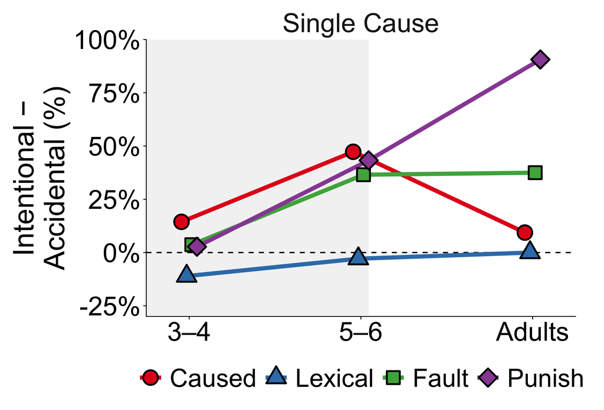

```r
single_onepanel_v4 = list(width = 14, height = 9.5,
                         line_width = 3.3, point_size = 10, point_stroke = 2.2)
plot_single_sensitivity_onepanel_v4 = function(step = 5L, with_ci = FALSE) {
  plot_single_sensitivity_onepanel(step, with_ci, mark_settings = single_onepanel_v4)
}
p.single.onepanel.v4 = save_presentation_v2_family(
  plot_single_sensitivity_onepanel_v4, "single_cause_intention_sensitivity_onepanel_talk_v4",
  "single_cause_intention_sensitivity_onepanel_v4",
  c("build00_blank", "build01_caused_childhood", "build02_add_lexical_childhood",
    "build03_add_fault_childhood", "build04_add_punish_childhood", "build05_add_adults_full"),
  width = single_onepanel_v4$width, height = single_onepanel_v4$height)
p.single.onepanel.v4$main
```

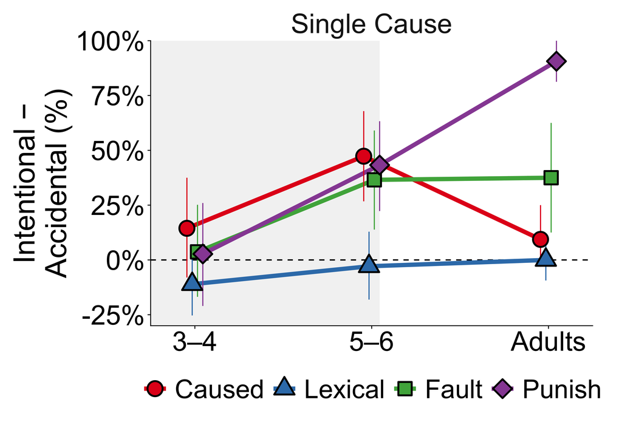

```r
p.single.onepanel.v4$backup
```

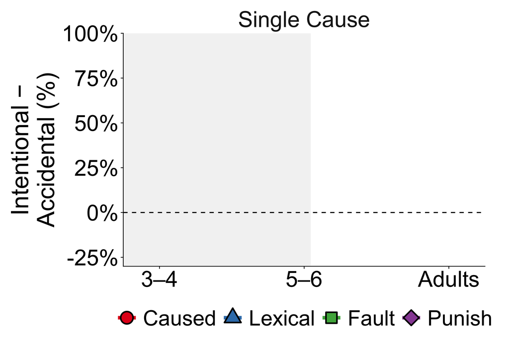

```r
p.single.onepanel.v4$builds[[1]]
```

```r
# Only linewidth, size and stroke may differ from the corresponding V3 layers.
# This also checks unchanged colors, shapes, values and alpha/reveal sequences.
for (step in 0:5) {
  for (with_ci in c(FALSE, TRUE)) {
    old = ggplot_build(plot_single_sensitivity_onepanel(step, with_ci))
    new = ggplot_build(plot_single_sensitivity_onepanel_v4(step, with_ci))
    stopifnot(identical(old$layout$layout, new$layout$layout),
              identical(old$layout$panel_params[[1]]$x.range, new$layout$panel_params[[1]]$x.range),
              identical(old$layout$panel_params[[1]]$y.range, new$layout$panel_params[[1]]$y.range),
              identical(old$layout$panel_params[[1]]$x$get_breaks(), new$layout$panel_params[[1]]$x$get_breaks()),
              identical(old$layout$panel_params[[1]]$y$get_breaks(), new$layout$panel_params[[1]]$y$get_breaks()))
    for (layer in seq_along(old$data)) {
      retained_columns = setdiff(names(old$data[[layer]]), c("linewidth", "size", "stroke"))
      stopifnot(identical(old$data[[layer]][retained_columns], new$data[[layer]][retained_columns]))
    }
  }
}
stopifnot(check_presentation_builds(p.single.onepanel.v4, c(0L, 2L, 4L, 6L, 8L, 12L)))
```

# Intention sensitivity across causal contexts

This additional companion to the all-measure role-preference figure uses **100 × (Intentional mean Yes − Accidental mean Yes)**. The four panels are Caused, Lexical, Fault and Punish; the three trajectories are Single Cause, Chain: Distal and Chain: Proximal. Study 1 is absent because it does not manipulate intention. A negative value means more Yes in Accidental.

Reuse the existing scenario-averaged participant means and stage groups. Conditions contain different people, so subtract group means rather than inventing within-participant intention contrasts. All 12 Single Cause effects and intervals are reused exactly. The 24 chain intervals apply the same 5,000-replicate procedure within stage: independently resample Intentional and Accidental participants, keeping both roles and all four measures together on each sampled row. A separate fixed seed leaves every earlier interval intact.

Chain: Proximal describes judgments of the proximal agent **when the distal agent’s intention changes**, not a manipulation of the proximal agent’s own intention. The source-study cohorts remain different; these are descriptive, cross-sectional comparisons rather than a test isolating causal context.

```r
df.chain.sensitivity.means = df.stage.means %>% filter(study == "Study 2")
chain_score_order = expand_grid(role = role_order, measure = measure_order) %>%
  transmute(score = paste(role, measure, sep = "__")) %>% pull(score)
df.chain.sensitivity.wide = df.chain.sensitivity.means %>%
  mutate(score = paste(role, measure, sep = "__")) %>%
  select(stage, condition, participant, score, yes_mean) %>%
  pivot_wider(names_from = score, values_from = yes_mean) %>% arrange(stage, condition, participant)
check_labels(df.chain.sensitivity.means$condition, condition_order, "chain sensitivity condition")
stopifnot(!anyDuplicated(df.chain.sensitivity.wide[c("stage", "condition", "participant")]))
RNGkind("Mersenne-Twister", "Inversion", "Rejection")
set.seed(bootstrap_seed + 12L)
chain_sensitivity_intervals = list()
for (stage_name in stage_order) {
  rows = filter(df.chain.sensitivity.wide, stage == stage_name)
  intentional = rows %>% filter(condition == "Intentional") %>% select(all_of(chain_score_order)) %>% as.matrix()
  accidental = rows %>% filter(condition == "Accidental") %>% select(all_of(chain_score_order)) %>% as.matrix()
  stopifnot(nrow(intentional) > 0L, nrow(accidental) > 0L)
  draws = replicate(bootstrap_replicates, {
    i = sample.int(nrow(intentional), replace = TRUE)
    a = sample.int(nrow(accidental), replace = TRUE)
    100 * (apply(intentional[i, , drop = FALSE], 2, mean_available) -
             apply(accidental[a, , drop = FALSE], 2, mean_available))
  })
  chain_sensitivity_intervals[[stage_name]] = tibble(stage = stage_name, score = chain_score_order,
    lower_pp = apply(draws, 1, quantile, probs = .025, na.rm = TRUE),
    upper_pp = apply(draws, 1, quantile, probs = .975, na.rm = TRUE))
}
df.chain.sensitivity.intervals = bind_rows(chain_sensitivity_intervals) %>%
  separate_wider_delim(score, delim = "__", names = c("role", "measure"))
df.chain.sensitivity.summary = df.chain.sensitivity.means %>%
  group_by(stage, condition, measure, role) %>%
  summarise(eligible_n = n(), n = sum(!is.na(yes_mean)), yes_mean = mean_available(yes_mean), .groups = "drop") %>%
  pivot_wider(names_from = condition, values_from = c(eligible_n, n, yes_mean)) %>%
  mutate(mean_pp = 100 * (yes_mean_Intentional - yes_mean_Accidental)) %>%
  left_join(df.chain.sensitivity.intervals, by = c("stage", "measure", "role"), relationship = "one-to-one") %>%
  mutate(study = "Study 2", context = paste0("Chain: ", role), contrast = "Intentional minus Accidental") %>%
  select(-role)
df.context.sensitivity.summary = bind_rows(
  df.single.sensitivity.summary %>% mutate(context = "Single Cause"), df.chain.sensitivity.summary) %>%
  mutate(stage = factor(stage, levels = stage_order), measure = factor(measure, levels = measure_order),
         context = factor(context, levels = stage_target_order)) %>%
  select(study, stage, context, contrast, measure, eligible_n_Intentional, eligible_n_Accidental,
         n_Intentional, n_Accidental, yes_mean_Intentional, yes_mean_Accidental, mean_pp, lower_pp, upper_pp) %>%
  arrange(stage, measure, context)
stopifnot(nrow(df.context.sensitivity.summary) == 36L,
          !anyNA(df.context.sensitivity.summary),
          !anyDuplicated(df.context.sensitivity.summary[c("stage", "measure", "context")]),
          all(dplyr::between(df.context.sensitivity.summary$mean_pp, -100, 100)),
          all(df.context.sensitivity.summary$lower_pp <= df.context.sensitivity.summary$upper_pp))
# Reused Single Cause values and intervals must remain exactly identical.
single_context_check = df.context.sensitivity.summary %>% filter(context == "Single Cause")
for (column in names(df.single.sensitivity.summary)) {
  old = df.single.sensitivity.summary[[column]]
  new = single_context_check[[column]]
  if (is.factor(old)) old = as.character(old)
  if (is.factor(new)) new = as.character(new)
  stopifnot(identical(unname(old), unname(new)))
}
# Independently link each contrast to the already validated role/context means.
df.context.sensitivity.expected = df.stage.summary %>%
  filter(study %in% c("Single Cause", "Study 2")) %>%
  mutate(context = if_else(study == "Single Cause", "Single Cause", paste0("Chain: ", role))) %>%
  select(study, stage, measure, context, condition, checked_mean = mean, checked_n = n) %>%
  pivot_wider(names_from = condition, values_from = c(checked_mean, checked_n))
df.context.sensitivity.checked = df.context.sensitivity.summary %>%
  left_join(df.context.sensitivity.expected, by = c("study", "stage", "measure", "context"),
            relationship = "one-to-one")
stopifnot(all(abs(df.context.sensitivity.checked$yes_mean_Intentional -
                   df.context.sensitivity.checked$checked_mean_Intentional) < 1e-12),
          all(abs(df.context.sensitivity.checked$yes_mean_Accidental -
                    df.context.sensitivity.checked$checked_mean_Accidental) < 1e-12),
          all(df.context.sensitivity.checked$n_Intentional == df.context.sensitivity.checked$checked_n_Intentional),
          all(df.context.sensitivity.checked$n_Accidental == df.context.sensitivity.checked$checked_n_Accidental),
          all(abs(df.context.sensitivity.checked$mean_pp - 100 *
                    (df.context.sensitivity.checked$checked_mean_Intentional -
                       df.context.sensitivity.checked$checked_mean_Accidental)) < 1e-10))
```

## Four-panel presentation figure and cumulative builds

The companion reuses the all-measure figure’s 22 × 8.5-inch presentation canvas, large text, outlined marks, childhood shading and strong dashed zero reference. Gray squares, red circles and blue triangles retain the existing causal-context palette. A single legend names the contexts explicitly; color encodes context rather than intention condition or judgment.

Main, CI backup and every build share one y scale derived from all means and intervals. Main/build versions omit CIs. Build 00 is the full blank scaffold; 01 adds Single Cause childhood, 02 adds Chain: Proximal childhood, 03 adds Chain: Distal childhood, and 04 adds all Adults. Earlier marks never move.

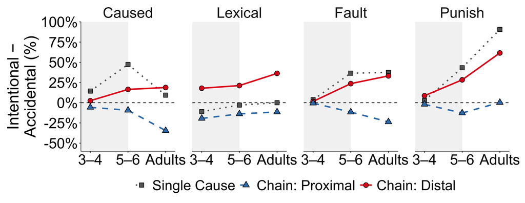

```r
# This family uses the same order for its legend and childhood reveals.
# Named color/shape/line mappings stay attached to their original contexts.
context_sensitivity_order = c("Single Cause", "Chain: Proximal", "Chain: Distal")
context_sensitivity_colors = setNames(unname(synthesis_colors), stage_target_order)
context_sensitivity_style = list(
  order = context_sensitivity_order, colors = context_sensitivity_colors, fills = context_sensitivity_colors,
  shapes = setNames(c(22, 21, 24), stage_target_order),
  lines = setNames(c("dotted", "solid", "dashed"), stage_target_order))
context_sensitivity_limits = c(
  floor(min(0, df.context.sensitivity.summary$mean_pp - 5,
            df.context.sensitivity.summary$lower_pp) / 10) * 10,
  ceiling(max(0, df.context.sensitivity.summary$mean_pp + 5,
              df.context.sensitivity.summary$upper_pp) / 10) * 10)
context_sensitivity_breaks = seq(ceiling(context_sensitivity_limits[1] / 25) * 25,
                                 floor(context_sensitivity_limits[2] / 25) * 25, 25)
df.context.sensitivity.plot = df.context.sensitivity.summary %>%
  transmute(panel = as.character(measure), series = as.character(context), stage,
            mean = mean_pp, lower = lower_pp, upper = upper_pp,
            reveal_step = if_else(stage == "Adults", 4L, match(context, context_sensitivity_order)))
plot_context_sensitivity = function(step = 4L, with_ci = FALSE) {
  plot_causal_verbs_talk(df.context.sensitivity.plot, measure_order, context_sensitivity_style,
                         context_sensitivity_limits, context_sensitivity_breaks,
                         "Intentional −
Accidental (%)", 0, step, with_ci)
}
p.context.sensitivity = save_presentation_v2_family(
  plot_context_sensitivity, "intention_sensitivity_across_contexts_talk_v1", "intention_sensitivity_across_contexts",
  c("build00_blank", "build01_single_cause_childhood", "build02_add_chain_proximal_childhood",
    "build03_add_chain_distal_childhood", "build04_add_adults_full"))
p.context.sensitivity$main
```

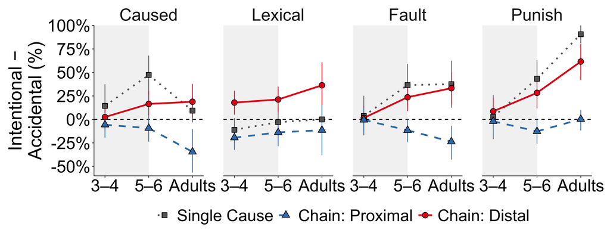

```r
p.context.sensitivity$backup
```

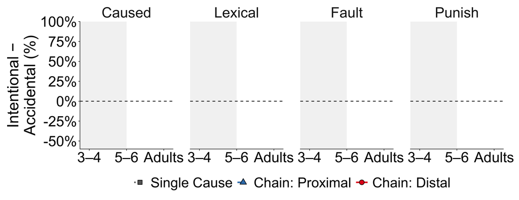

```r
p.context.sensitivity$builds[[1]]
```

```r
stopifnot(check_presentation_builds(p.context.sensitivity, c(0L, 8L, 16L, 24L, 36L)))
```

```r
write_csv(df.context.sensitivity.summary,
          file.path(presentation_v2_output, "intention_sensitivity_across_contexts_talk_v1_values.csv"))
kable(select(df.context.sensitivity.summary, stage, context, measure, n_Intentional, n_Accidental,
              mean_pp, lower_pp, upper_pp), digits = 4,
      caption = "Intention sensitivity by causal context: group-mean difference and participant-bootstrap 95% CI (pp)")
```

Intention sensitivity by causal context: group-mean difference and participant-bootstrap 95% CI (pp)

| stage | context | measure | n_Intentional | n_Accidental | mean_pp | lower_pp | upper_pp |
| --- | --- | --- | --- | --- | --- | --- | --- |
| 3–4 | Single Cause | Caused | 24 | 26 | 14.4231 | -8.0128 | 37.5000 |
| 3–4 | Chain: Distal | Caused | 60 | 67 | 2.5000 | -11.6294 | 16.0945 |
| 3–4 | Chain: Proximal | Caused | 60 | 67 | -5.6965 | -19.5162 | 7.9975 |
| 3–4 | Single Cause | Lexical | 24 | 26 | -11.0577 | -25.3205 | 1.2821 |
| 3–4 | Chain: Distal | Lexical | 60 | 67 | 17.9104 | 5.0112 | 30.4602 |
| 3–4 | Chain: Proximal | Lexical | 60 | 67 | -19.4030 | -32.4400 | -6.4552 |
| 3–4 | Single Cause | Fault | 24 | 26 | 3.6859 | -16.8309 | 25.1643 |
| 3–4 | Chain: Distal | Fault | 60 | 67 | 1.6169 | -11.9403 | 14.4279 |
| 3–4 | Chain: Proximal | Fault | 60 | 67 | -0.5224 | -14.2537 | 13.0348 |
| 3–4 | Single Cause | Punish | 24 | 26 | 2.7244 | -20.9936 | 25.9615 |
| 3–4 | Chain: Distal | Punish | 60 | 67 | 8.6443 | -5.6592 | 22.9478 |
| 3–4 | Chain: Proximal | Punish | 60 | 67 | -1.9652 | -15.8719 | 11.8159 |
| 5–6 | Single Cause | Caused | 26 | 20 | 47.3077 | 26.7308 | 67.8846 |
| 5–6 | Chain: Distal | Caused | 47 | 49 | 16.4785 | 2.5972 | 30.1780 |
| 5–6 | Chain: Proximal | Caused | 47 | 49 | -9.2922 | -23.7516 | 4.4518 |
| 5–6 | Single Cause | Lexical | 26 | 20 | -2.8846 | -18.0817 | 12.8846 |
| 5–6 | Chain: Distal | Lexical | 47 | 49 | 21.2115 | 7.6422 | 34.9121 |
| 5–6 | Chain: Proximal | Lexical | 47 | 49 | -13.8081 | -28.4422 | 0.1634 |
| 5–6 | Single Cause | Fault | 26 | 20 | 36.5385 | 13.8462 | 59.0385 |
| 5–6 | Chain: Distal | Fault | 47 | 49 | 23.6214 | 8.8135 | 38.0808 |
| 5–6 | Chain: Proximal | Fault | 47 | 49 | -11.5936 | -24.0556 | 0.1118 |
| 5–6 | Single Cause | Punish | 26 | 20 | 43.2692 | 22.3029 | 63.2692 |
| 5–6 | Chain: Distal | Punish | 47 | 49 | 28.2892 | 11.7021 | 43.8558 |
| 5–6 | Chain: Proximal | Punish | 47 | 49 | -12.7008 | -26.0964 | 0.6947 |
| Adults | Single Cause | Caused | 16 | 16 | 9.3750 | -3.1250 | 25.0000 |
| Adults | Chain: Distal | Caused | 20 | 21 | 18.8095 | 2.0238 | 37.7381 |
| Adults | Chain: Proximal | Caused | 20 | 21 | -34.5238 | -56.5476 | -10.3571 |
| Adults | Single Cause | Lexical | 16 | 16 | 0.0000 | -9.3750 | 9.3750 |
| Adults | Chain: Distal | Lexical | 20 | 21 | 36.3095 | 9.6429 | 60.5952 |
| Adults | Chain: Proximal | Lexical | 20 | 21 | -11.4286 | -38.0952 | 15.3571 |
| Adults | Single Cause | Fault | 16 | 16 | 37.5000 | 12.5000 | 62.5000 |
| Adults | Chain: Distal | Fault | 20 | 21 | 33.2143 | 16.0268 | 50.0000 |
| Adults | Chain: Proximal | Fault | 20 | 21 | -23.6905 | -42.7381 | -6.9048 |
| Adults | Single Cause | Punish | 16 | 16 | 90.6250 | 81.2500 | 100.0000 |
| Adults | Chain: Distal | Punish | 20 | 21 | 61.5476 | 41.9018 | 80.7143 |
| Adults | Chain: Proximal | Punish | 20 | 21 | 0.2381 | -11.7857 | 10.0000 |

The common y range is -60% to 100%. Lexical is close to zero in Single Cause, but this pattern does **not** hold uniformly across contexts: Chain: Distal Lexical is positive in all stages, while Chain: Proximal Lexical is negative. The plot preserves these departures rather than assuming intention has little effect on every lexical judgment. Pointwise CIs are descriptive and do not test the ranking of measures or contexts. Study 2’s missing main adult dataset and Single Cause’s unidentified historical adult exclusions remain unresolved.

# Study 1: causal-role differentiation and distal responsibility

This additional synthesis uses **Study 1 Baseline only**, with the same retained 211 children (ages 3–9) and 100 adults as the raw Yes plots. It asks whether the expected causal-role distinction accompanies distal fault and punishment preferences. It does not change participant selection, binary coding or any previous figure. These exploratory analyses use the uncapped descriptive snapshot; they are not a recovered or finalized preregistered analysis.

## Participant scores and age summaries

Average available scenarios within each participant × measure × role first, using the existing `df.study1.means` table. Then calculate:

- **Causal-role differentiation** = [(Caused Distal − Proximal) + (Lexical Proximal − Distal)] / 2.
- **Fault distal preference** = Fault Distal − Proximal.
- **Punish distal preference** = Punish Distal − Proximal.

The composite weights Caused and Lexical equally. A missing component makes that score missing; we never substitute zero or average only one half of the composite. Each responsibility relationship requires its outcome and the composite, without requiring the other responsibility outcome. In this snapshot all participants have two scenarios for every component, so no one is lost. Both-Yes and neither-Yes judgments both give a zero role contrast and remain included. Scores range from -100 to 100 percentage points; percentage tick labels denote these contrasts, not a new relative-attribution transformation.

```r
role_responsibility_output = "../../figures/study1_baseline_causal_chains/role_differentiation"
dir.create(role_responsibility_output, recursive = TRUE, showWarnings = FALSE)
role_responsibility_order = c("Causal-role differentiation", "Fault distal preference", "Punish distal preference")
role_responsibility_colors = c("Causal-role differentiation" = "#666666",
                               "Fault distal preference" = measure_colors[["Fault"]],
                               "Punish distal preference" = measure_colors[["Punish"]])
role_responsibility_shapes = setNames(c(21, 22, 23), role_responsibility_order)

stopifnot(all(df.study1.means$study == "Study 1"),
          all(df.study1.means$condition == "Baseline"),
          all(df.study1.means$scenarios_available == 2L))
df.study1.role.scores = df.study1.means %>%
  select(population, participant, age, measure, role, yes_mean) %>%
  pivot_wider(names_from = c(measure, role), values_from = yes_mean) %>%
  mutate(age_group = factor(if_else(population == "Adults", "Adult", as.character(age)),
                            levels = age_labels),
         differentiation = ((Caused_Distal - Caused_Proximal) +
                            (Lexical_Proximal - Lexical_Distal)) / 2,
         fault_preference = Fault_Distal - Fault_Proximal,
         punish_preference = Punish_Distal - Punish_Proximal) %>%
  arrange(age_group, participant)
stopifnot(nrow(df.study1.role.scores) == 311L,
          !anyDuplicated(df.study1.role.scores[c("population", "participant")]),
          !anyNA(select(df.study1.role.scores, differentiation, fault_preference, punish_preference)))
df.study1.role.long = df.study1.role.scores %>%
  select(population, participant, age_group, differentiation, fault_preference, punish_preference) %>%
  pivot_longer(c(differentiation, fault_preference, punish_preference),
               names_to = "score_key", values_to = "score") %>%
  mutate(series = factor(role_responsibility_order[
    match(score_key, c("differentiation", "fault_preference", "punish_preference"))],
    levels = role_responsibility_order))
set.seed(bootstrap_seed + 20L)
df.study1.role.development = df.study1.role.long %>%
  arrange(age_group, series, participant) %>% group_by(population, age_group, series) %>%
  summarise(summary = list(bootstrap_mean(score)), .groups = "drop") %>%
  unnest_wider(summary) %>%
  mutate(x = if_else(age_group == "Adult", comparison_adult_position,
                     as.numeric(as.character(replace(age_group, age_group == "Adult", NA)))),
         mean_pp = 100 * mean, lower_pp = 100 * lower, upper_pp = 100 * upper) %>%
  arrange(age_group, series)
stopifnot(nrow(df.study1.role.development) == 24L,
          all(dplyr::between(df.study1.role.long$score, -1, 1)))
write_csv(select(df.study1.role.development, population, age_group, series, n, mean_pp, lower_pp, upper_pp),
          file.path(role_responsibility_output, "study1_role_differentiation_development_values.csv"))
kable(select(df.study1.role.development, age_group, series, n, mean_pp, lower_pp, upper_pp),
      digits = 3, caption = "Study 1: participant-weighted means and 95% bootstrap intervals (percentage points)")
```

Study 1: participant-weighted means and 95% bootstrap intervals (percentage points)

| age_group | series | n | mean_pp | lower_pp | upper_pp |
| --- | --- | --- | --- | --- | --- |
| 3 | Causal-role differentiation | 31 | 12.903 | 1.613 | 25.000 |
| 3 | Fault distal preference | 31 | 1.613 | -16.129 | 19.355 |
| 3 | Punish distal preference | 31 | 4.839 | -11.290 | 19.355 |
| 4 | Causal-role differentiation | 32 | 14.844 | 2.344 | 28.125 |
| 4 | Fault distal preference | 32 | 23.438 | 4.688 | 42.188 |
| 4 | Punish distal preference | 32 | -4.688 | -23.438 | 14.062 |
| 5 | Causal-role differentiation | 29 | 27.586 | 13.793 | 42.241 |
| 5 | Fault distal preference | 29 | 18.966 | -1.724 | 39.655 |
| 5 | Punish distal preference | 29 | 10.345 | -6.897 | 27.586 |
| 6 | Causal-role differentiation | 30 | 55.833 | 39.167 | 71.667 |
| 6 | Fault distal preference | 30 | 30.000 | 8.333 | 51.667 |
| 6 | Punish distal preference | 30 | 31.667 | 11.667 | 50.000 |
| 7 | Causal-role differentiation | 30 | 54.167 | 41.667 | 66.667 |
| 7 | Fault distal preference | 30 | 71.667 | 55.000 | 86.667 |
| 7 | Punish distal preference | 30 | 60.000 | 45.000 | 75.000 |
| 8 | Causal-role differentiation | 30 | 55.833 | 40.833 | 70.000 |
| 8 | Fault distal preference | 30 | 71.667 | 58.333 | 85.000 |
| 8 | Punish distal preference | 30 | 68.333 | 55.000 | 81.667 |
| 9 | Causal-role differentiation | 29 | 62.069 | 49.138 | 75.000 |
| 9 | Fault distal preference | 29 | 58.621 | 36.207 | 79.310 |
| 9 | Punish distal preference | 29 | 46.552 | 22.414 | 68.966 |
| Adult | Causal-role differentiation | 100 | 33.500 | 27.250 | 40.000 |
| Adult | Fault distal preference | 100 | 71.500 | 62.500 | 79.500 |
| Adult | Punish distal preference | 100 | 66.000 | 58.000 | 73.012 |

The main plot has three child trajectories and separate Adult reference points. Adult is a category, not age 10 or an additional within-child measurement. Childhood shading, large outlined markers, thick solid lines and measure colors follow the existing talk style. Light intervals are 5,000-draw participant bootstrap 95% CIs, calculated separately for each age and score. They describe uncertainty in each mean, not tests of differences between trajectories.

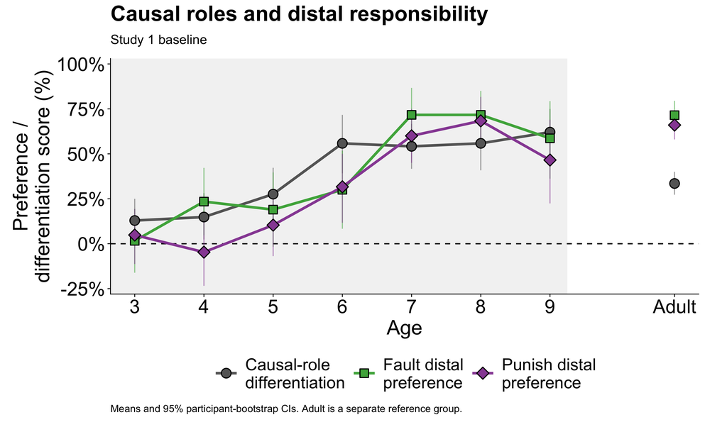

```r
role_responsibility_limits = c(
  min(-25, floor(min(df.study1.role.development$lower_pp) / 25) * 25),
  max(25, ceiling(max(df.study1.role.development$upper_pp) / 25) * 25))
role_responsibility_labels = setNames(
  c("Causal-role\ndifferentiation", "Fault distal\npreference", "Punish distal\npreference"),
  role_responsibility_order)
role_responsibility_theme = theme_causal_verbs_talk() +
  theme(axis.text = element_text(size = 32), axis.title = element_text(size = 34),
        strip.text = element_text(size = 34), legend.text = element_text(size = 28),
        plot.title = element_text(size = 36, face = "bold", margin = margin(b = 16)),
        plot.subtitle = element_text(size = 22, margin = margin(b = 20)),
        plot.caption = element_text(size = 17, hjust = 0, margin = margin(t = 15)))
p.study1.role.development = ggplot(df.study1.role.development,
                                  aes(x = x, y = mean_pp, group = series)) +
  annotate("rect", xmin = -Inf, xmax = 9.25, ymin = -Inf, ymax = Inf,
           fill = talk_v2$childhood_fill, color = NA) +
  geom_hline(yintercept = 0, linewidth = talk_v2$reference_width, linetype = "dashed") +
  geom_linerange(aes(ymin = lower_pp, ymax = upper_pp, color = series),
                linewidth = .85, alpha = .55, show.legend = FALSE) +
  geom_line(data = filter(df.study1.role.development, population == "Children"),
            aes(color = series), linewidth = talk_v2$line_width) +
  geom_point(aes(fill = series, shape = series), color = "black", size = 6.8, stroke = 1.25) +
  scale_color_manual(NULL, values = role_responsibility_colors, labels = role_responsibility_labels) +
  scale_fill_manual(NULL, values = role_responsibility_colors, labels = role_responsibility_labels) +
  scale_shape_manual(NULL, values = role_responsibility_shapes, labels = role_responsibility_labels) +
  scale_x_continuous(breaks = c(child_ages, comparison_adult_position), labels = age_labels,
                     expand = expansion(add = .35)) +
  scale_y_continuous(limits = role_responsibility_limits,
                     breaks = seq(role_responsibility_limits[1], role_responsibility_limits[2], 25),
                     labels = function(x) paste0(x, "%"), expand = expansion(add = 3)) +
  labs(x = "Age", y = "Preference /\ndifferentiation score (%)",
       title = "Causal roles and distal responsibility", subtitle = "Study 1 baseline",
       caption = "Means and 95% participant-bootstrap CIs. Adult is a separate reference group.") +
  role_responsibility_theme
save_presentation_v2(p.study1.role.development,
                    file.path(role_responsibility_output, "study1_role_differentiation_development_talk_v1"),
                    width = 17, height = 10)
p.study1.role.development
```

## Direct relationships and adjustment for age

The backup shows all participants, with separate Fault and Punish panels. Each plotted point is one participant; small, fixed-seed jitter (at most 3 percentage points on either axis) reveals coincident discrete scores. Only the rendered points are jittered: fits, exported values and all analyses use exact scores. Circles identify children and triangles identify adults. The colored line is the pooled, unadjusted ordinary least-squares fit within each panel. It does not imply an age-adjusted or causal effect.

We separately fit `responsibility ~ differentiation` and `responsibility ~ differentiation + age_group`. The **children-only** models address the childhood question; the combined models show whether the association also holds with the Adult reference group included. Age is categorical (3–9, plus Adult in the combined model), allowing each group its own intercept without inventing a chronological adult age or imposing linear age effects. The adjusted slope is a common within-age association, not a test of age-varying slopes.

Slope CIs resample whole participants **within age group**, retaining age-group sample sizes, 5,000 times. The table expresses the outcome difference in percentage points for a **25-point increase in causal-role differentiation**. Intervals are exploratory, unadjusted for multiple comparisons and conditional on participant independence; household dependence is not modeled. Temporal or causal claims cannot follow from this cross-sectional association.

```r
df.study1.role.relationship = df.study1.role.scores %>%
  select(population, participant, age_group, differentiation, fault_preference, punish_preference) %>%
  pivot_longer(c(fault_preference, punish_preference), names_to = "outcome_key",
               values_to = "responsibility") %>%
  mutate(measure = factor(if_else(outcome_key == "fault_preference", "Fault", "Punish"),
                         levels = c("Fault", "Punish")),
         differentiation_pp = 100 * differentiation, responsibility_pp = 100 * responsibility) %>%
  filter(!is.na(differentiation), !is.na(responsibility))

# With age-group intercepts, the slope is the regression of age-centered scores.
# This also makes participant bootstrapping easy to read without refitting many lm objects.
role_relationship_slope = function(data, adjusted) {
  x = data$differentiation
  y = data$responsibility
  if (adjusted) {
    x = x - ave(x, data$age_group, FUN = mean)
    y = y - ave(y, data$age_group, FUN = mean)
  } else {
    x = x - mean(x)
    y = y - mean(y)
  }
  if (sum(x^2) == 0) return(NA_real_)
  sum(x * y) / sum(x^2)
}

set.seed(bootstrap_seed + 21L)
role_relationship_results = list()
for (sample_name in c("Children", "Children and adults")) {
  for (outcome in c("Fault", "Punish")) {
    data = df.study1.role.relationship %>% filter(measure == outcome) %>%
      filter(sample_name == "Children and adults" | population == "Children") %>%
      arrange(age_group, participant) %>% mutate(age_group = droplevels(age_group))
    age_rows = split(seq_len(nrow(data)), data$age_group)
    fits = list(Unadjusted = lm(responsibility ~ differentiation, data = data),
                `Age-group adjusted` = lm(responsibility ~ differentiation + age_group, data = data))
    # One draw keeps the participant's predictor and outcome together.
    draws = replicate(bootstrap_replicates, {
      rows = unlist(lapply(age_rows, function(index) sample(index, length(index), replace = TRUE)),
                    use.names = FALSE)
      sampled = data[rows, ]
      c(role_relationship_slope(sampled, FALSE), role_relationship_slope(sampled, TRUE))
    })
    stopifnot(!anyNA(draws))
    for (j in seq_along(fits)) {
      slope = unname(coef(fits[[j]])[["differentiation"]])
      stopifnot(abs(slope - role_relationship_slope(data, j == 2L)) < 1e-10)
      interval = unname(quantile(draws[j, ], c(.025, .975)))
      role_relationship_results[[length(role_relationship_results) + 1L]] = tibble(
        sample = sample_name, measure = outcome, model = names(fits)[j], n = nrow(data),
        age_groups = nlevels(data$age_group), slope = slope,
        slope_lower = interval[1], slope_upper = interval[2],
        effect_per_25pp = 25 * slope, lower_per_25pp = 25 * interval[1], upper_per_25pp = 25 * interval[2],
        bootstrap_replicates = bootstrap_replicates)
    }
  }
}
df.study1.role.models = bind_rows(role_relationship_results)
write_csv(df.study1.role.models, file.path(role_responsibility_output, "study1_role_differentiation_relationship_models.csv"))
# Exact joint score frequencies reproduce the scatter and models without exporting participant IDs.
df.study1.role.joint = df.study1.role.relationship %>%
  count(population, age_group, measure, differentiation_pp, responsibility_pp, name = "participants")
write_csv(df.study1.role.joint, file.path(role_responsibility_output, "study1_role_differentiation_relationship_values.csv"))
kable(select(df.study1.role.models, sample, measure, model, n, effect_per_25pp, lower_per_25pp, upper_per_25pp),
      digits = 3, caption = "Outcome difference (pp) per 25-point differentiation increase; age-stratified participant-bootstrap 95% CI")
```

Outcome difference (pp) per 25-point differentiation increase; age-stratified participant-bootstrap 95% CI

| sample | measure | model | n | effect_per_25pp | lower_per_25pp | upper_per_25pp |
| --- | --- | --- | --- | --- | --- | --- |
| Children | Fault | Unadjusted | 211 | 17.237 | 13.902 | 20.728 |
| Children | Fault | Age-group adjusted | 211 | 14.671 | 10.678 | 19.053 |
| Children | Punish | Unadjusted | 211 | 13.472 | 9.532 | 17.347 |
| Children | Punish | Age-group adjusted | 211 | 9.125 | 4.727 | 13.624 |
| Children and adults | Fault | Unadjusted | 311 | 14.174 | 10.968 | 17.248 |
| Children and adults | Fault | Age-group adjusted | 311 | 12.600 | 8.971 | 16.041 |
| Children and adults | Punish | Unadjusted | 311 | 10.550 | 6.966 | 13.988 |
| Children and adults | Punish | Age-group adjusted | 311 | 7.719 | 4.087 | 11.273 |

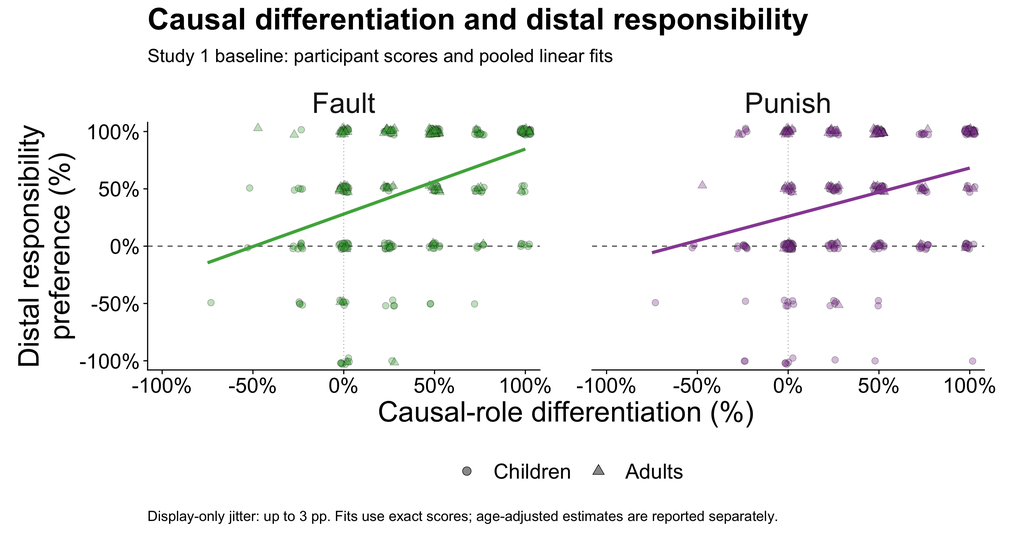

```r
p.study1.role.relationship = ggplot(df.study1.role.relationship,
                                   aes(x = differentiation_pp, y = responsibility_pp)) +
  geom_hline(yintercept = 0, linewidth = .7, linetype = "dashed", color = "#666666") +
  geom_vline(xintercept = 0, linewidth = .5, linetype = "dotted", color = "#AAAAAA") +
  geom_point(aes(fill = measure, shape = population), color = "black", stroke = .45,
             size = 3.4, alpha = .35,
             position = position_jitter(width = 3, height = 3, seed = bootstrap_seed + 22L)) +
  geom_smooth(aes(color = measure), method = "lm", formula = y ~ x, se = FALSE,
              linewidth = 1.8, show.legend = FALSE) +
  facet_wrap(~ measure, nrow = 1) +
  scale_color_manual(values = measure_colors[c("Fault", "Punish")], guide = "none") +
  scale_fill_manual(values = measure_colors[c("Fault", "Punish")], guide = "none") +
  scale_shape_manual(NULL, values = c(Children = 21, Adults = 24), breaks = c("Children", "Adults")) +
  guides(shape = guide_legend(override.aes = list(fill = "#999999", alpha = 1, size = 4.5))) +
  scale_x_continuous(breaks = seq(-100, 100, 50), labels = function(x) paste0(x, "%")) +
  scale_y_continuous(breaks = seq(-100, 100, 50), labels = function(x) paste0(x, "%")) +
  coord_cartesian(xlim = c(-108, 108), ylim = c(-108, 108), expand = FALSE) +
  labs(x = "Causal-role differentiation (%)", y = "Distal responsibility\npreference (%)",
       title = "Causal differentiation and distal responsibility",
       subtitle = "Study 1 baseline: participant scores and pooled linear fits",
       caption = "Display-only jitter: up to 3 pp. Fits use exact scores; age-adjusted estimates are reported separately.") +
  role_responsibility_theme + theme(axis.text = element_text(size = 25), legend.text = element_text(size = 25),
                                  panel.spacing = grid::unit(2.2, "cm"))
save_presentation_v2(p.study1.role.relationship,
                    file.path(role_responsibility_output, "study1_role_differentiation_relationship_backup_v1"),
                    width = 17, height = 9)
p.study1.role.relationship
```

## Independent scoring and output checks

Recalculate scores directly from the binary responses using signed role weights, without the participant-mean table or the wide-score formulas above. Complete paired scenarios make the independent trial-based calculation equivalent. Verify all participant scores, displayed means, participant counts and model slopes.

```r
df.study1.role.direct = bind_rows(df.study1.adults.responses, df.study1.children.responses) %>%
  mutate(signed_yes = endorsed * if_else((measure == "Lexical" & role == "Proximal") |
                                        (measure != "Lexical" & role == "Distal"), 1, -1),
         score_key = case_when(measure %in% c("Caused", "Lexical") ~ "differentiation",
                               measure == "Fault" ~ "fault_preference", TRUE ~ "punish_preference")) %>%
  group_by(population, participant, score_key) %>%
  summarise(checked_score = 2 * mean(signed_yes), .groups = "drop") %>%
  left_join(select(df.study1.role.long, population, participant, score_key, score),
            by = c("population", "participant", "score_key"), relationship = "one-to-one")
stopifnot(nrow(df.study1.role.direct) == 933L,
          all(abs(df.study1.role.direct$checked_score - df.study1.role.direct$score) < 1e-12),
          sum(df.study1.role.joint$participants) == 622L,
          nrow(ggplot_build(p.study1.role.development)$data[[5]]) == 24L,
          nrow(ggplot_build(p.study1.role.relationship)$data[[3]]) == 622L)
# The composite group mean must equal the equally weighted Caused and reversed Lexical gaps.
df.study1.role.mean.check = df.study1.summary %>%
  select(age_group, measure, role, mean) %>%
  pivot_wider(names_from = c(measure, role), values_from = mean) %>%
  mutate(expected = 100 * ((Caused_Distal - Caused_Proximal) +
                          (Lexical_Proximal - Lexical_Distal)) / 2) %>%
  left_join(filter(df.study1.role.development, series == "Causal-role differentiation") %>%
              select(age_group, mean_pp), by = "age_group", relationship = "one-to-one")
stopifnot(nrow(df.study1.role.mean.check) == 8L,
          all(abs(df.study1.role.mean.check$expected - df.study1.role.mean.check$mean_pp) < 1e-10))
```

The participant-level association is positive for both outcomes, including after age-group adjustment. For children, each 25-point increase in differentiation corresponds to 14.7 points more distal Fault preference (95% CI 10.7 to 19.1) and 9.1 points more distal Punish preference (95% CI 4.7 to 13.6). The combined-sample age-adjusted intervals also exclude zero. These results support an association beyond age-group differences; they do not establish developmental causation.

The three childhood trajectories broadly rise but do not move in lockstep: Fault and Punish dip at age 9, and Adult causal-role differentiation is lower than that of children aged 6–9 while adult distal responsibility remains high. Thus the adult endpoint does not follow a simple parallel-increase account.

# Matched causal-role differentiation: Baseline, Accidental, Intentional

This new figure applies the Study 1 participant-level score definitions to the corresponding Study 2 conditions, in the display order **Baseline | Accidental | Intentional**. The Baseline panel reuses the exact means and 95% bootstrap CIs from the earlier Study 1 synthesis. No old plot or analysis is replaced.

Within each participant, scenario-averaged Yes means supply `((Caused Distal - Proximal) + (Lexical Proximal - Distal)) / 2`, `Fault Distal - Proximal`, and `Punish Distal - Proximal`. Both/neither responses remain included. A missing component would make its corresponding score missing; this snapshot has both scenarios for every component. Study 2 adds 406 children and the same 41-person adult pilot (21 Accidental, 20 Intentional) already used elsewhere. The missing main adult dataset is not substituted or implied to be recovered. These remain the uncapped descriptive snapshots.

## Matched participant scores and intervals

```r
matched_role_output = "../../figures/study_comparison/role_differentiation"
dir.create(matched_role_output, recursive = TRUE, showWarnings = FALSE)
matched_role_panel_order = c("Baseline", "Accidental", "Intentional")
stopifnot(all(df.study2.means$study == "Study 2"),
          all(df.study2.means$condition %in% condition_order),
          all(df.study2.means$scenarios_available == 2L))
df.study2.role.scores = df.study2.means %>%
  select(population, participant, age, condition, measure, role, yes_mean) %>%
  pivot_wider(names_from = c(measure, role), values_from = yes_mean) %>%
  mutate(age_group = factor(if_else(population == "Adults", "Adult", as.character(age)),
                            levels = age_labels),
         differentiation = ((Caused_Distal - Caused_Proximal) +
                            (Lexical_Proximal - Lexical_Distal)) / 2,
         fault_preference = Fault_Distal - Fault_Proximal,
         punish_preference = Punish_Distal - Punish_Proximal) %>%
  arrange(condition, age_group, participant)
stopifnot(nrow(df.study2.role.scores) == 447L,
          !anyDuplicated(df.study2.role.scores[c("population", "participant")]),
          !anyNA(select(df.study2.role.scores, differentiation, fault_preference, punish_preference)))
df.study2.role.long = df.study2.role.scores %>%
  select(population, participant, age_group, condition, differentiation, fault_preference, punish_preference) %>%
  pivot_longer(c(differentiation, fault_preference, punish_preference),
               names_to = "score_key", values_to = "score") %>%
  mutate(series = factor(role_responsibility_order[
    match(score_key, c("differentiation", "fault_preference", "punish_preference"))],
    levels = role_responsibility_order))
set.seed(bootstrap_seed + 23L)
df.study2.role.development = df.study2.role.long %>%
  arrange(condition, age_group, series, participant) %>%
  group_by(condition, population, age_group, series) %>%
  summarise(summary = list(bootstrap_mean(score)), .groups = "drop") %>%
  unnest_wider(summary) %>%
  mutate(x = if_else(age_group == "Adult", comparison_adult_position,
                     as.numeric(as.character(replace(age_group, age_group == "Adult", NA)))),
         mean_pp = 100 * mean, lower_pp = 100 * lower, upper_pp = 100 * upper)
df.matched.role.summary = bind_rows(
  mutate(df.study1.role.development, study = "Study 1", condition = "Baseline"),
  mutate(df.study2.role.development, study = "Study 2")) %>%
  mutate(panel = factor(condition, levels = matched_role_panel_order)) %>%
  arrange(panel, age_group, series)
stopifnot(nrow(df.matched.role.summary) == 72L,
          !anyDuplicated(df.matched.role.summary[c("panel", "age_group", "series")]),
          all(dplyr::between(df.study2.role.long$score, -1, 1)))
write_csv(select(df.matched.role.summary, study, condition, population, age_group, series,
                 n, mean_pp, lower_pp, upper_pp),
          file.path(matched_role_output, "matched_role_differentiation_development_talk_v1_values.csv"))
kable(select(df.matched.role.summary, condition, age_group, series, n, mean_pp, lower_pp, upper_pp),
      digits = 3, caption = "Matched panels: participant means and pointwise 95% bootstrap CIs (percentage points)")
```

Matched panels: participant means and pointwise 95% bootstrap CIs (percentage points)

| condition | age_group | series | n | mean_pp | lower_pp | upper_pp |
| --- | --- | --- | --- | --- | --- | --- |
| Baseline | 3 | Causal-role differentiation | 31 | 12.903 | 1.613 | 25.000 |
| Baseline | 3 | Fault distal preference | 31 | 1.613 | -16.129 | 19.355 |
| Baseline | 3 | Punish distal preference | 31 | 4.839 | -11.290 | 19.355 |
| Baseline | 4 | Causal-role differentiation | 32 | 14.844 | 2.344 | 28.125 |
| Baseline | 4 | Fault distal preference | 32 | 23.438 | 4.688 | 42.188 |
| Baseline | 4 | Punish distal preference | 32 | -4.688 | -23.438 | 14.062 |
| Baseline | 5 | Causal-role differentiation | 29 | 27.586 | 13.793 | 42.241 |
| Baseline | 5 | Fault distal preference | 29 | 18.966 | -1.724 | 39.655 |
| Baseline | 5 | Punish distal preference | 29 | 10.345 | -6.897 | 27.586 |
| Baseline | 6 | Causal-role differentiation | 30 | 55.833 | 39.167 | 71.667 |
| Baseline | 6 | Fault distal preference | 30 | 30.000 | 8.333 | 51.667 |
| Baseline | 6 | Punish distal preference | 30 | 31.667 | 11.667 | 50.000 |
| Baseline | 7 | Causal-role differentiation | 30 | 54.167 | 41.667 | 66.667 |
| Baseline | 7 | Fault distal preference | 30 | 71.667 | 55.000 | 86.667 |
| Baseline | 7 | Punish distal preference | 30 | 60.000 | 45.000 | 75.000 |
| Baseline | 8 | Causal-role differentiation | 30 | 55.833 | 40.833 | 70.000 |
| Baseline | 8 | Fault distal preference | 30 | 71.667 | 58.333 | 85.000 |
| Baseline | 8 | Punish distal preference | 30 | 68.333 | 55.000 | 81.667 |
| Baseline | 9 | Causal-role differentiation | 29 | 62.069 | 49.138 | 75.000 |
| Baseline | 9 | Fault distal preference | 29 | 58.621 | 36.207 | 79.310 |
| Baseline | 9 | Punish distal preference | 29 | 46.552 | 22.414 | 68.966 |
| Baseline | Adult | Causal-role differentiation | 100 | 33.500 | 27.250 | 40.000 |
| Baseline | Adult | Fault distal preference | 100 | 71.500 | 62.500 | 79.500 |
| Baseline | Adult | Punish distal preference | 100 | 66.000 | 58.000 | 73.012 |
| Accidental | 3 | Causal-role differentiation | 32 | 14.844 | 3.906 | 27.344 |
| Accidental | 3 | Fault distal preference | 32 | 1.562 | -18.750 | 21.875 |
| Accidental | 3 | Punish distal preference | 32 | 0.000 | -20.312 | 18.750 |
| Accidental | 4 | Causal-role differentiation | 35 | 27.857 | 17.857 | 37.857 |
| Accidental | 4 | Fault distal preference | 35 | 20.000 | -1.429 | 40.000 |
| Accidental | 4 | Punish distal preference | 35 | 10.000 | -10.000 | 28.571 |
| Accidental | 5 | Causal-role differentiation | 25 | 28.000 | 14.000 | 43.000 |
| Accidental | 5 | Fault distal preference | 25 | 6.000 | -20.000 | 32.000 |
| Accidental | 5 | Punish distal preference | 25 | -8.000 | -30.000 | 14.000 |
| Accidental | 6 | Causal-role differentiation | 24 | 55.208 | 38.542 | 71.875 |
| Accidental | 6 | Fault distal preference | 24 | 50.000 | 25.000 | 72.917 |
| Accidental | 6 | Punish distal preference | 24 | 35.417 | 12.500 | 58.333 |
| Accidental | 7 | Causal-role differentiation | 30 | 53.333 | 40.833 | 66.667 |
| Accidental | 7 | Fault distal preference | 30 | 50.000 | 33.292 | 66.667 |
| Accidental | 7 | Punish distal preference | 30 | 25.000 | 5.000 | 43.333 |
| Accidental | 8 | Causal-role differentiation | 23 | 47.826 | 29.348 | 64.130 |
| Accidental | 8 | Fault distal preference | 23 | 45.652 | 28.261 | 63.043 |
| Accidental | 8 | Punish distal preference | 23 | 32.609 | 15.217 | 50.000 |
| Accidental | 9 | Causal-role differentiation | 31 | 53.226 | 41.935 | 63.710 |
| Accidental | 9 | Fault distal preference | 31 | 50.000 | 37.097 | 64.516 |
| Accidental | 9 | Punish distal preference | 31 | 19.355 | 4.839 | 35.484 |
| Accidental | Adult | Causal-role differentiation | 21 | 30.952 | 15.476 | 45.238 |
| Accidental | Adult | Fault distal preference | 21 | 38.095 | 14.286 | 61.905 |
| Accidental | Adult | Punish distal preference | 21 | 26.190 | 4.762 | 47.619 |
| Intentional | 3 | Causal-role differentiation | 37 | 6.757 | -4.730 | 18.243 |
| Intentional | 3 | Fault distal preference | 37 | 12.162 | -5.405 | 29.730 |
| Intentional | 3 | Punish distal preference | 37 | 24.324 | 4.054 | 44.595 |
| Intentional | 4 | Causal-role differentiation | 23 | 7.609 | -3.261 | 18.478 |
| Intentional | 4 | Fault distal preference | 23 | 15.217 | -10.870 | 41.304 |
| Intentional | 4 | Punish distal preference | 23 | 2.174 | -21.739 | 26.087 |
| Intentional | 5 | Causal-role differentiation | 19 | 26.316 | 0.000 | 50.000 |
| Intentional | 5 | Fault distal preference | 19 | 65.789 | 47.368 | 81.579 |
| Intentional | 5 | Punish distal preference | 19 | 68.421 | 44.737 | 86.842 |
| Intentional | 6 | Causal-role differentiation | 28 | 43.750 | 29.464 | 58.036 |
| Intentional | 6 | Fault distal preference | 28 | 60.714 | 42.857 | 76.786 |
| Intentional | 6 | Punish distal preference | 28 | 44.643 | 23.214 | 66.071 |
| Intentional | 7 | Causal-role differentiation | 29 | 56.034 | 37.069 | 73.276 |
| Intentional | 7 | Fault distal preference | 29 | 79.310 | 65.517 | 91.379 |
| Intentional | 7 | Punish distal preference | 29 | 81.034 | 68.966 | 91.379 |
| Intentional | 8 | Causal-role differentiation | 28 | 44.643 | 29.464 | 58.951 |
| Intentional | 8 | Fault distal preference | 28 | 71.429 | 57.143 | 85.714 |
| Intentional | 8 | Punish distal preference | 28 | 80.357 | 66.071 | 92.857 |
| Intentional | 9 | Causal-role differentiation | 42 | 43.452 | 30.357 | 56.548 |
| Intentional | 9 | Fault distal preference | 42 | 72.619 | 57.143 | 84.524 |
| Intentional | 9 | Punish distal preference | 42 | 77.381 | 63.095 | 90.476 |
| Intentional | Adult | Causal-role differentiation | 20 | 33.750 | 17.500 | 52.500 |
| Intentional | Adult | Fault distal preference | 20 | 95.000 | 87.500 | 100.000 |
| Intentional | Adult | Punish distal preference | 20 | 87.500 | 75.000 | 97.500 |

CIs use 5,000 participant resamples per age/condition/score. The Baseline seed and intervals remain unchanged; Study 2 uses a separate fixed seed (`bootstrap_seed + 23`). These are descriptive between-sample comparisons, not within-person condition changes or formal tests between trajectories.

## One fixed scaffold for both new build series

Every matched panel uses the same age positions, y limits, tick marks, childhood shading, zero line, fonts, colors, shapes and line widths. The common y range is derived from **all** means and CI endpoints in all three conditions; no interval is clipped. The new standalone Study 1 version uses the same scale and style. Only the canvas width differs between the three-panel and single-panel figures. Both omit plot title, subtitle and footer text; Baseline, Accidental and Intentional remain as the required panel labels.

Builds keep all data rows and the full scaffold in place, changing only their visibility. Adults remain separate reference points and appear only in Build 04. Child lines never extend to the Adult category. CIs appear with their points.

```r
matched_role_limits = c(
  min(-25, floor(min(df.matched.role.summary$lower_pp) / 25) * 25),
  max(25, ceiling(max(df.matched.role.summary$upper_pp) / 25) * 25))
matched_role_breaks = seq(matched_role_limits[1], matched_role_limits[2], 25)
df.matched.role.plot = df.matched.role.summary %>%
  mutate(reveal_step = if_else(population == "Adults", 4L, as.integer(panel)))
df.study1.role.v2.plot = df.matched.role.summary %>% filter(condition == "Baseline") %>%
  mutate(reveal_step = if_else(population == "Adults", 4L, as.integer(series)))

plot_matched_roles = function(values, panel_order, step) {
  points = values %>%
    mutate(panel = factor(as.character(panel), levels = panel_order),
           visible = as.numeric(reveal_step <= step))
  segments = points %>% filter(population == "Children") %>%
    arrange(panel, series, x) %>% group_by(panel, series) %>%
    mutate(end_x = lead(x), end_y = lead(mean_pp), end_step = lead(reveal_step)) %>%
    ungroup() %>% filter(!is.na(end_x)) %>%
    mutate(visible = as.numeric(pmax(reveal_step, end_step) <= step))
  p = ggplot(points, aes(x = x, y = mean_pp, group = series)) +
    annotate("rect", xmin = -Inf, xmax = 9.25, ymin = -Inf, ymax = Inf,
             fill = talk_v2$childhood_fill, color = NA) +
    geom_hline(yintercept = 0, linewidth = talk_v2$reference_width, linetype = "dashed") +
    geom_linerange(aes(ymin = lower_pp, ymax = upper_pp, color = series, alpha = .55 * visible),
                  linewidth = .85, show.legend = FALSE) +
    geom_segment(data = segments, aes(xend = end_x, yend = end_y, color = series, alpha = visible),
                 linewidth = talk_v2$line_width, show.legend = TRUE) +
    geom_point(aes(fill = series, shape = series, alpha = visible), color = "black", size = 6.8,
               stroke = 1.25, show.legend = TRUE) +
    scale_alpha_identity(guide = "none") +
    scale_color_manual(NULL, values = role_responsibility_colors, limits = role_responsibility_order,
                       labels = role_responsibility_labels, drop = FALSE) +
    scale_fill_manual(NULL, values = role_responsibility_colors, limits = role_responsibility_order,
                      labels = role_responsibility_labels, drop = FALSE) +
    scale_shape_manual(NULL, values = role_responsibility_shapes, limits = role_responsibility_order,
                       labels = role_responsibility_labels, drop = FALSE) +
    scale_x_continuous(breaks = c(child_ages, comparison_adult_position), labels = age_labels,
                       limits = c(3, comparison_adult_position), expand = expansion(add = .35)) +
    scale_y_continuous(limits = matched_role_limits, breaks = matched_role_breaks,
                       labels = function(x) paste0(x, "%"), expand = expansion(add = 3)) +
    labs(x = "Age", y = "Preference /\ndifferentiation score (%)",
         title = NULL, subtitle = NULL, caption = NULL) +
    guides(color = guide_legend(nrow = 1, override.aes = list(alpha = 1)),
           fill = guide_legend(nrow = 1), shape = guide_legend(nrow = 1)) +
    role_responsibility_theme
  if (length(panel_order) > 1L) p = p + facet_wrap(~ panel, nrow = 1, drop = FALSE)
  p
}
plot_matched_role_development = function(step = 4L) {
  plot_matched_roles(df.matched.role.plot, matched_role_panel_order, step)
}
plot_study1_role_development_v2 = function(step = 4L) {
  plot_matched_roles(df.study1.role.v2.plot, "Baseline", step)
}

# Every version is generated from the same summary; the final build copies the full export.
save_role_development_builds = function(plot_function, output, stem, build_names, width) {
  directory = file.path(output, "builds", stem)
  dir.create(directory, recursive = TRUE, showWarnings = FALSE)
  main = plot_function(4L)
  filename = file.path(output, stem)
  save_presentation_v2(main, filename, width = width, height = 10)
  builds = lapply(0:4, function(step) {
    plot = plot_function(step)
    destination = file.path(directory, build_names[step + 1L])
    if (step == 4L) {
      stopifnot(identical(ggplot_build(plot)$data, ggplot_build(main)$data))
      for (extension in c(".pdf", ".png")) {
        stopifnot(file.copy(paste0(filename, extension), paste0(destination, extension), overwrite = TRUE))
      }
    } else save_presentation_v2(plot, destination, width = width, height = 10)
    plot
  })
  list(main = main, builds = builds)
}
```

The matched build order is 00 blank, 01 Baseline childhood, 02 add Accidental childhood, 03 add Intentional childhood, and 04 add all adults in all three panels. Each condition reveal shows all three scores and their CIs at once.

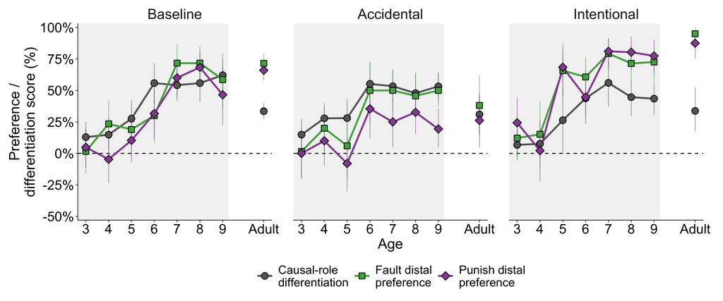

```r
p.matched.role = save_role_development_builds(
  plot_matched_role_development, matched_role_output, "matched_role_differentiation_development_talk_v1",
  c("build00_blank", "build01_baseline", "build02_add_accidental", "build03_add_intentional",
    "build04_add_adults_full"), width = 24)
p.matched.role$main
```

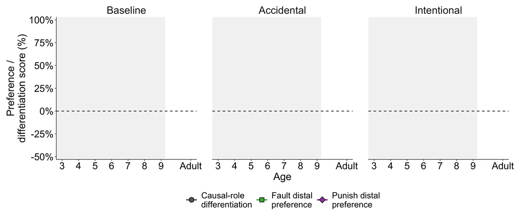

```r
p.matched.role$builds[[1]]
```

The standalone Study 1 series uses 00 blank, 01 causal-role differentiation childhood, 02 add Fault childhood, 03 add Punish childhood, and 04 add all three Adult points. This is saved as **V2**, leaving the titled V1 and its relationship backup unchanged. The V2 numerical CSV is a byte-for-byte copy of V1’s values.

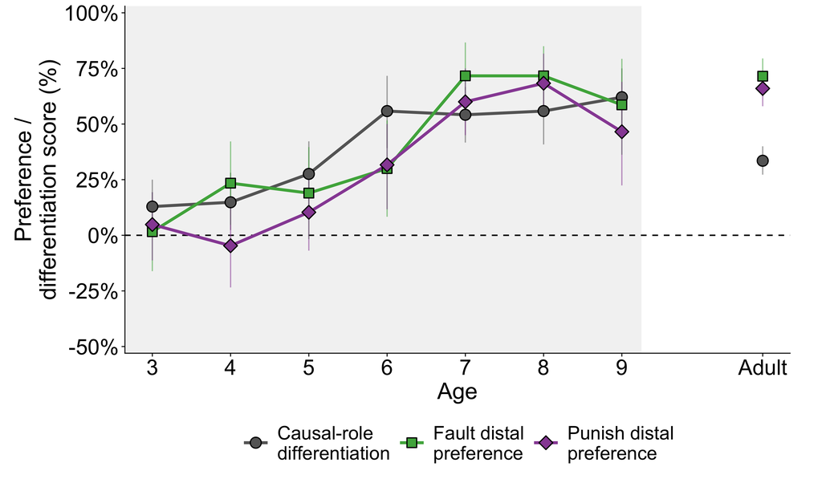

```r
p.study1.role.v2 = save_role_development_builds(
  plot_study1_role_development_v2, role_responsibility_output, "study1_role_differentiation_development_talk_v2",
  c("build00_blank", "build01_causal_differentiation", "build02_add_fault", "build03_add_punish",
    "build04_add_adults_full"), width = 17)
stopifnot(file.copy(file.path(role_responsibility_output, "study1_role_differentiation_development_values.csv"),
                    file.path(role_responsibility_output, "study1_role_differentiation_development_talk_v2_values.csv"),
                    overwrite = TRUE))
p.study1.role.v2$main
```

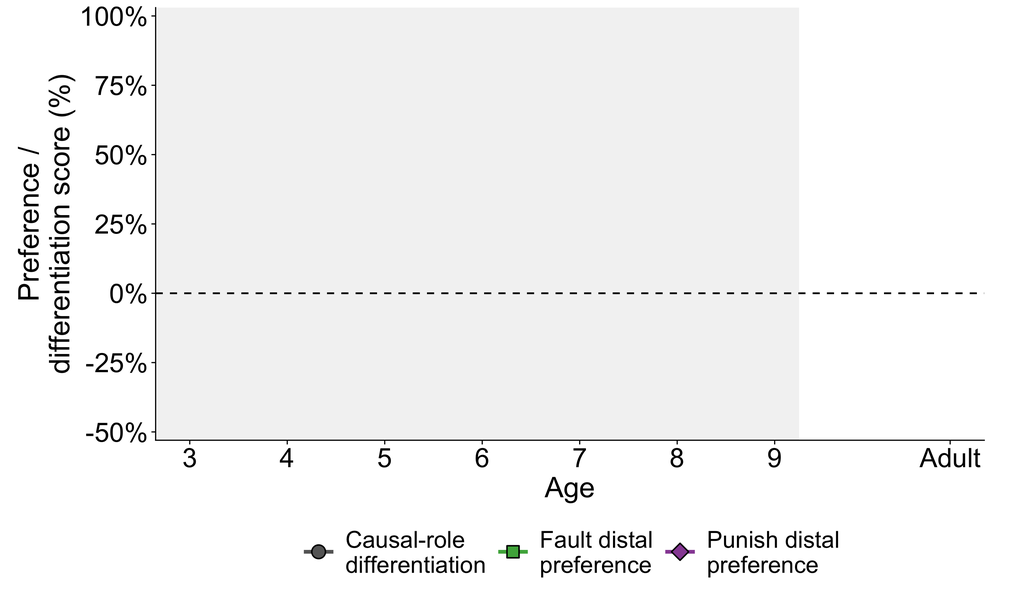

```r
p.study1.role.v2$builds[[1]]
```

## Verify scoring, original Baseline values, and fixed build geometry

```r
# Recalculate Study 2 scores directly from signed binary responses, independently of the wide table.
df.study2.role.direct = bind_rows(df.study2.adults.responses, df.study2.children.responses) %>%
  mutate(signed_yes = endorsed * if_else((measure == "Lexical" & role == "Proximal") |
                                        (measure != "Lexical" & role == "Distal"), 1, -1),
         score_key = case_when(measure %in% c("Caused", "Lexical") ~ "differentiation",
                               measure == "Fault" ~ "fault_preference", TRUE ~ "punish_preference")) %>%
  group_by(population, participant, condition, score_key) %>%
  summarise(checked_score = 2 * mean(signed_yes), .groups = "drop") %>%
  left_join(df.study2.role.long, by = c("population", "participant", "condition", "score_key"),
            relationship = "one-to-one")
stopifnot(nrow(df.study2.role.direct) == 1341L,
          all(abs(df.study2.role.direct$checked_score - df.study2.role.direct$score) < 1e-12))
df.matched.baseline.check = filter(df.matched.role.summary, condition == "Baseline") %>%
  left_join(df.study1.role.development, by = c("population", "age_group", "series"),
            relationship = "one-to-one", suffix = c("_new", "_old"))
for (column in c("n", "mean_pp", "lower_pp", "upper_pp")) {
  stopifnot(identical(df.matched.baseline.check[[paste0(column, "_new")]],
                      df.matched.baseline.check[[paste0(column, "_old")]]))
}

# Keep this CI-aware check local to the new families; earlier build checks remain unchanged.
check_role_development_builds = function(family, expected_counts) {
  full = ggplot_build(family$main)
  full_grob = ggplotGrob(family$main)
  counts = integer(5)
  for (i in seq_along(family$builds)) {
    plot = family$builds[[i]]
    built = ggplot_build(plot)
    grob = ggplotGrob(plot)
    stopifnot(identical(built$layout$layout, full$layout$layout),
              identical(grob$layout, full_grob$layout),
              isTRUE(all.equal(grid::convertWidth(grob$widths, "cm", valueOnly = TRUE),
                               grid::convertWidth(full_grob$widths, "cm", valueOnly = TRUE))),
              isTRUE(all.equal(grid::convertHeight(grob$heights, "cm", valueOnly = TRUE),
                               grid::convertHeight(full_grob$heights, "cm", valueOnly = TRUE))),
              is.null(plot$labels$title), is.null(plot$labels$subtitle), is.null(plot$labels$caption))
    for (panel in seq_along(built$layout$panel_params)) {
      stopifnot(identical(built$layout$panel_params[[panel]]$x.range, full$layout$panel_params[[1]]$x.range),
                identical(built$layout$panel_params[[panel]]$y.range, full$layout$panel_params[[1]]$y.range))
    }
    for (layer in seq_along(built$data)) {
      a = built$data[[layer]]; b = full$data[[layer]]
      stopifnot(identical(a[setdiff(names(a), "alpha")], b[setdiff(names(b), "alpha")]))
      if ("alpha" %in% names(a) && !all(is.na(a$alpha)) && i > 1L) {
        stopifnot(all(a$alpha >= ggplot_build(family$builds[[i - 1L]])$data[[layer]]$alpha))
      }
    }
    points = built$data[[5]]
    intervals = built$data[[3]]
    counts[i] = sum(points$alpha > 0)
    stopifnot(sum(intervals$alpha > 0) == counts[i],
              all(intervals$ymin >= matched_role_limits[1]),
              all(intervals$ymax <= matched_role_limits[2]))
    if (i < 5L) stopifnot(all(points$alpha[points$x == comparison_adult_position] == 0))
  }
  stopifnot(identical(counts, expected_counts),
            identical(ggplot_build(family$builds[[5]])$data, full$data))
  TRUE
}
stopifnot(check_role_development_builds(p.matched.role, c(0L, 21L, 42L, 63L, 72L)),
          check_role_development_builds(p.study1.role.v2, c(0L, 7L, 14L, 21L, 24L)))
# Both new families use exactly the same axis scales.
stopifnot(identical(ggplot_build(p.matched.role$main)$layout$panel_params[[1]]$x.range,
                    ggplot_build(p.study1.role.v2$main)$layout$panel_params[[1]]$x.range),
          identical(ggplot_build(p.matched.role$main)$layout$panel_params[[1]]$y.range,
                    ggplot_build(p.study1.role.v2$main)$layout$panel_params[[1]]$y.range))
```

The shared y scale is -50% to 100%, including every interval. Full-precision values and sample sizes are saved alongside the plots. The panel sequence is a descriptive comparison of samples; it does not establish that adding intention information caused the difference from Study 1. Existing handoff gaps, including the missing Study 2 main adult dataset, remain unresolved.

# Causal-role differentiation and intention effects: Fault and Punish

This additional two-panel talk figure uses exactly **3, 4, 5, 6, Adult**. Both panels contain the same Study 1 Baseline causal-role differentiation reference. Fault and Punish intention effects come from Single Cause and Study 2’s **Distal role only**. No Proximal series, older child groups or previous outputs are changed or included in this new figure.

The reference is the existing participant-level composite, `((Caused Distal - Proximal) + (Lexical Proximal - Distal)) / 2`, using Study 1 only. Reuse its age means and bootstrap intervals exactly. For each intention effect, reuse the existing scenario-averaged participant Yes means, average participants within age and condition, and subtract **Intentional minus Accidental**. Conditions contain different participants; no within-person intention contrast is invented. Yes = 1, No = 0, and neither responses remain included.

## Exact estimates and uncertainty

The main figure omits CIs for presentation clarity. Its full-precision table also reports source condition means, sample sizes and pointwise 95% bootstrap intervals. For the new intention-effect intervals, independently resample whole participants within each age × condition × context, keeping Fault and Punish together, and subtract condition means within each of 5,000 draws. Do not subtract endpoints of separate CIs. The Baseline reference retains its original intervals and is duplicated only for display in the two panels.

```r
role_intention_output = "../../figures/study_comparison/role_differentiation_intention_effects"
dir.create(role_intention_output, recursive = TRUE, showWarnings = FALSE)
role_intention_ages = c("3", "4", "5", "6", "Adult")
role_intention_panels = c("Fault", "Punish")
role_intention_order = c("Causal-role differentiation", "Single Cause", "Chain: Distal")

df.role.intention.means = bind_rows(
  df.single.means %>% mutate(population = "Children", source_study = "Single Cause", context = "Single Cause"),
  df.single.adults.means %>% mutate(population = "Adults", age = NA_integer_,
                                   source_study = "Single Cause", context = "Single Cause"),
  df.study2.means %>% filter(role == "Distal", population == "Adults" | age %in% 3:6) %>%
    mutate(source_study = "Study 2", context = "Chain: Distal")) %>%
  filter(measure %in% role_intention_panels) %>%
  mutate(age_group = factor(if_else(population == "Adults", "Adult", as.character(age)),
                            levels = role_intention_ages)) %>%
  select(source_study, context, population, age_group, participant, condition, measure, yes_mean)
stopifnot(nrow(df.role.intention.means) == 784L,
          !anyNA(df.role.intention.means),
          !anyDuplicated(df.role.intention.means[c("context", "population", "participant", "measure")]),
          all(df.role.intention.means$condition %in% condition_order))

# Whole-participant rows preserve the relation between Fault and Punish during resampling.
df.role.intention.wide = df.role.intention.means %>%
  pivot_wider(names_from = measure, values_from = yes_mean) %>%
  arrange(context, age_group, condition, participant)
set.seed(bootstrap_seed + 24L)
role_intention_intervals = list()
for (context_name in c("Single Cause", "Chain: Distal")) {
  for (age_name in role_intention_ages) {
    rows = df.role.intention.wide %>% filter(context == context_name, age_group == age_name)
    intentional = rows %>% filter(condition == "Intentional") %>% select(all_of(role_intention_panels)) %>% as.matrix()
    accidental = rows %>% filter(condition == "Accidental") %>% select(all_of(role_intention_panels)) %>% as.matrix()
    stopifnot(nrow(intentional) > 0L, nrow(accidental) > 0L, !anyNA(intentional), !anyNA(accidental))
    draws = replicate(bootstrap_replicates, {
      i = sample.int(nrow(intentional), replace = TRUE)
      a = sample.int(nrow(accidental), replace = TRUE)
      100 * (colMeans(intentional[i, , drop = FALSE]) - colMeans(accidental[a, , drop = FALSE]))
    })
    role_intention_intervals[[length(role_intention_intervals) + 1L]] = tibble(
      context = context_name, age_group = age_name, measure = role_intention_panels,
      lower_pp = apply(draws, 1, quantile, probs = .025),
      upper_pp = apply(draws, 1, quantile, probs = .975))
  }
}
df.role.intention.effects = df.role.intention.means %>%
  group_by(source_study, context, population, age_group, measure, condition) %>%
  summarise(n = n(), yes_mean = mean(yes_mean), .groups = "drop") %>%
  pivot_wider(names_from = condition, values_from = c(n, yes_mean)) %>%
  mutate(mean_pp = 100 * (yes_mean_Intentional - yes_mean_Accidental)) %>%
  left_join(bind_rows(role_intention_intervals), by = c("context", "age_group", "measure"),
            relationship = "one-to-one")
df.role.intention.reference = df.study1.role.development %>%
  filter(series == "Causal-role differentiation", age_group %in% role_intention_ages) %>%
  transmute(source_study = "Study 1", population, age_group = as.character(age_group),
            baseline_n = n, mean_pp, lower_pp, upper_pp)
df.role.intention.plot = bind_rows(
  bind_rows(lapply(role_intention_panels, function(panel_name) {
    df.role.intention.reference %>% mutate(panel = panel_name, series = "Causal-role differentiation",
                                          quantity = "Study 1 causal-role differentiation")
  })),
  df.role.intention.effects %>%
    rename(panel = measure, series = context) %>%
    mutate(quantity = "Intentional minus Accidental")) %>%
  mutate(panel = factor(panel, levels = role_intention_panels),
         series = factor(series, levels = role_intention_order),
         age_group = factor(age_group, levels = role_intention_ages),
         x = if_else(age_group == "Adult", single_adult_position,
                     as.numeric(as.character(replace(age_group, age_group == "Adult", NA))))) %>%
  arrange(panel, series, age_group)
stopifnot(nrow(df.role.intention.plot) == 30L,
          !anyDuplicated(df.role.intention.plot[c("panel", "series", "age_group")]),
          !anyNA(df.role.intention.plot$mean_pp),
          all(dplyr::between(df.role.intention.plot$mean_pp, -100, 100)))
write_csv(select(df.role.intention.plot, panel, series, source_study, quantity, population, age_group,
                 baseline_n, n_Intentional, n_Accidental, yes_mean_Intentional, yes_mean_Accidental,
                 mean_pp, lower_pp, upper_pp),
          file.path(role_intention_output, "role_differentiation_intention_effects_talk_v1_values.csv"))
kable(select(df.role.intention.plot, panel, series, age_group, baseline_n, n_Intentional, n_Accidental,
              mean_pp, lower_pp, upper_pp), digits = 3,
      caption = "Exact plotted means and backup 95% intervals (percentage points); the reference repeats in both panels")
```

Exact plotted means and backup 95% intervals (percentage points); the reference repeats in both panels

| panel | series | age_group | baseline_n | n_Intentional | n_Accidental | mean_pp | lower_pp | upper_pp |
| --- | --- | --- | --- | --- | --- | --- | --- | --- |
| Fault | Causal-role differentiation | 3 | 31 | NA | NA | 12.903 | 1.613 | 25.000 |
| Fault | Causal-role differentiation | 4 | 32 | NA | NA | 14.844 | 2.344 | 28.125 |
| Fault | Causal-role differentiation | 5 | 29 | NA | NA | 27.586 | 13.793 | 42.241 |
| Fault | Causal-role differentiation | 6 | 30 | NA | NA | 55.833 | 39.167 | 71.667 |
| Fault | Causal-role differentiation | Adult | 100 | NA | NA | 33.500 | 27.250 | 40.000 |
| Fault | Single Cause | 3 | NA | 14 | 12 | 20.238 | -5.372 | 47.619 |
| Fault | Single Cause | 4 | NA | 10 | 14 | -13.571 | -47.857 | 20.000 |
| Fault | Single Cause | 5 | NA | 13 | 10 | 29.615 | -1.538 | 62.308 |
| Fault | Single Cause | 6 | NA | 13 | 10 | 43.462 | 10.769 | 75.000 |
| Fault | Single Cause | Adult | NA | 16 | 16 | 37.500 | 12.500 | 62.500 |
| Fault | Chain: Distal | 3 | NA | 37 | 32 | 4.561 | -12.416 | 21.328 |
| Fault | Chain: Distal | 4 | NA | 23 | 35 | -2.795 | -24.534 | 18.137 |
| Fault | Chain: Distal | 5 | NA | 19 | 25 | 37.579 | 18.211 | 57.474 |
| Fault | Chain: Distal | 6 | NA | 28 | 24 | 10.119 | -9.821 | 30.060 |
| Fault | Chain: Distal | Adult | NA | 20 | 21 | 33.214 | 16.027 | 52.143 |
| Punish | Causal-role differentiation | 3 | 31 | NA | NA | 12.903 | 1.613 | 25.000 |
| Punish | Causal-role differentiation | 4 | 32 | NA | NA | 14.844 | 2.344 | 28.125 |
| Punish | Causal-role differentiation | 5 | 29 | NA | NA | 27.586 | 13.793 | 42.241 |
| Punish | Causal-role differentiation | 6 | 30 | NA | NA | 55.833 | 39.167 | 71.667 |
| Punish | Causal-role differentiation | Adult | 100 | NA | NA | 33.500 | 27.250 | 40.000 |
| Punish | Single Cause | 3 | NA | 14 | 12 | 2.976 | -25.595 | 30.952 |
| Punish | Single Cause | 4 | NA | 10 | 14 | 4.286 | -32.143 | 40.000 |
| Punish | Single Cause | 5 | NA | 13 | 10 | 39.615 | 6.538 | 71.933 |
| Punish | Single Cause | 6 | NA | 13 | 10 | 46.923 | 19.231 | 73.462 |
| Punish | Single Cause | Adult | NA | 16 | 16 | 90.625 | 81.250 | 100.000 |
| Punish | Chain: Distal | 3 | NA | 37 | 32 | 13.936 | -4.899 | 32.348 |
| Punish | Chain: Distal | 4 | NA | 23 | 35 | -0.807 | -21.677 | 19.255 |
| Punish | Chain: Distal | 5 | NA | 19 | 25 | 50.947 | 27.789 | 71.579 |
| Punish | Chain: Distal | 6 | NA | 28 | 24 | 8.631 | -14.583 | 31.250 |
| Punish | Chain: Distal | Adult | NA | 20 | 21 | 61.548 | 41.786 | 78.571 |

## Talk figure

Gray dashed lines and circles identify the common Baseline reference. Blue squares identify Single Cause intention effects, and red diamonds identify Chain: Distal intention effects. Single Cause is blue **in this new figure** because gray is reserved for the reference; earlier figures retain their colors. Childhood shading ends after age 6 and before the separate Adult reference points. Adults are not treated as another chronological child age, and child lines do not extend to them. Fault and Punish share the same axes and one legend. No title, subtitle, footer, build series or additional plot is added.

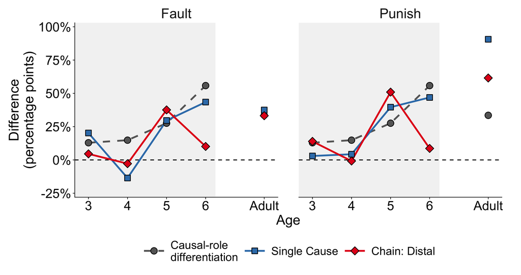

```r
role_intention_colors = setNames(c("#666666", "#377EB8", "#E41A1C"), role_intention_order)
role_intention_shapes = setNames(c(21, 22, 23), role_intention_order)
role_intention_lines = setNames(c("dashed", "solid", "solid"), role_intention_order)
role_intention_labels = setNames(c("Causal-role\ndifferentiation", "Single Cause", "Chain: Distal"), role_intention_order)
role_intention_limits = c(
  min(-25, floor(min(df.role.intention.plot$mean_pp) / 25) * 25),
  max(25, ceiling(max(df.role.intention.plot$mean_pp) / 25) * 25))
p.role.intention = ggplot(df.role.intention.plot, aes(x = x, y = mean_pp, group = series)) +
  annotate("rect", xmin = -Inf, xmax = 6.25, ymin = -Inf, ymax = Inf,
           fill = talk_v2$childhood_fill, color = NA) +
  geom_hline(yintercept = 0, linetype = "dashed", linewidth = 1.1, color = "black") +
  geom_line(data = filter(df.role.intention.plot, population == "Children"),
            aes(color = series, linetype = series), linewidth = talk_v2$line_width) +
  geom_point(aes(fill = series, shape = series), size = 6.8, color = "black", stroke = 1.25) +
  facet_wrap(~ panel, nrow = 1, drop = FALSE) +
  scale_color_manual(NULL, values = role_intention_colors, limits = role_intention_order, labels = role_intention_labels) +
  scale_fill_manual(NULL, values = role_intention_colors, limits = role_intention_order, labels = role_intention_labels) +
  scale_shape_manual(NULL, values = role_intention_shapes, limits = role_intention_order, labels = role_intention_labels) +
  scale_linetype_manual(NULL, values = role_intention_lines, limits = role_intention_order, labels = role_intention_labels) +
  scale_x_continuous(breaks = c(3:6, single_adult_position), labels = role_intention_ages,
                     limits = c(3, single_adult_position), expand = expansion(add = .35)) +
  scale_y_continuous(limits = role_intention_limits, breaks = seq(role_intention_limits[1], role_intention_limits[2], 25),
                     labels = function(x) paste0(x, "%"), expand = expansion(add = 3)) +
  labs(x = "Age", y = "Difference\n(percentage points)", title = NULL, subtitle = NULL, caption = NULL) +
  role_responsibility_theme + theme(legend.key.width = grid::unit(2.2, "cm")) +
  guides(color = guide_legend(nrow = 1), fill = guide_legend(nrow = 1),
         shape = guide_legend(nrow = 1), linetype = guide_legend(nrow = 1))
save_presentation_v2(p.role.intention,
                    file.path(role_intention_output, "role_differentiation_intention_effects_talk_v1"),
                    width = 18, height = 9.5)
p.role.intention
```

## Verify source contrasts and duplicated reference

```r
# Independently subtract the already-validated raw Yes group means.
df.role.intention.checked = bind_rows(
  df.single.summary %>% filter(measure %in% role_intention_panels) %>%
    transmute(context = "Single Cause", population, age_group, measure, condition, n, mean),
  df.study2.summary %>% filter(role == "Distal", measure %in% role_intention_panels,
                               age_group %in% role_intention_ages) %>%
    transmute(context = "Chain: Distal", population, age_group, measure, condition, n, mean)) %>%
  pivot_wider(names_from = condition, values_from = c(n, mean)) %>%
  mutate(checked_pp = 100 * (mean_Intentional - mean_Accidental)) %>%
  left_join(df.role.intention.effects, by = c("context", "population", "age_group", "measure"),
            suffix = c("_checked", "_new"), relationship = "one-to-one")
stopifnot(nrow(df.role.intention.checked) == 20L,
          all(abs(df.role.intention.checked$checked_pp - df.role.intention.checked$mean_pp) < 1e-12),
          all(df.role.intention.checked$n_Intentional_checked == df.role.intention.checked$n_Intentional_new),
          all(df.role.intention.checked$n_Accidental_checked == df.role.intention.checked$n_Accidental_new))
role_reference_fault = df.role.intention.plot %>% filter(series == "Causal-role differentiation", panel == "Fault") %>% select(-panel)
role_reference_punish = df.role.intention.plot %>% filter(series == "Causal-role differentiation", panel == "Punish") %>% select(-panel)
stopifnot(identical(role_reference_fault, role_reference_punish))
role_intention_built = ggplot_build(p.role.intention)
stopifnot(nrow(role_intention_built$data[[4]]) == 30L,
          nrow(role_intention_built$data[[3]]) == 24L,
          all(role_intention_built$data[[3]]$x %in% 3:6),
          identical(role_intention_built$layout$panel_params[[1]]$x.range,
                    role_intention_built$layout$panel_params[[2]]$x.range),
          identical(role_intention_built$layout$panel_params[[1]]$y.range,
                    role_intention_built$layout$panel_params[[2]]$y.range))
```

The reference and intention-effect series are different estimands in common percentage-point units. Their visual relation is descriptive, not a participant-level association or a test that causal differentiation produces sensitivity to intention. The same existing source samples and limitations apply: Study 2 adults are the 41-person pilot; its main adult dataset is missing. Single Cause uses all 32 recovered adults, while its historical N=30 subset remains unidentified. No participant inclusion rule or unresolved scientific handoff conclusion changes.

# Extended development and age-adjusted responsibility relationships

These three new figures preserve all existing outputs and use the same screened participant means and role scores. The developmental extension includes ages 3–9 and Adult for Study 1 differentiation and Chain: Distal intention effects. Single Cause child **pilot** data cover only ages 3–6; its Adult point is separate. The two relationship analyses use **children only**: Study 1 N=211 and Study 2 N=406 (200 Accidental, 206 Intentional).

## Extend the developmental comparison without changing existing estimates

Reuse all previously computed means and intervals. Only Chain: Distal effects at ages 7–9 require new bootstrap draws. The reference remains the Study 1 participant composite `((Caused Distal - Proximal) + (Lexical Proximal - Distal)) / 2`. The colored series are Yes-proportion differences, Intentional minus Accidental, not distal-minus-proximal preferences. Whole participants are independently resampled within age and condition, preserving their Fault/Punish responses within each draw. The pointwise intervals use 5,000 replicates.

```r
age_adjusted_output = "../../figures/study_comparison/role_differentiation_age_adjusted"
dir.create(age_adjusted_output, recursive = TRUE, showWarnings = FALSE)
df.chain.older.means = df.study2.means %>%
  filter(population == "Children", age %in% 7:9, role == "Distal", measure %in% c("Fault", "Punish")) %>%
  select(age, condition, participant, measure, yes_mean)
df.chain.older.wide = df.chain.older.means %>%
  pivot_wider(names_from = measure, values_from = yes_mean) %>% arrange(age, condition, participant)
set.seed(bootstrap_seed + 25L)
chain_older_intervals = list()
for (age_value in 7:9) {
  rows = filter(df.chain.older.wide, age == age_value)
  intentional = rows %>% filter(condition == "Intentional") %>% select(Fault, Punish) %>% as.matrix()
  accidental = rows %>% filter(condition == "Accidental") %>% select(Fault, Punish) %>% as.matrix()
  stopifnot(!anyNA(intentional), !anyNA(accidental))
  draws = replicate(bootstrap_replicates, {
    i = sample.int(nrow(intentional), replace = TRUE)
    a = sample.int(nrow(accidental), replace = TRUE)
    100 * (colMeans(intentional[i, , drop = FALSE]) - colMeans(accidental[a, , drop = FALSE]))
  })
  chain_older_intervals[[as.character(age_value)]] = tibble(
    age = age_value, panel = c("Fault", "Punish"),
    lower_pp = apply(draws, 1, quantile, probs = .025), upper_pp = apply(draws, 1, quantile, probs = .975))
}
df.chain.older.summary = df.chain.older.means %>%
  group_by(age, measure, condition) %>% summarise(n = n(), yes_mean = mean(yes_mean), .groups = "drop") %>%
  pivot_wider(names_from = condition, values_from = c(n, yes_mean)) %>% rename(panel = measure) %>%
  mutate(mean_pp = 100 * (yes_mean_Intentional - yes_mean_Accidental)) %>%
  left_join(bind_rows(chain_older_intervals), by = c("age", "panel"), relationship = "one-to-one") %>%
  mutate(series = "Chain: Distal", source_study = "Study 2", population = "Children",
         age_group = as.character(age), quantity = "Intentional minus Accidental")
df.role.intention.v2 = bind_rows(
  # Keep the original Single Cause and age-3–6/Adult Chain estimates and CIs unchanged.
  df.role.intention.plot %>% filter(series != "Causal-role differentiation") %>% select(-x),
  df.chain.older.summary %>% select(-age),
  bind_rows(lapply(c("Fault", "Punish"), function(panel_name) {
    df.study1.role.development %>% filter(series == "Causal-role differentiation") %>%
      transmute(panel = panel_name, series = as.character(series), source_study = "Study 1", population,
                age_group = as.character(age_group), quantity = "Study 1 causal-role differentiation",
                baseline_n = n, mean_pp, lower_pp, upper_pp)
  }))) %>%
  mutate(panel = factor(panel, levels = c("Fault", "Punish")),
         series = factor(series, levels = role_intention_order), age_group = factor(age_group, levels = age_labels),
         x = if_else(age_group == "Adult", comparison_adult_position,
                     as.numeric(as.character(replace(age_group, age_group == "Adult", NA))))) %>%
  arrange(panel, series, age_group)
stopifnot(nrow(df.role.intention.v2) == 42L,
          !anyDuplicated(df.role.intention.v2[c("panel", "series", "age_group")]),
          !anyNA(select(df.role.intention.v2, mean_pp, lower_pp, upper_pp)))
write_csv(select(df.role.intention.v2, panel, series, source_study, quantity, population, age_group,
                 baseline_n, n_Intentional, n_Accidental, yes_mean_Intentional, yes_mean_Accidental,
                 mean_pp, lower_pp, upper_pp),
          file.path(age_adjusted_output, "role_differentiation_intention_effects_talk_v2_values.csv"))
kable(select(df.role.intention.v2, panel, series, age_group, mean_pp, lower_pp, upper_pp), digits = 3,
      caption = "Extended developmental comparison: exact means and participant-bootstrap 95% intervals (pp)")
```

Extended developmental comparison: exact means and participant-bootstrap 95% intervals (pp)

| panel | series | age_group | mean_pp | lower_pp | upper_pp |
| --- | --- | --- | --- | --- | --- |
| Fault | Causal-role differentiation | 3 | 12.903 | 1.613 | 25.000 |
| Fault | Causal-role differentiation | 4 | 14.844 | 2.344 | 28.125 |
| Fault | Causal-role differentiation | 5 | 27.586 | 13.793 | 42.241 |
| Fault | Causal-role differentiation | 6 | 55.833 | 39.167 | 71.667 |
| Fault | Causal-role differentiation | 7 | 54.167 | 41.667 | 66.667 |
| Fault | Causal-role differentiation | 8 | 55.833 | 40.833 | 70.000 |
| Fault | Causal-role differentiation | 9 | 62.069 | 49.138 | 75.000 |
| Fault | Causal-role differentiation | Adult | 33.500 | 27.250 | 40.000 |
| Fault | Single Cause | 3 | 20.238 | -5.372 | 47.619 |
| Fault | Single Cause | 4 | -13.571 | -47.857 | 20.000 |
| Fault | Single Cause | 5 | 29.615 | -1.538 | 62.308 |
| Fault | Single Cause | 6 | 43.462 | 10.769 | 75.000 |
| Fault | Single Cause | Adult | 37.500 | 12.500 | 62.500 |
| Fault | Chain: Distal | 3 | 4.561 | -12.416 | 21.328 |
| Fault | Chain: Distal | 4 | -2.795 | -24.534 | 18.137 |
| Fault | Chain: Distal | 5 | 37.579 | 18.211 | 57.474 |
| Fault | Chain: Distal | 6 | 10.119 | -9.821 | 30.060 |
| Fault | Chain: Distal | 7 | 28.103 | 11.322 | 44.828 |
| Fault | Chain: Distal | 8 | 24.845 | 5.047 | 44.798 |
| Fault | Chain: Distal | 9 | 19.508 | 3.879 | 35.983 |
| Fault | Chain: Distal | Adult | 33.214 | 16.027 | 52.143 |
| Punish | Causal-role differentiation | 3 | 12.903 | 1.613 | 25.000 |
| Punish | Causal-role differentiation | 4 | 14.844 | 2.344 | 28.125 |
| Punish | Causal-role differentiation | 5 | 27.586 | 13.793 | 42.241 |
| Punish | Causal-role differentiation | 6 | 55.833 | 39.167 | 71.667 |
| Punish | Causal-role differentiation | 7 | 54.167 | 41.667 | 66.667 |
| Punish | Causal-role differentiation | 8 | 55.833 | 40.833 | 70.000 |
| Punish | Causal-role differentiation | 9 | 62.069 | 49.138 | 75.000 |
| Punish | Causal-role differentiation | Adult | 33.500 | 27.250 | 40.000 |
| Punish | Single Cause | 3 | 2.976 | -25.595 | 30.952 |
| Punish | Single Cause | 4 | 4.286 | -32.143 | 40.000 |
| Punish | Single Cause | 5 | 39.615 | 6.538 | 71.933 |
| Punish | Single Cause | 6 | 46.923 | 19.231 | 73.462 |
| Punish | Single Cause | Adult | 90.625 | 81.250 | 100.000 |
| Punish | Chain: Distal | 3 | 13.936 | -4.899 | 32.348 |
| Punish | Chain: Distal | 4 | -0.807 | -21.677 | 19.255 |
| Punish | Chain: Distal | 5 | 50.947 | 27.789 | 71.579 |
| Punish | Chain: Distal | 6 | 8.631 | -14.583 | 31.250 |
| Punish | Chain: Distal | 7 | 48.046 | 31.034 | 64.828 |
| Punish | Chain: Distal | 8 | 33.540 | 12.578 | 54.115 |
| Punish | Chain: Distal | 9 | 51.843 | 33.410 | 69.011 |
| Punish | Chain: Distal | Adult | 61.548 | 41.786 | 78.571 |

## Children-only models and the meaning of age adjustment

Use each child’s existing scenario-averaged, participant-level scores. The outcomes are **Fault or Punish Distal-minus-Proximal preference**, unlike the intention-effect series in the first figure. The predictor is the same causal composite, calculated within the child’s own study/condition. Scores are multiplied by 100 for percentage-point units.

For these requested formulas, **age is numeric age in years (3–9)**, with a linear additive effect. This differs from the earlier exploratory categorical `age_group` models, which remain unchanged. Centering age at the study’s observed child mean and scaling differentiation to 25-point units change interpretation of the intercept/units only, not the requested model:

- Study 1: `responsibility ~ differentiation + age`.
- Study 2: `responsibility ~ differentiation * intention + age`.

Accidental is the Study 2 reference condition. Thus its differentiation coefficient is the Accidental simple slope; the Intentional slope adds the interaction. The intention coefficient is **Intentional minus Accidental at 0% differentiation**, where the composite shows no net expected role distinction. The interaction is the difference between condition slopes, per 25-point increase. These meanings are reported explicitly rather than calling the intention coefficient an unconditional average effect.

Fitted curves average predictions over the original study’s observed child-age distribution, using the **same distribution for both Study 2 conditions**. With additive linear age, this equals predicting at that study’s mean child age. For every bootstrap draw this age distribution stays fixed. Confidence bands are pointwise 95% CIs for the fitted mean, not individual prediction intervals.

```r
df.age.adjusted.children = bind_rows(
  df.study1.role.scores %>% mutate(study = "Study 1", intention = "Baseline"),
  df.study2.role.scores %>% mutate(study = "Study 2", intention = as.character(condition))) %>%
  filter(population == "Children") %>%
  transmute(study, participant, age, age_group, intention,
            differentiation_pp = 100 * differentiation,
            differentiation_25 = 4 * differentiation,
            Fault = 100 * fault_preference, Punish = 100 * punish_preference) %>%
  arrange(study, age, intention, participant)
stopifnot(nrow(df.age.adjusted.children) == 617L,
          sum(df.age.adjusted.children$study == "Study 1") == 211L,
          sum(df.age.adjusted.children$study == "Study 2") == 406L,
          !anyNA(df.age.adjusted.children),
          !anyDuplicated(df.age.adjusted.children[c("study", "participant")]),
          all(df.age.adjusted.children$age %in% 3:9))
# Joint score frequencies retain the pairing needed to reproduce the models without exporting IDs.
df.age.adjusted.frequencies = df.age.adjusted.children %>%
  count(study, intention, age, differentiation_pp, Fault, Punish, name = "participants")
write_csv(df.age.adjusted.frequencies, file.path(age_adjusted_output, "child_score_frequencies.csv"))
```

Bootstrap **whole children**, retaining their predictor and both responsibility outcomes together. Study 1 resamples within age; Study 2 within age × intention. This preserves each observed age/condition cell size. Separate fixed seeds and 5,000 draws make the new models reproducible. No adult enters either model.

```r
age_adjusted_coefficients = list()
age_adjusted_contrasts = list()
age_adjusted_predictions = list()
age_adjusted_fits = list()
for (study_name in c("Study 1", "Study 2")) {
  data = filter(df.age.adjusted.children, study == study_name)
  mean_age = mean(data$age)
  data = mutate(data, age_centered = age - mean_age)
  if (study_name == "Study 2") {
    data$intention = factor(data$intention, levels = c("Accidental", "Intentional"))
    contrasts(data$intention) = contr.treatment(c("Accidental", "Intentional"), base = 1)
  }
  formula = if (study_name == "Study 1") ~ differentiation_25 + age_centered else
    ~ differentiation_25 * intention + age_centered
  design = model.matrix(formula, data = data)
  outcomes = as.matrix(select(data, Fault, Punish))
  # lm.fit is the same least-squares fit as lm, without repeatedly rebuilding model frames.
  fit = lm.fit(design, outcomes)
  stopifnot(fit$rank == ncol(design), !anyNA(fit$coefficients))
  age_adjusted_fits[[study_name]] = list(data = data, design = design, outcomes = outcomes,
                                        coefficients = fit$coefficients, mean_age = mean_age)
  strata = if (study_name == "Study 1") data$age else interaction(data$age, data$intention, drop = TRUE)
  stratum_rows = split(seq_len(nrow(data)), strata)
  set.seed(bootstrap_seed + if (study_name == "Study 1") 26L else 27L)
  coefficient_draws = array(NA_real_, dim = c(ncol(design), 2L, bootstrap_replicates),
                            dimnames = list(colnames(design), c("Fault", "Punish"), NULL))
  for (draw in seq_len(bootstrap_replicates)) {
    selected = unlist(lapply(stratum_rows, function(index) {
      index[sample.int(length(index), replace = TRUE)]
    }), use.names = FALSE)
    sampled_fit = lm.fit(design[selected, , drop = FALSE], outcomes[selected, , drop = FALSE])
    stopifnot(sampled_fit$rank == ncol(design))
    coefficient_draws[, , draw] = sampled_fit$coefficients
  }
  stopifnot(!anyNA(coefficient_draws))

  for (outcome in c("Fault", "Punish")) {
    beta = fit$coefficients[, outcome]
    beta_draws = coefficient_draws[, outcome, ]
    interval = t(apply(beta_draws, 1, quantile, probs = c(.025, .975)))
    age_adjusted_coefficients[[length(age_adjusted_coefficients) + 1L]] = tibble(
      study = study_name, panel = outcome, term = names(beta), estimate_pp = unname(beta),
      lower_pp = interval[, 1], upper_pp = interval[, 2], n = nrow(data),
      standardized_mean_age = mean_age)
    # Verify the faster bootstrap fitting path against the requested ordinary lm formula.
    model_formula = as.formula(paste(outcome, if (study_name == "Study 1")
      "~ differentiation_25 + age_centered" else "~ differentiation_25 * intention + age_centered"))
    ordinary_fit = lm(model_formula, data = data)
    stopifnot(isTRUE(all.equal(unname(coef(ordinary_fit)), unname(beta), tolerance = 1e-10)))

    weights = matrix(0, nrow = if (study_name == "Study 1") 1L else 4L, ncol = length(beta),
                     dimnames = list(NULL, names(beta)))
    weights[1, "differentiation_25"] = 1
    contrast_names = "Differentiation effect per 25 points"
    if (study_name == "Study 2") {
      weights[2, "differentiation_25"] = 1
      weights[2, "differentiation_25:intentionIntentional"] = 1
      weights[3, "intentionIntentional"] = 1
      weights[4, "differentiation_25:intentionIntentional"] = 1
      contrast_names = c("Accidental slope / differentiation main effect per 25 points",
                         "Intentional slope per 25 points", "Intention effect at zero differentiation",
                         "Interaction / slope difference per 25 points")
    }
    contrast_draws = weights %*% beta_draws
    contrast_interval = t(apply(contrast_draws, 1, quantile, probs = c(.025, .975)))
    age_adjusted_contrasts[[length(age_adjusted_contrasts) + 1L]] = tibble(
      study = study_name, panel = outcome, contrast = contrast_names,
      estimate_pp = as.vector(weights %*% beta), lower_pp = contrast_interval[, 1],
      upper_pp = contrast_interval[, 2], n = nrow(data), standardized_mean_age = mean_age,
      bootstrap_replicates = bootstrap_replicates)

    conditions = if (study_name == "Study 1") "Baseline" else c("Accidental", "Intentional")
    for (condition_name in conditions) {
      observed = if (study_name == "Study 1") data else filter(data, intention == condition_name)
      # Draw lines only over the differentiation range observed in the relevant condition.
      x_grid = seq(min(observed$differentiation_pp), max(observed$differentiation_pp), length.out = 81)
      newdata = data.frame(differentiation_25 = x_grid / 25, age_centered = 0)
      if (study_name == "Study 2") newdata$intention = factor(condition_name, levels = c("Accidental", "Intentional"))
      new_design = model.matrix(formula, data = newdata)
      stopifnot(identical(colnames(new_design), names(beta)))
      predictions = as.vector(new_design %*% beta)
      prediction_draws = new_design %*% beta_draws
      prediction_interval = t(apply(prediction_draws, 1, quantile, probs = c(.025, .975)))
      age_adjusted_predictions[[length(age_adjusted_predictions) + 1L]] = tibble(
        study = study_name, panel = outcome, intention = condition_name,
        differentiation_pp = x_grid, prediction_pp = predictions,
        lower_pp = prediction_interval[, 1], upper_pp = prediction_interval[, 2],
        standardized_mean_age = mean_age)
      # Averaging each child's age produces exactly the same fitted line as mean-age prediction.
      direct_prediction = vapply(x_grid[c(1, 41, 81)], function(value) {
        averaged_data = data
        averaged_data$differentiation_25 = value / 25
        if (study_name == "Study 2") averaged_data$intention = factor(condition_name, levels = c("Accidental", "Intentional"))
        mean(predict(ordinary_fit, newdata = averaged_data))
      }, numeric(1))
      stopifnot(all(abs(direct_prediction - predictions[c(1, 41, 81)]) < 1e-10))
    }
  }
}
df.age.adjusted.coefficients = bind_rows(age_adjusted_coefficients)
df.age.adjusted.contrasts = bind_rows(age_adjusted_contrasts)
df.age.adjusted.predictions = bind_rows(age_adjusted_predictions)
write_csv(df.age.adjusted.coefficients, file.path(age_adjusted_output, "age_adjusted_model_coefficients.csv"))
write_csv(df.age.adjusted.contrasts, file.path(age_adjusted_output, "age_adjusted_reported_effects.csv"))
write_csv(df.age.adjusted.predictions, file.path(age_adjusted_output, "age_adjusted_prediction_curves.csv"))
kable(df.age.adjusted.contrasts, digits = 3,
      caption = "Children only: age-adjusted effects and 95% whole-participant bootstrap CIs (percentage points)")
```

Children only: age-adjusted effects and 95% whole-participant bootstrap CIs (percentage points)

| study | panel | contrast | estimate_pp | lower_pp | upper_pp | n | standardized_mean_age | bootstrap_replicates |
| --- | --- | --- | --- | --- | --- | --- | --- | --- |
| Study 1 | Fault | Differentiation effect per 25 points | 14.135 | 9.873 | 18.328 | 211 | 5.957 | 5000 |
| Study 1 | Punish | Differentiation effect per 25 points | 9.479 | 4.781 | 14.083 | 211 | 5.957 | 5000 |
| Study 2 | Fault | Accidental slope / differentiation main effect per 25 points | 7.171 | 1.799 | 12.223 | 406 | 6.032 | 5000 |
| Study 2 | Fault | Intentional slope per 25 points | 6.864 | 3.147 | 10.679 | 406 | 6.032 | 5000 |
| Study 2 | Fault | Intention effect at zero differentiation | 22.805 | 9.171 | 37.206 | 406 | 6.032 | 5000 |
| Study 2 | Fault | Interaction / slope difference per 25 points | -0.307 | -6.553 | 6.094 | 406 | 6.032 | 5000 |
| Study 2 | Punish | Accidental slope / differentiation main effect per 25 points | 2.610 | -2.141 | 7.518 | 406 | 6.032 | 5000 |
| Study 2 | Punish | Intentional slope per 25 points | 7.998 | 4.431 | 11.744 | 406 | 6.032 | 5000 |
| Study 2 | Punish | Intention effect at zero differentiation | 31.234 | 17.006 | 45.416 | 406 | 6.032 | 5000 |
| Study 2 | Punish | Interaction / slope difference per 25 points | 5.387 | -0.478 | 11.111 | 406 | 6.032 | 5000 |

## Presentation figures

The extended comparison shades childhood through age 9 and separates every Adult point from the child lines. Single Cause has no observations or connecting line at ages 7–9. Light vertical bars show all 95% interval bounds.

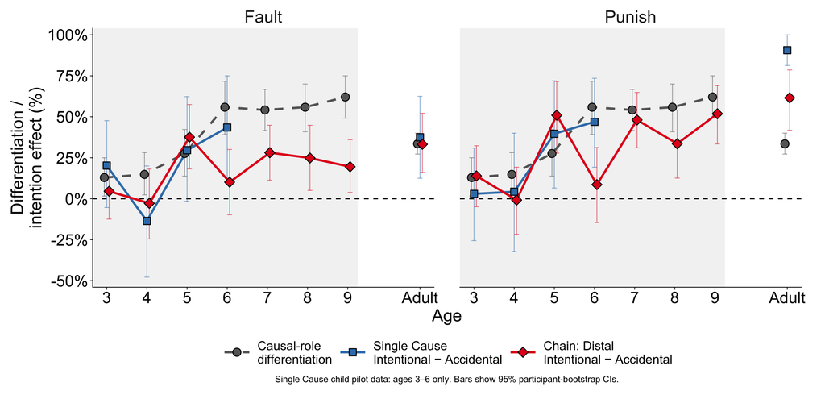

```r
role_intention_v2_limits = c(-50, 100)
role_intention_v2_labels = setNames(c("Causal-role\ndifferentiation",
  "Single Cause\nIntentional − Accidental", "Chain: Distal\nIntentional − Accidental"), role_intention_order)
# Small fixed offsets separate overlapping uncertainty bars without changing age labels.
role_intention_v2_offsets = setNames(c(-.06, 0, .06), role_intention_order)
df.role.intention.v2.plot = df.role.intention.v2 %>%
  mutate(x_plot = x + unname(role_intention_v2_offsets[as.character(series)]))
p.role.intention.v2 = ggplot(df.role.intention.v2.plot, aes(x = x_plot, y = mean_pp, group = series)) +
  annotate("rect", xmin = -Inf, xmax = 9.25, ymin = -Inf, ymax = Inf,
           fill = talk_v2$childhood_fill, color = NA) +
  geom_hline(yintercept = 0, linetype = "dashed", linewidth = 1.1, color = "black") +
  geom_errorbar(aes(ymin = lower_pp, ymax = upper_pp, color = series),
                width = .12, linewidth = .65, alpha = .6, show.legend = FALSE) +
  geom_line(data = filter(df.role.intention.v2.plot, population == "Children"),
            aes(color = series, linetype = series), linewidth = talk_v2$line_width) +
  geom_point(aes(fill = series, shape = series), size = 6.8, color = "black", stroke = 1.25) +
  facet_wrap(~ panel, nrow = 1, drop = FALSE) +
  scale_color_manual(NULL, values = role_intention_colors, limits = role_intention_order, labels = role_intention_v2_labels) +
  scale_fill_manual(NULL, values = role_intention_colors, limits = role_intention_order, labels = role_intention_v2_labels) +
  scale_shape_manual(NULL, values = role_intention_shapes, limits = role_intention_order, labels = role_intention_v2_labels) +
  scale_linetype_manual(NULL, values = role_intention_lines, limits = role_intention_order, labels = role_intention_v2_labels) +
  scale_x_continuous(breaks = c(3:9, comparison_adult_position), labels = age_labels,
                     limits = c(2.7, comparison_adult_position + .3), expand = expansion(add = .05)) +
  scale_y_continuous(limits = role_intention_v2_limits, breaks = seq(-50, 100, 25),
                     labels = function(x) paste0(x, "%"), expand = expansion(add = 4)) +
  labs(x = "Age", y = "Differentiation /\nintention effect (%)",
       caption = "Single Cause child pilot data: ages 3–6 only. Bars show 95% participant-bootstrap CIs.") +
  role_responsibility_theme +
  theme(legend.key.width = grid::unit(2.2, "cm"), legend.text = element_text(size = 25),
        plot.caption = element_text(size = 18, hjust = .5, margin = margin(t = 12))) +
  guides(color = guide_legend(nrow = 1), fill = guide_legend(nrow = 1),
         shape = guide_legend(nrow = 1), linetype = guide_legend(nrow = 1))
save_presentation_v2(p.role.intention.v2,
  file.path(age_adjusted_output, "role_differentiation_intention_effects_talk_v2"), width = 23, height = 11)
p.role.intention.v2
```

In the relationship figures, each faint point represents one child. Small, fixed-seed jitter (at most 1.5 percentage points) separates coincident discrete scores for display only. Models and numerical exports use the exact scores. The fitted mean and its uncertainty band are adjusted for age; the background observations are raw scores. Shared axes allow direct comparison between studies. The vertical zero guide marks no net causal differentiation; the horizontal zero guide marks equal distal/proximal responsibility endorsement.

```r
df.age.adjusted.points = df.age.adjusted.children %>%
  pivot_longer(c(Fault, Punish), names_to = "panel", values_to = "responsibility_pp") %>%
  mutate(panel = factor(panel, levels = c("Fault", "Punish")))
df.age.adjusted.predictions = df.age.adjusted.predictions %>%
  mutate(panel = factor(panel, levels = c("Fault", "Punish")))
relationship_theme = role_responsibility_theme +
  theme(panel.spacing.x = grid::unit(4, "cm"), axis.text = element_text(size = 28), axis.title = element_text(size = 31),
        strip.text = element_text(size = 34), legend.text = element_text(size = 27),
        plot.subtitle = element_text(size = 22, hjust = .5, margin = margin(b = 22)),
        plot.caption = element_text(size = 18, hjust = .5, margin = margin(t = 16)),
        legend.key.width = grid::unit(2, "cm"))
relationship_axes = list(
  facet_wrap(~ panel, nrow = 1),
  scale_x_continuous(limits = c(-103, 103), breaks = seq(-100, 100, 50),
                     labels = function(x) paste0(x, "%"), expand = expansion(mult = 0)),
  scale_y_continuous(limits = c(-103, 103), breaks = seq(-100, 100, 50),
                     labels = function(x) paste0(x, "%"), expand = expansion(mult = 0)),
  labs(x = "Causal-role differentiation (%)", y = "Distal responsibility\npreference (%)",
       subtitle = "Farther right: clearer causal roles     •     Farther up: more distal responsibility"),
  relationship_theme)
relationship_guides = list(
  geom_hline(yintercept = 0, color = "#777777", linetype = "dashed", linewidth = .7),
  geom_vline(xintercept = 0, color = "#BBBBBB", linetype = "dotted", linewidth = .5))
```

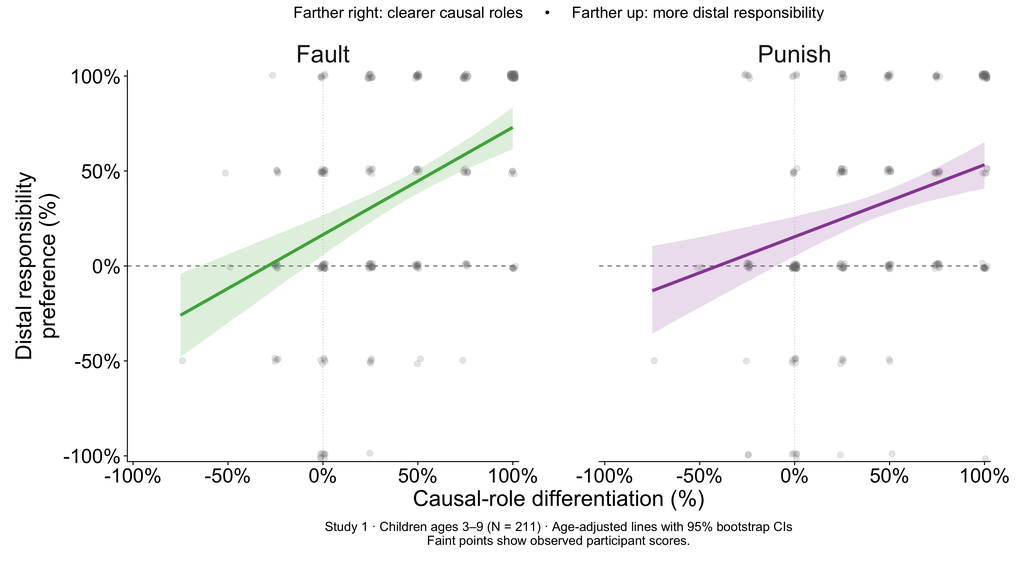

```r
p.study1.age.adjusted = ggplot() + relationship_guides +
  geom_point(data = filter(df.age.adjusted.points, study == "Study 1"),
             aes(x = differentiation_pp, y = responsibility_pp),
             position = position_jitter(width = 1.5, height = 1.5, seed = bootstrap_seed + 28L),
             size = 3.8, color = "#777777", alpha = .18) +
  geom_ribbon(data = filter(df.age.adjusted.predictions, study == "Study 1"),
              aes(x = differentiation_pp, ymin = lower_pp, ymax = upper_pp, fill = panel),
              alpha = .18, show.legend = FALSE) +
  geom_line(data = filter(df.age.adjusted.predictions, study == "Study 1"),
            aes(x = differentiation_pp, y = prediction_pp, color = panel),
            linewidth = 2.1, show.legend = FALSE) +
  scale_color_manual(values = measure_colors) + scale_fill_manual(values = measure_colors) +
  relationship_axes +
  labs(caption = "Study 1 · Children ages 3–9 (N = 211) · Age-adjusted lines with 95% bootstrap CIs\nFaint points show observed participant scores.")
save_presentation_v2(p.study1.age.adjusted,
  file.path(age_adjusted_output, "study1_role_differentiation_age_adjusted_talk_v1"), width = 20, height = 11)
p.study1.age.adjusted
```

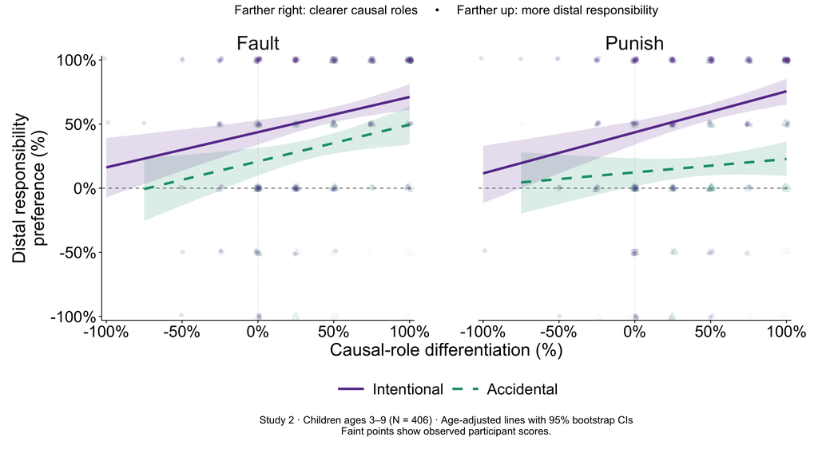

```r
relationship_condition_order = c("Intentional", "Accidental")
p.study2.age.adjusted = ggplot() + relationship_guides +
  geom_point(data = filter(df.age.adjusted.points, study == "Study 2"),
             aes(x = differentiation_pp, y = responsibility_pp, color = intention, shape = intention),
             position = position_jitter(width = 1.5, height = 1.5, seed = bootstrap_seed + 29L),
             size = 3.5, alpha = .14, show.legend = FALSE) +
  geom_ribbon(data = filter(df.age.adjusted.predictions, study == "Study 2"),
              aes(x = differentiation_pp, ymin = lower_pp, ymax = upper_pp, fill = intention),
              alpha = .16, show.legend = FALSE) +
  geom_line(data = filter(df.age.adjusted.predictions, study == "Study 2"),
            aes(x = differentiation_pp, y = prediction_pp, color = intention, linetype = intention),
            linewidth = 2.1) +
  scale_color_manual(NULL, values = comparison_colors, limits = relationship_condition_order) +
  scale_fill_manual(NULL, values = comparison_colors, limits = relationship_condition_order) +
  scale_linetype_manual(NULL, values = condition_lines, limits = relationship_condition_order) +
  scale_shape_manual(NULL, values = c(Intentional = 16, Accidental = 2), limits = relationship_condition_order) +
  relationship_axes +
  labs(caption = "Study 2 · Children ages 3–9 (N = 406) · Age-adjusted lines with 95% bootstrap CIs\nFaint points show observed participant scores.") +
  guides(color = guide_legend(nrow = 1), linetype = guide_legend(nrow = 1))
save_presentation_v2(p.study2.age.adjusted,
  file.path(age_adjusted_output, "study2_role_differentiation_age_adjusted_talk_v1"), width = 20, height = 11)
p.study2.age.adjusted
```

## Verify the extension and interpretation

The new developmental table must preserve all 30 old estimates and intervals, add exactly 12 older-child points, and repeat the same baseline reference in both panels. Source condition means independently reproduce every intention effect. The models are checked against ordinary `lm`, with 10 reported contrasts and 486 fitted-curve rows; all confidence limits fit within the displayed axes.

```r
df.role.intention.v2.check = df.role.intention.v2 %>%
  inner_join(df.role.intention.plot, by = c("panel", "series", "age_group"), suffix = c("", "_v1"),
             relationship = "one-to-one")
stopifnot(nrow(df.role.intention.v2.check) == 30L,
          all(df.role.intention.v2.check$mean_pp == df.role.intention.v2.check$mean_pp_v1),
          all(df.role.intention.v2.check$lower_pp == df.role.intention.v2.check$lower_pp_v1),
          all(df.role.intention.v2.check$upper_pp == df.role.intention.v2.check$upper_pp_v1),
          all(df.role.intention.v2$lower_pp >= min(role_intention_v2_limits)),
          all(df.role.intention.v2$upper_pp <= max(role_intention_v2_limits)))
df.chain.older.check = df.study2.summary %>%
  filter(population == "Children", age_group %in% as.character(7:9), role == "Distal", measure %in% c("Fault", "Punish")) %>%
  select(age_group, panel = measure, condition, mean) %>% pivot_wider(names_from = condition, values_from = mean) %>%
  inner_join(filter(df.role.intention.v2, series == "Chain: Distal"), by = c("age_group", "panel"),
             relationship = "one-to-one")
stopifnot(nrow(df.chain.older.check) == 6L,
          all(abs(df.chain.older.check$mean_pp - 100 * (df.chain.older.check$Intentional - df.chain.older.check$Accidental)) < 1e-10))
role_intention_v2_built = ggplot_build(p.role.intention.v2)
stopifnot(nrow(role_intention_v2_built$data[[5]]) == 42L,
          nrow(role_intention_v2_built$data[[4]]) == 36L,
          all(role_intention_v2_built$data[[4]]$x < 9.1),
          all(filter(df.role.intention.v2, series == "Single Cause")$age_group %in% c("3", "4", "5", "6", "Adult")),
          identical(filter(df.role.intention.v2, panel == "Fault", series == "Causal-role differentiation")$mean_pp,
                    filter(df.role.intention.v2, panel == "Punish", series == "Causal-role differentiation")$mean_pp),
          nrow(df.age.adjusted.contrasts) == 10L, nrow(df.age.adjusted.predictions) == 486L,
          !anyNA(df.age.adjusted.contrasts), !anyNA(df.age.adjusted.predictions),
          all(df.age.adjusted.predictions$lower_pp >= -100), all(df.age.adjusted.predictions$upper_pp <= 100),
          nrow(ggplot_build(p.study1.age.adjusted)$data[[3]]) == 422L,
          nrow(ggplot_build(p.study2.age.adjusted)$data[[3]]) == 812L)
```

A 25-point increase in differentiation predicts **14.1 points more distal fault preference** (95% CI 9.9–18.3) and **9.5 points more distal punishment preference** (4.8–14.1) in Study 1 after linear age adjustment. In Study 2, both fault slopes are positive and nearly equal. The punishment slope is larger under intention, but the interaction interval includes zero (−0.5 to 11.1 points per 25-point increase): this snapshot does not establish different punishment slopes. The intention-related level shift at zero differentiation is positive for both outcomes. These are exploratory, cross-sectional associations, not evidence that differentiation causes responsibility judgments or mediates development. CIs are not adjusted for multiple comparisons and assume independent participants; household dependence is not modeled. Original sample, pilot and handoff limitations remain unchanged.

# Binned causal differentiation and raw responsibility

This new three-panel figure separates **when causal-role differentiation emerges** from **how Intentional and Accidental raw Yes rates separate** in Single Cause and Chain: Distal. The age groups are 3–4, 5–6 and Adult. Ages 7–9 do not enter these binned summaries; they remain in earlier figures. Existing figures, data, inclusion rules and handoff conclusions are unchanged.

Each child has equal weight within the displayed age bin: combine participant means, not the two single-year group means. Study 1 supplies the participant composite `((Caused Distal - Caused Proximal) + (Lexical Proximal - Lexical Distal)) / 2`. Single Cause and Study 2 Distal supply the **raw Yes proportions** for Fault and Punish, separately by condition. Yes=1, No=0, with both/neither retained. Average available scenarios within participant before summarizing participants.

## Reuse raw-response summaries and bin baseline participant scores

The 24 responsibility means, Ns and 95% bootstrap CIs are reused exactly from `df.stage.summary`. Only the two binned child baseline composites need new intervals; these use 5,000 whole-participant draws within bin, with a separate fixed seed. The Adult baseline mean and CI are reused from the earlier Study 1 role-differentiation summary. Intervals are pointwise 95% percentile CIs for each mean, not CIs or tests of the intentional–accidental or between-context gaps.

```r
binned_responsibility_output = "../../figures/study_comparison/binned_role_and_responsibility"
dir.create(binned_responsibility_output, recursive = TRUE, showWarnings = FALSE)
binned_age_labels = c("3–4", "5–6", "Adult")
df.binned.baseline.participants = df.study1.role.scores %>%
  mutate(stage = stage_group(population, age)) %>% filter(!is.na(stage))
stopifnot(nrow(df.binned.baseline.participants) == 222L,
          !anyNA(df.binned.baseline.participants$differentiation),
          all(filter(df.binned.baseline.participants, population == "Children")$age %in% 3:6))
set.seed(bootstrap_seed + 30L)
df.binned.baseline.children = df.binned.baseline.participants %>%
  filter(population == "Children") %>% arrange(stage, participant) %>%
  group_by(population, stage) %>% summarise(summary = list(bootstrap_mean(differentiation)), .groups = "drop") %>%
  unnest_wider(summary) %>% transmute(population, stage, n, mean_pct = 100 * mean,
                                     lower_pct = 100 * lower, upper_pct = 100 * upper)
df.binned.baseline = bind_rows(
  df.binned.baseline.children,
  df.study1.role.development %>% filter(population == "Adults", series == "Causal-role differentiation") %>%
    transmute(population, stage = factor("Adults", levels = stage_order), n,
              mean_pct = mean_pp, lower_pct = lower_pp, upper_pct = upper_pp)) %>%
  mutate(panel = "Causal-role\ndifferentiation", study = "Study 1", context = "Baseline",
         condition = "Baseline", quantity = "Causal-role differentiation", unit = "percentage points",
         x = as.integer(stage)) %>% arrange(stage)
df.binned.responsibility = df.stage.summary %>%
  filter((study == "Single Cause" | (study == "Study 2" & role == "Distal")),
         measure %in% c("Fault", "Punish")) %>%
  transmute(panel = factor(measure, levels = c("Fault", "Punish")), study, population, stage,
            context = if_else(study == "Single Cause", "Single Cause", "Chain: Distal"),
            condition = as.character(condition), quantity = "Raw Yes responses", unit = "percent yes",
            n, mean_pct = yes_pct, lower_pct, upper_pct, x = as.integer(stage))
# The CSV explicitly distinguishes the first panel's contrast from raw Yes rates.
df.binned.responsibility.values = bind_rows(df.binned.baseline, df.binned.responsibility) %>%
  mutate(panel = gsub("\n", " ", as.character(panel)), age_group = binned_age_labels[as.integer(stage)]) %>%
  select(panel, study, context, condition, population, age_group, quantity, unit, n, mean_pct, lower_pct, upper_pct) %>%
  arrange(match(panel, c("Causal-role differentiation", "Fault", "Punish")),
          match(age_group, binned_age_labels), match(context, c("Baseline", "Single Cause", "Chain: Distal")),
          match(condition, c("Baseline", "Intentional", "Accidental")))
stopifnot(nrow(df.binned.baseline) == 3L, nrow(df.binned.responsibility) == 24L,
          identical(df.binned.baseline$n, c(63L, 59L, 100L)),
          !anyNA(df.binned.responsibility.values),
          all(df.binned.responsibility$mean_pct >= 0), all(df.binned.responsibility$mean_pct <= 100),
          all(df.binned.responsibility$lower_pct >= 0), all(df.binned.responsibility$upper_pct <= 100))
write_csv(df.binned.responsibility.values,
          file.path(binned_responsibility_output, "causal_role_and_raw_responsibility_talk_v1_values.csv"))
kable(df.binned.responsibility.values, digits = 3,
      caption = "Binned comparison: exact plotted means, participant Ns and 95% bootstrap CIs")
```

Binned comparison: exact plotted means, participant Ns and 95% bootstrap CIs

| panel | study | context | condition | population | age_group | quantity | unit | n | mean_pct | lower_pct | upper_pct |
| --- | --- | --- | --- | --- | --- | --- | --- | --- | --- | --- | --- |
| Causal-role differentiation | Study 1 | Baseline | Baseline | Children | 3–4 | Causal-role differentiation | percentage points | 63 | 13.889 | 5.556 | 22.619 |
| Causal-role differentiation | Study 1 | Baseline | Baseline | Children | 5–6 | Causal-role differentiation | percentage points | 59 | 41.949 | 30.085 | 53.390 |
| Causal-role differentiation | Study 1 | Baseline | Baseline | Adults | Adult | Causal-role differentiation | percentage points | 100 | 33.500 | 27.250 | 40.000 |
| Fault | Single Cause | Single Cause | Intentional | Children | 3–4 | Raw Yes responses | percent yes | 24 | 72.917 | 58.333 | 87.500 |
| Fault | Single Cause | Single Cause | Accidental | Children | 3–4 | Raw Yes responses | percent yes | 26 | 69.231 | 53.846 | 84.615 |
| Fault | Study 2 | Chain: Distal | Intentional | Children | 3–4 | Raw Yes responses | percent yes | 60 | 58.333 | 48.333 | 67.500 |
| Fault | Study 2 | Chain: Distal | Accidental | Children | 3–4 | Raw Yes responses | percent yes | 67 | 56.716 | 47.761 | 65.672 |
| Fault | Single Cause | Single Cause | Intentional | Children | 5–6 | Raw Yes responses | percent yes | 26 | 86.538 | 76.923 | 94.231 |
| Fault | Single Cause | Single Cause | Accidental | Children | 5–6 | Raw Yes responses | percent yes | 20 | 50.000 | 30.000 | 70.000 |
| Fault | Study 2 | Chain: Distal | Intentional | Children | 5–6 | Raw Yes responses | percent yes | 47 | 78.723 | 70.213 | 87.234 |
| Fault | Study 2 | Chain: Distal | Accidental | Children | 5–6 | Raw Yes responses | percent yes | 49 | 55.102 | 42.857 | 66.327 |
| Fault | Single Cause | Single Cause | Intentional | Adults | Adult | Raw Yes responses | percent yes | 16 | 93.750 | 81.250 | 100.000 |
| Fault | Single Cause | Single Cause | Accidental | Adults | Adult | Raw Yes responses | percent yes | 16 | 56.250 | 34.375 | 78.125 |
| Fault | Study 2 | Chain: Distal | Intentional | Adults | Adult | Raw Yes responses | percent yes | 20 | 97.500 | 92.500 | 100.000 |
| Fault | Study 2 | Chain: Distal | Accidental | Adults | Adult | Raw Yes responses | percent yes | 21 | 64.286 | 47.619 | 80.952 |
| Punish | Single Cause | Single Cause | Intentional | Children | 3–4 | Raw Yes responses | percent yes | 24 | 60.417 | 43.750 | 75.000 |
| Punish | Single Cause | Single Cause | Accidental | Children | 3–4 | Raw Yes responses | percent yes | 26 | 57.692 | 42.308 | 73.077 |
| Punish | Study 2 | Chain: Distal | Intentional | Children | 3–4 | Raw Yes responses | percent yes | 60 | 54.167 | 43.333 | 64.167 |
| Punish | Study 2 | Chain: Distal | Accidental | Children | 3–4 | Raw Yes responses | percent yes | 67 | 45.522 | 35.821 | 55.224 |
| Punish | Single Cause | Single Cause | Intentional | Children | 5–6 | Raw Yes responses | percent yes | 26 | 80.769 | 67.308 | 92.308 |
| Punish | Single Cause | Single Cause | Accidental | Children | 5–6 | Raw Yes responses | percent yes | 20 | 37.500 | 20.000 | 55.000 |
| Punish | Study 2 | Chain: Distal | Intentional | Children | 5–6 | Raw Yes responses | percent yes | 47 | 68.085 | 56.383 | 79.787 |
| Punish | Study 2 | Chain: Distal | Accidental | Children | 5–6 | Raw Yes responses | percent yes | 49 | 39.796 | 28.571 | 51.020 |
| Punish | Single Cause | Single Cause | Intentional | Adults | Adult | Raw Yes responses | percent yes | 16 | 93.750 | 84.375 | 100.000 |
| Punish | Single Cause | Single Cause | Accidental | Adults | Adult | Raw Yes responses | percent yes | 16 | 3.125 | 0.000 | 9.375 |
| Punish | Study 2 | Chain: Distal | Intentional | Adults | Adult | Raw Yes responses | percent yes | 20 | 92.500 | 80.000 | 100.000 |
| Punish | Study 2 | Chain: Distal | Accidental | Adults | Adult | Raw Yes responses | percent yes | 21 | 30.952 | 14.286 | 47.619 |

## One neutral baseline panel and two context/condition panels

Blue means Single Cause; red means Chain: Distal. Intentional uses solid lines and filled circles; Accidental uses dashed lines and open triangles. Only the responsibility panels use these four combinations. Their 50% line is a visual reference, not a chance-model assumption. The baseline panel uses a 0% reference and a neutral trajectory, with its own differentiation axis title.

The displayed child-bin means connect to Adult group means as requested; these are different samples, not within-participant development or a chronological adult age. Small, fixed offsets separate overlapping responsibility CIs while keeping all four trajectories centered around each age category. `patchwork` only arranges the baseline plot and the two responsibility facets and collects one shared legend; it does not compute or change scores.

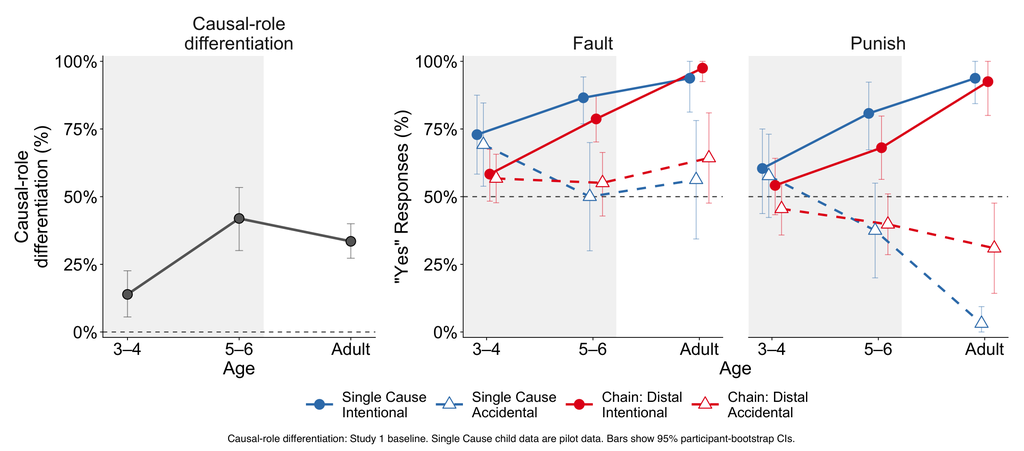

```r
binned_context_colors = c("Single Cause" = "#377EB8", "Chain: Distal" = "#E41A1C")
binned_series_order = c("Single Cause Intentional", "Single Cause Accidental",
                        "Chain: Distal Intentional", "Chain: Distal Accidental")
binned_series_labels = c("Single Cause\nIntentional", "Single Cause\nAccidental",
                         "Chain: Distal\nIntentional", "Chain: Distal\nAccidental")
binned_series_colors = setNames(rep(binned_context_colors, each = 2), binned_series_order)
binned_series_fills = setNames(c(binned_context_colors[[1]], "white", binned_context_colors[[2]], "white"), binned_series_order)
binned_series_shapes = setNames(rep(c(21, 24), 2), binned_series_order)
binned_series_lines = setNames(rep(c("solid", "dashed"), 2), binned_series_order)
binned_series_offsets = setNames(c(-.09, -.03, .03, .09), binned_series_order)
df.binned.responsibility.plot = df.binned.responsibility %>%
  mutate(series = factor(paste(context, condition), levels = binned_series_order),
         x_plot = x + unname(binned_series_offsets[as.character(series)]))
binned_baseline_limits = c(min(0, 25 * floor(min(df.binned.baseline$lower_pct) / 25)), 100)
binned_talk_theme = role_responsibility_theme +
  theme(axis.text = element_text(size = 30), axis.title = element_text(size = 32),
        strip.text = element_text(size = 32), legend.text = element_text(size = 25),
        legend.key.width = grid::unit(2.1, "cm"),
        panel.spacing.x = grid::unit(1.6, "cm"),
        plot.margin = margin(8, 18, 8, 16))
binned_x_scale = function() {
  scale_x_continuous(breaks = 1:3, labels = binned_age_labels, limits = c(.78, 3.22),
                     expand = expansion(mult = 0))
}
p.binned.baseline = ggplot(df.binned.baseline, aes(x = x, y = mean_pct, group = 1)) +
  annotate("rect", xmin = -Inf, xmax = 2.22, ymin = -Inf, ymax = Inf,
           fill = talk_v2$childhood_fill, color = NA) +
  geom_hline(yintercept = 0, linetype = "dashed", linewidth = .9, color = "#555555") +
  geom_errorbar(aes(ymin = lower_pct, ymax = upper_pct), width = .07,
                color = "#666666", linewidth = .7, alpha = .65) +
  geom_line(color = "#666666", linewidth = 2.1) +
  geom_point(shape = 21, fill = "#666666", color = "black", size = 7.2, stroke = 1.15) +
  facet_wrap(~ panel, nrow = 1) + binned_x_scale() +
  scale_y_continuous(limits = binned_baseline_limits, breaks = seq(binned_baseline_limits[1], 100, 25),
                     labels = function(x) paste0(x, "%"), expand = expansion(add = 2)) +
  labs(x = "Age", y = "Causal-role\ndifferentiation (%)") + binned_talk_theme
p.binned.raw.responsibility = ggplot(df.binned.responsibility.plot,
                                    aes(x = x_plot, y = mean_pct, group = series)) +
  annotate("rect", xmin = -Inf, xmax = 2.22, ymin = -Inf, ymax = Inf,
           fill = talk_v2$childhood_fill, color = NA) +
  geom_hline(yintercept = 50, linetype = "dashed", linewidth = .95, color = "#555555") +
  geom_errorbar(aes(ymin = lower_pct, ymax = upper_pct, color = series),
                width = .055, linewidth = .65, alpha = .5, show.legend = FALSE) +
  geom_line(aes(color = series, linetype = series), linewidth = 1.9) +
  geom_point(aes(color = series, fill = series, shape = series), size = 7.2, stroke = 1.25) +
  facet_wrap(~ panel, nrow = 1) + binned_x_scale() +
  scale_y_continuous(limits = c(0, 100), breaks = seq(0, 100, 25),
                     labels = function(x) paste0(x, "%"), expand = expansion(add = 2)) +
  scale_color_manual(NULL, values = binned_series_colors, limits = binned_series_order, labels = binned_series_labels) +
  scale_fill_manual(NULL, values = binned_series_fills, limits = binned_series_order, labels = binned_series_labels) +
  scale_shape_manual(NULL, values = binned_series_shapes, limits = binned_series_order, labels = binned_series_labels) +
  scale_linetype_manual(NULL, values = binned_series_lines, limits = binned_series_order, labels = binned_series_labels) +
  labs(x = "Age", y = '"Yes" Responses (%)') + binned_talk_theme +
  guides(color = guide_legend(nrow = 1), fill = guide_legend(nrow = 1),
         shape = guide_legend(nrow = 1), linetype = guide_legend(nrow = 1))
p.binned.role.responsibility = patchwork::wrap_plots(p.binned.baseline, p.binned.raw.responsibility,
                                                    widths = c(1, 2), guides = "collect") +
  patchwork::plot_annotation(
    caption = "Causal-role differentiation: Study 1 baseline. Single Cause child data are pilot data. Bars show 95% participant-bootstrap CIs.",
    theme = theme(plot.caption = element_text(size = 18, hjust = .5, margin = margin(t = 10)),
                  plot.margin = margin(10, 10, 12, 10))) &
  theme(legend.position = "bottom")
save_presentation_v2(p.binned.role.responsibility,
                    file.path(binned_responsibility_output, "causal_role_and_raw_responsibility_talk_v1"),
                    width = 25, height = 11)
p.binned.role.responsibility
```

## Check participant weighting, source identity and display geometry

Recompute the first panel from the underlying role-specific Yes means, and recompute responsibility from participant Yes means. Every plotted mean and N must match. The original 24 raw-response intervals must be unchanged, and the figure must contain exactly three baseline points plus 24 responsibility points, with no out-of-range CI bounds.

```r
df.binned.baseline.checked = df.stage.means %>% filter(study == "Study 1") %>%
  select(population, participant, stage, measure, role, yes_mean) %>%
  pivot_wider(names_from = c(measure, role), values_from = yes_mean) %>%
  mutate(checked_score = ((Caused_Distal - Caused_Proximal) + (Lexical_Proximal - Lexical_Distal)) / 2) %>%
  group_by(population, stage) %>% summarise(checked_n = n(), checked_mean = 100 * mean(checked_score), .groups = "drop") %>%
  left_join(df.binned.baseline, by = c("population", "stage"), relationship = "one-to-one")
df.binned.raw.checked = df.stage.means %>%
  filter((study == "Single Cause" | (study == "Study 2" & role == "Distal")), measure %in% c("Fault", "Punish")) %>%
  group_by(study, stage, condition, panel = measure) %>%
  summarise(checked_n = n(), checked_mean = 100 * mean(yes_mean), .groups = "drop") %>%
  left_join(df.binned.responsibility, by = c("study", "stage", "condition", "panel"), relationship = "one-to-one")
df.binned.raw.intervals = df.stage.summary %>%
  filter((study == "Single Cause" | (study == "Study 2" & role == "Distal")), measure %in% c("Fault", "Punish")) %>%
  select(study, stage, condition, panel = measure, original_lower = lower_pct, original_upper = upper_pct) %>%
  left_join(df.binned.responsibility, by = c("study", "stage", "condition", "panel"), relationship = "one-to-one")
binned_baseline_built = ggplot_build(p.binned.baseline)
binned_raw_built = ggplot_build(p.binned.raw.responsibility)
stopifnot(nrow(df.binned.baseline.checked) == 3L,
          all(df.binned.baseline.checked$n == df.binned.baseline.checked$checked_n),
          all(abs(df.binned.baseline.checked$mean_pct - df.binned.baseline.checked$checked_mean) < 1e-10),
          nrow(df.binned.raw.checked) == 24L,
          all(df.binned.raw.checked$n == df.binned.raw.checked$checked_n),
          all(abs(df.binned.raw.checked$mean_pct - df.binned.raw.checked$checked_mean) < 1e-10),
          all(df.binned.raw.intervals$lower_pct == df.binned.raw.intervals$original_lower),
          all(df.binned.raw.intervals$upper_pct == df.binned.raw.intervals$original_upper),
          nrow(binned_baseline_built$data[[5]]) == 3L, nrow(binned_raw_built$data[[5]]) == 24L,
          nrow(binned_raw_built$data[[4]]) == 24L,
          nrow(distinct(binned_raw_built$data[[4]], PANEL, group)) == 8L,
          all(binned_baseline_built$data[[3]]$ymin >= min(binned_baseline_limits)),
          all(binned_baseline_built$data[[3]]$ymax <= max(binned_baseline_limits)),
          all(binned_raw_built$data[[3]]$ymin >= 0), all(binned_raw_built$data[[3]]$ymax <= 100),
          all(binned_raw_built$data[[2]]$yintercept == 50))
```

The age-bin curves are descriptive comparisons of separate samples. The child Single Cause sample is pilot data; the Chain Adult points come from the selected Study 2 adult pilot, not the still-missing main adult dataset. The Single Cause Adult endpoint uses all 32 recovered adults; its historical N=30 subset remains unidentified. The existing uncapped child snapshot, participant-selection and scientific handoff limitations remain unchanged.

# Binned raw responsibility with a shared differentiation reference

This additional **V2** places the same Study 1 causal-role differentiation trajectory directly inside both the Fault and Punish panels, beside the four raw-response trajectories. The three-panel V1 remains unchanged. All means, participant Ns and 95% participant-bootstrap intervals are reused from V1: there is no new scoring, sample selection, resampling or inferential analysis.

The common numeric scale displays percentages, but the quantities retain their original meanings. Colored lines show raw Yes-response percentages; the gray reference is a causal-role contrast in percentage points, not a Yes-response rate. Its formula remains `((Caused Distal - Caused Proximal) + (Lexical Proximal - Lexical Distal)) / 2`, computed within participant before group averaging. It is identical in both panels and is not subtracted from the responsibility judgments.

## Reuse all estimates and duplicate only the baseline reference

```r
binned_v2_series_order = c("Causal-role differentiation", binned_series_order)
df.binned.responsibility.v2 = bind_rows(
  bind_rows(lapply(c("Fault", "Punish"), function(panel_name) {
    df.binned.baseline %>% mutate(panel = panel_name)
  })),
  df.binned.responsibility) %>%
  mutate(panel = factor(panel, levels = c("Fault", "Punish")),
         series = factor(if_else(context == "Baseline", "Causal-role differentiation",
                                  paste(context, condition)), levels = binned_v2_series_order)) %>%
  arrange(panel, series, stage)
df.binned.responsibility.v2.values = df.binned.responsibility.v2 %>%
  mutate(age_group = binned_age_labels[as.integer(stage)]) %>%
  select(panel, series, study, context, condition, population, age_group, quantity, unit,
         n, mean_pct, lower_pct, upper_pct)
write_csv(df.binned.responsibility.v2.values,
          file.path(binned_responsibility_output, "causal_role_and_raw_responsibility_talk_v2_values.csv"))
kable(df.binned.responsibility.v2.values, digits = 3,
      caption = "Two-panel V2: unchanged estimates and CIs, with the baseline repeated in both panels")
```

Two-panel V2: unchanged estimates and CIs, with the baseline repeated in both panels

| panel | series | study | context | condition | population | age_group | quantity | unit | n | mean_pct | lower_pct | upper_pct |
| --- | --- | --- | --- | --- | --- | --- | --- | --- | --- | --- | --- | --- |
| Fault | Causal-role differentiation | Study 1 | Baseline | Baseline | Children | 3–4 | Causal-role differentiation | percentage points | 63 | 13.889 | 5.556 | 22.619 |
| Fault | Causal-role differentiation | Study 1 | Baseline | Baseline | Children | 5–6 | Causal-role differentiation | percentage points | 59 | 41.949 | 30.085 | 53.390 |
| Fault | Causal-role differentiation | Study 1 | Baseline | Baseline | Adults | Adult | Causal-role differentiation | percentage points | 100 | 33.500 | 27.250 | 40.000 |
| Fault | Single Cause Intentional | Single Cause | Single Cause | Intentional | Children | 3–4 | Raw Yes responses | percent yes | 24 | 72.917 | 58.333 | 87.500 |
| Fault | Single Cause Intentional | Single Cause | Single Cause | Intentional | Children | 5–6 | Raw Yes responses | percent yes | 26 | 86.538 | 76.923 | 94.231 |
| Fault | Single Cause Intentional | Single Cause | Single Cause | Intentional | Adults | Adult | Raw Yes responses | percent yes | 16 | 93.750 | 81.250 | 100.000 |
| Fault | Single Cause Accidental | Single Cause | Single Cause | Accidental | Children | 3–4 | Raw Yes responses | percent yes | 26 | 69.231 | 53.846 | 84.615 |
| Fault | Single Cause Accidental | Single Cause | Single Cause | Accidental | Children | 5–6 | Raw Yes responses | percent yes | 20 | 50.000 | 30.000 | 70.000 |
| Fault | Single Cause Accidental | Single Cause | Single Cause | Accidental | Adults | Adult | Raw Yes responses | percent yes | 16 | 56.250 | 34.375 | 78.125 |
| Fault | Chain: Distal Intentional | Study 2 | Chain: Distal | Intentional | Children | 3–4 | Raw Yes responses | percent yes | 60 | 58.333 | 48.333 | 67.500 |
| Fault | Chain: Distal Intentional | Study 2 | Chain: Distal | Intentional | Children | 5–6 | Raw Yes responses | percent yes | 47 | 78.723 | 70.213 | 87.234 |
| Fault | Chain: Distal Intentional | Study 2 | Chain: Distal | Intentional | Adults | Adult | Raw Yes responses | percent yes | 20 | 97.500 | 92.500 | 100.000 |
| Fault | Chain: Distal Accidental | Study 2 | Chain: Distal | Accidental | Children | 3–4 | Raw Yes responses | percent yes | 67 | 56.716 | 47.761 | 65.672 |
| Fault | Chain: Distal Accidental | Study 2 | Chain: Distal | Accidental | Children | 5–6 | Raw Yes responses | percent yes | 49 | 55.102 | 42.857 | 66.327 |
| Fault | Chain: Distal Accidental | Study 2 | Chain: Distal | Accidental | Adults | Adult | Raw Yes responses | percent yes | 21 | 64.286 | 47.619 | 80.952 |
| Punish | Causal-role differentiation | Study 1 | Baseline | Baseline | Children | 3–4 | Causal-role differentiation | percentage points | 63 | 13.889 | 5.556 | 22.619 |
| Punish | Causal-role differentiation | Study 1 | Baseline | Baseline | Children | 5–6 | Causal-role differentiation | percentage points | 59 | 41.949 | 30.085 | 53.390 |
| Punish | Causal-role differentiation | Study 1 | Baseline | Baseline | Adults | Adult | Causal-role differentiation | percentage points | 100 | 33.500 | 27.250 | 40.000 |
| Punish | Single Cause Intentional | Single Cause | Single Cause | Intentional | Children | 3–4 | Raw Yes responses | percent yes | 24 | 60.417 | 43.750 | 75.000 |
| Punish | Single Cause Intentional | Single Cause | Single Cause | Intentional | Children | 5–6 | Raw Yes responses | percent yes | 26 | 80.769 | 67.308 | 92.308 |
| Punish | Single Cause Intentional | Single Cause | Single Cause | Intentional | Adults | Adult | Raw Yes responses | percent yes | 16 | 93.750 | 84.375 | 100.000 |
| Punish | Single Cause Accidental | Single Cause | Single Cause | Accidental | Children | 3–4 | Raw Yes responses | percent yes | 26 | 57.692 | 42.308 | 73.077 |
| Punish | Single Cause Accidental | Single Cause | Single Cause | Accidental | Children | 5–6 | Raw Yes responses | percent yes | 20 | 37.500 | 20.000 | 55.000 |
| Punish | Single Cause Accidental | Single Cause | Single Cause | Accidental | Adults | Adult | Raw Yes responses | percent yes | 16 | 3.125 | 0.000 | 9.375 |
| Punish | Chain: Distal Intentional | Study 2 | Chain: Distal | Intentional | Children | 3–4 | Raw Yes responses | percent yes | 60 | 54.167 | 43.333 | 64.167 |
| Punish | Chain: Distal Intentional | Study 2 | Chain: Distal | Intentional | Children | 5–6 | Raw Yes responses | percent yes | 47 | 68.085 | 56.383 | 79.787 |
| Punish | Chain: Distal Intentional | Study 2 | Chain: Distal | Intentional | Adults | Adult | Raw Yes responses | percent yes | 20 | 92.500 | 80.000 | 100.000 |
| Punish | Chain: Distal Accidental | Study 2 | Chain: Distal | Accidental | Children | 3–4 | Raw Yes responses | percent yes | 67 | 45.522 | 35.821 | 55.224 |
| Punish | Chain: Distal Accidental | Study 2 | Chain: Distal | Accidental | Children | 5–6 | Raw Yes responses | percent yes | 49 | 39.796 | 28.571 | 51.020 |
| Punish | Chain: Distal Accidental | Study 2 | Chain: Distal | Accidental | Adults | Adult | Raw Yes responses | percent yes | 21 | 30.952 | 14.286 | 47.619 |

## Five readable trajectories per panel

A gray long-dashed line with filled squares identifies the baseline reference. Blue identifies Single Cause and red identifies Chain: Distal. Intentional remains solid with filled circles; Accidental remains dashed with open triangles. Both panels use the same 0–100% scale and 50% reference line. Shading covers the two child bins and ends before Adult. Small fixed horizontal offsets separate uncertainty bars while keeping each trajectory centered on the age categories. The one-row legend identifies all five trajectories.

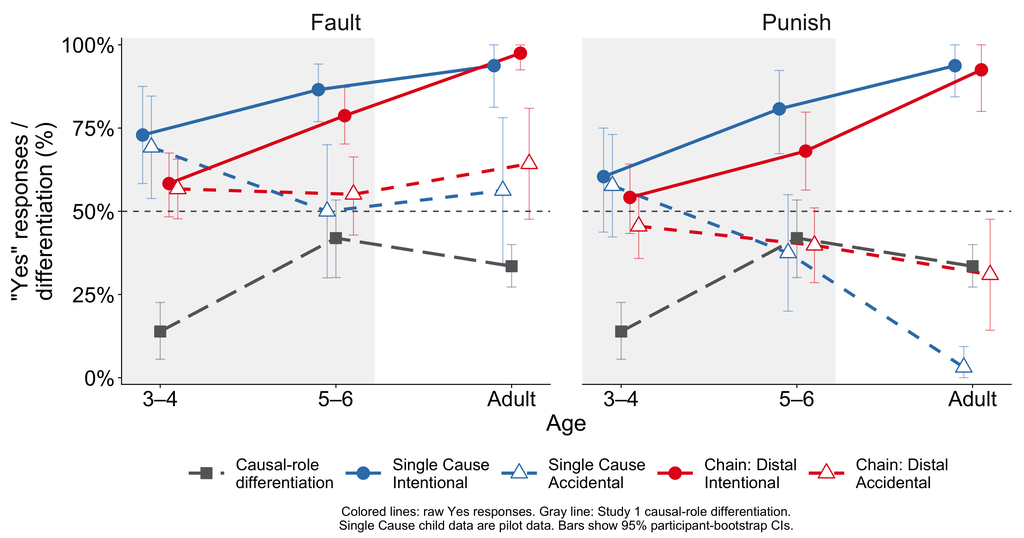

```r
binned_v2_labels = c("Causal-role\ndifferentiation", binned_series_labels)
binned_v2_colors = c("Causal-role differentiation" = "#666666", binned_series_colors)
binned_v2_fills = c("Causal-role differentiation" = "#666666", binned_series_fills)
binned_v2_shapes = c("Causal-role differentiation" = 22, binned_series_shapes)
binned_v2_lines = c("Causal-role differentiation" = "longdash", binned_series_lines)
binned_v2_offsets = setNames(c(0, -.10, -.05, .05, .10), binned_v2_series_order)
df.binned.responsibility.v2.plot = df.binned.responsibility.v2 %>%
  mutate(x_plot = x + unname(binned_v2_offsets[as.character(series)]))
p.binned.role.responsibility.v2 = ggplot(df.binned.responsibility.v2.plot,
                                        aes(x = x_plot, y = mean_pct, group = series)) +
  annotate("rect", xmin = -Inf, xmax = 2.22, ymin = -Inf, ymax = Inf,
           fill = talk_v2$childhood_fill, color = NA) +
  geom_hline(yintercept = 50, linetype = "dashed", linewidth = .95, color = "#555555") +
  geom_errorbar(aes(ymin = lower_pct, ymax = upper_pct, color = series),
                width = .055, linewidth = .65, alpha = .5, show.legend = FALSE) +
  geom_line(aes(color = series, linetype = series), linewidth = 2.1) +
  geom_point(aes(color = series, fill = series, shape = series), size = 7.2, stroke = 1.25) +
  facet_wrap(~ panel, nrow = 1) + binned_x_scale() +
  scale_y_continuous(limits = c(0, 100), breaks = seq(0, 100, 25),
                     labels = function(x) paste0(x, "%"), expand = expansion(add = 2)) +
  scale_color_manual(NULL, values = binned_v2_colors, limits = binned_v2_series_order, labels = binned_v2_labels) +
  scale_fill_manual(NULL, values = binned_v2_fills, limits = binned_v2_series_order, labels = binned_v2_labels) +
  scale_shape_manual(NULL, values = binned_v2_shapes, limits = binned_v2_series_order, labels = binned_v2_labels) +
  scale_linetype_manual(NULL, values = binned_v2_lines, limits = binned_v2_series_order, labels = binned_v2_labels) +
  labs(x = "Age", y = '\"Yes\" responses /\ndifferentiation (%)',
       caption = paste0("Colored lines: raw Yes responses. Gray line: Study 1 causal-role differentiation.\n",
                        "Single Cause child data are pilot data. Bars show 95% participant-bootstrap CIs.")) +
  binned_talk_theme +
  theme(legend.text = element_text(size = 23), legend.key.width = grid::unit(2.2, "cm"),
        plot.caption = element_text(size = 18, hjust = .5, margin = margin(t = 14))) +
  guides(color = guide_legend(nrow = 1), fill = guide_legend(nrow = 1),
         shape = guide_legend(nrow = 1), linetype = guide_legend(nrow = 1))
save_presentation_v2(p.binned.role.responsibility.v2,
                    file.path(binned_responsibility_output, "causal_role_and_raw_responsibility_talk_v2"),
                    width = 20, height = 10.5)
p.binned.role.responsibility.v2
```

## Confirm V1 identity and the duplicated reference

```r
df.binned.v2.checked = df.binned.responsibility.v2.values %>%
  mutate(source_panel = if_else(context == "Baseline", "Causal-role differentiation", as.character(panel))) %>%
  left_join(df.binned.responsibility.values %>% rename(source_panel = panel),
            by = c("source_panel", "study", "context", "condition", "population", "age_group", "quantity", "unit"),
            suffix = c("", "_v1"), relationship = "many-to-one")
binned_v2_built = ggplot_build(p.binned.role.responsibility.v2)
binned_v2_groups = as_tibble(binned_v2_built$data[[4]]) %>% count(PANEL, group)
binned_v2_reference = df.binned.responsibility.v2.values %>%
  filter(context == "Baseline") %>% select(panel, age_group, n, mean_pct, lower_pct, upper_pct)
stopifnot(nrow(df.binned.v2.checked) == 30L, !anyNA(df.binned.v2.checked),
          all(df.binned.v2.checked$n == df.binned.v2.checked$n_v1),
          all(df.binned.v2.checked$mean_pct == df.binned.v2.checked$mean_pct_v1),
          all(df.binned.v2.checked$lower_pct == df.binned.v2.checked$lower_pct_v1),
          all(df.binned.v2.checked$upper_pct == df.binned.v2.checked$upper_pct_v1),
          identical(filter(binned_v2_reference, panel == "Fault") %>% select(-panel),
                    filter(binned_v2_reference, panel == "Punish") %>% select(-panel)),
          nrow(binned_v2_built$layout$layout) == 2L,
          nrow(binned_v2_built$data[[5]]) == 30L, nrow(binned_v2_groups) == 10L,
          all(binned_v2_groups$n == 3L), all(binned_v2_built$data[[2]]$yintercept == 50),
          all(binned_v2_built$data[[3]]$ymin >= 0), all(binned_v2_built$data[[3]]$ymax <= 100),
          identical(binned_v2_built$layout$panel_params[[1]]$x.range,
                    binned_v2_built$layout$panel_params[[2]]$x.range),
          identical(binned_v2_built$layout$panel_params[[1]]$y.range,
                    binned_v2_built$layout$panel_params[[2]]$y.range))
```

The unchanged intervals describe each mean, not the separation between curves. An equal height of a differentiation score and a raw Yes rate does not imply that they measure the same construct. All existing pilot, adult-sample and unresolved scientific handoff limitations remain unchanged.

# Centered responsibility and a direct intention-effect comparison

These two new figures preserve all earlier versions and source data. Both use Fault/Punish panels and ages 3–4, 5–6 and Adult, with the same participant-first averaging and sample definitions as the binned raw-response figures. Single Cause child data remain **pilot data**. No participant is added or excluded.

## Center the five trajectories using the requested transformations

Start with the V2 percentages, not proportions on a 0–1 scale. For responsibility, subtract 50 from each Yes percentage. For Study 1 causal-role differentiation, divide the composite percentage-point score by 2, with no subtraction. Thus 0 means either 50/50 responding or no causal-role differentiation. Perfect expected role differentiation (+100 before scaling) and 100% Yes both map to +50. A negative differentiation score, if present, would mean the reverse expected role mapping; a negative responsibility value means less than 50% Yes.

Apply the **same positive linear transformation to both confidence limits**. This preserves the original 95% percentile-bootstrap coverage and requires no new bootstrap draws. The raw means and bounds remain in the exported table beside the transformed values. The two quantities retain different substantive meanings even though their numeric ranges and chosen zero points now align.

```r
df.binned.centered = df.binned.responsibility.v2 %>%
  mutate(transformation = if_else(context == "Baseline", "Differentiation (%) / 2", "Yes (%) - 50"),
         centered_mean = if_else(context == "Baseline", mean_pct / 2, mean_pct - 50),
         centered_lower = if_else(context == "Baseline", lower_pct / 2, lower_pct - 50),
         centered_upper = if_else(context == "Baseline", upper_pct / 2, upper_pct - 50),
         x_plot = x + unname(binned_v2_offsets[as.character(series)]))
df.binned.centered.values = df.binned.centered %>%
  mutate(age_group = binned_age_labels[as.integer(stage)]) %>%
  select(panel, series, study, context, condition, population, age_group, n,
         quantity, unit, mean_pct, lower_pct, upper_pct, transformation,
         centered_mean, centered_lower, centered_upper)
write_csv(df.binned.centered.values,
          file.path(binned_responsibility_output, "causal_role_and_raw_responsibility_centered_talk_v1_values.csv"))
kable(select(df.binned.centered.values, panel, series, age_group, n,
              transformation, centered_mean, centered_lower, centered_upper), digits = 3,
      caption = "Centered comparison: transformed means and 95% participant-bootstrap CIs")
```

Centered comparison: transformed means and 95% participant-bootstrap CIs

| panel | series | age_group | n | transformation | centered_mean | centered_lower | centered_upper |
| --- | --- | --- | --- | --- | --- | --- | --- |
| Fault | Causal-role differentiation | 3–4 | 63 | Differentiation (%) / 2 | 6.944 | 2.778 | 11.310 |
| Fault | Causal-role differentiation | 5–6 | 59 | Differentiation (%) / 2 | 20.975 | 15.042 | 26.695 |
| Fault | Causal-role differentiation | Adult | 100 | Differentiation (%) / 2 | 16.750 | 13.625 | 20.000 |
| Fault | Single Cause Intentional | 3–4 | 24 | Yes (%) - 50 | 22.917 | 8.333 | 37.500 |
| Fault | Single Cause Intentional | 5–6 | 26 | Yes (%) - 50 | 36.538 | 26.923 | 44.231 |
| Fault | Single Cause Intentional | Adult | 16 | Yes (%) - 50 | 43.750 | 31.250 | 50.000 |
| Fault | Single Cause Accidental | 3–4 | 26 | Yes (%) - 50 | 19.231 | 3.846 | 34.615 |
| Fault | Single Cause Accidental | 5–6 | 20 | Yes (%) - 50 | 0.000 | -20.000 | 20.000 |
| Fault | Single Cause Accidental | Adult | 16 | Yes (%) - 50 | 6.250 | -15.625 | 28.125 |
| Fault | Chain: Distal Intentional | 3–4 | 60 | Yes (%) - 50 | 8.333 | -1.667 | 17.500 |
| Fault | Chain: Distal Intentional | 5–6 | 47 | Yes (%) - 50 | 28.723 | 20.213 | 37.234 |
| Fault | Chain: Distal Intentional | Adult | 20 | Yes (%) - 50 | 47.500 | 42.500 | 50.000 |
| Fault | Chain: Distal Accidental | 3–4 | 67 | Yes (%) - 50 | 6.716 | -2.239 | 15.672 |
| Fault | Chain: Distal Accidental | 5–6 | 49 | Yes (%) - 50 | 5.102 | -7.143 | 16.327 |
| Fault | Chain: Distal Accidental | Adult | 21 | Yes (%) - 50 | 14.286 | -2.381 | 30.952 |
| Punish | Causal-role differentiation | 3–4 | 63 | Differentiation (%) / 2 | 6.944 | 2.778 | 11.310 |
| Punish | Causal-role differentiation | 5–6 | 59 | Differentiation (%) / 2 | 20.975 | 15.042 | 26.695 |
| Punish | Causal-role differentiation | Adult | 100 | Differentiation (%) / 2 | 16.750 | 13.625 | 20.000 |
| Punish | Single Cause Intentional | 3–4 | 24 | Yes (%) - 50 | 10.417 | -6.250 | 25.000 |
| Punish | Single Cause Intentional | 5–6 | 26 | Yes (%) - 50 | 30.769 | 17.308 | 42.308 |
| Punish | Single Cause Intentional | Adult | 16 | Yes (%) - 50 | 43.750 | 34.375 | 50.000 |
| Punish | Single Cause Accidental | 3–4 | 26 | Yes (%) - 50 | 7.692 | -7.692 | 23.077 |
| Punish | Single Cause Accidental | 5–6 | 20 | Yes (%) - 50 | -12.500 | -30.000 | 5.000 |
| Punish | Single Cause Accidental | Adult | 16 | Yes (%) - 50 | -46.875 | -50.000 | -40.625 |
| Punish | Chain: Distal Intentional | 3–4 | 60 | Yes (%) - 50 | 4.167 | -6.667 | 14.167 |
| Punish | Chain: Distal Intentional | 5–6 | 47 | Yes (%) - 50 | 18.085 | 6.383 | 29.787 |
| Punish | Chain: Distal Intentional | Adult | 20 | Yes (%) - 50 | 42.500 | 30.000 | 50.000 |
| Punish | Chain: Distal Accidental | 3–4 | 67 | Yes (%) - 50 | -4.478 | -14.179 | 5.224 |
| Punish | Chain: Distal Accidental | 5–6 | 49 | Yes (%) - 50 | -10.204 | -21.429 | 1.020 |
| Punish | Chain: Distal Accidental | Adult | 21 | Yes (%) - 50 | -19.048 | -35.714 | -2.381 |

The centered main plot keeps the five-trajectory mapping from V2. A strong zero reference replaces the 50% reference. The common −50% to 50% range includes all transformed means and CI bounds, without clipping. The caption gives the exact transformations and explains zero directly on the figure.

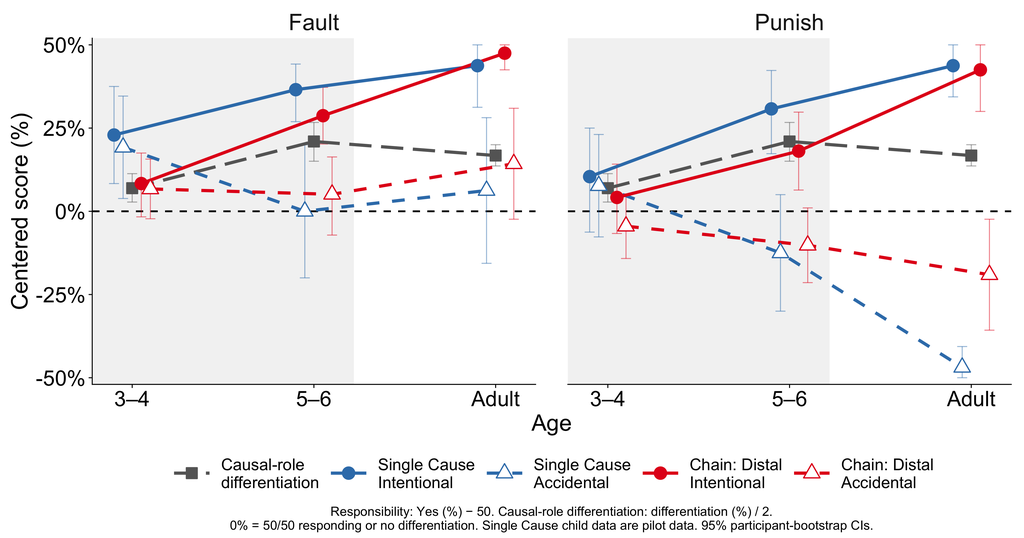

```r
p.binned.centered = ggplot(df.binned.centered,
                           aes(x = x_plot, y = centered_mean, group = series)) +
  annotate("rect", xmin = -Inf, xmax = 2.22, ymin = -Inf, ymax = Inf,
           fill = talk_v2$childhood_fill, color = NA) +
  geom_hline(yintercept = 0, linetype = "dashed", linewidth = 1.2, color = "black") +
  geom_errorbar(aes(ymin = centered_lower, ymax = centered_upper, color = series),
                width = .055, linewidth = .65, alpha = .5, show.legend = FALSE) +
  geom_line(aes(color = series, linetype = series), linewidth = 2.1) +
  geom_point(aes(color = series, fill = series, shape = series), size = 7.2, stroke = 1.25) +
  facet_wrap(~ panel, nrow = 1) + binned_x_scale() +
  scale_y_continuous(limits = c(-50, 50), breaks = seq(-50, 50, 25),
                     labels = function(x) paste0(x, "%"), expand = expansion(add = 2)) +
  scale_color_manual(NULL, values = binned_v2_colors, limits = binned_v2_series_order, labels = binned_v2_labels) +
  scale_fill_manual(NULL, values = binned_v2_fills, limits = binned_v2_series_order, labels = binned_v2_labels) +
  scale_shape_manual(NULL, values = binned_v2_shapes, limits = binned_v2_series_order, labels = binned_v2_labels) +
  scale_linetype_manual(NULL, values = binned_v2_lines, limits = binned_v2_series_order, labels = binned_v2_labels) +
  labs(x = "Age", y = "Centered score (%)",
       caption = paste0("Responsibility: Yes (%) − 50. Causal-role differentiation: differentiation (%) / 2.\n",
                        "0% = 50/50 responding or no differentiation. Single Cause child data are pilot data. 95% participant-bootstrap CIs.")) +
  binned_talk_theme +
  theme(legend.text = element_text(size = 23), legend.key.width = grid::unit(2.2, "cm"),
        plot.caption = element_text(size = 18, hjust = .5, margin = margin(t = 14))) +
  guides(color = guide_legend(nrow = 1), fill = guide_legend(nrow = 1),
         shape = guide_legend(nrow = 1), linetype = guide_legend(nrow = 1))
save_presentation_v2(p.binned.centered,
                    file.path(binned_responsibility_output, "causal_role_and_raw_responsibility_centered_talk_v1"),
                    width = 20, height = 10.5)
p.binned.centered
```

## Compare intention-effect magnitudes directly

The separate backup contains exactly two trajectories per panel: Single Cause and Chain: Distal. Each value is **100 × (Intentional mean Yes − Accidental mean Yes)**, after participant-level scenario averaging. Conditions contain different people; this is a difference of group means, not a within-person subtraction.

Reuse the 12 matching estimates and CIs from `df.context.sensitivity.summary`, computed earlier in this workflow. Those CIs use 5,000 bootstrap replicates, independently resampling whole participants within each stage and condition. The difference is calculated in every replicate, so its interval includes uncertainty in both condition means. **Do not subtract raw-response CI bounds.** Single Cause uses the existing seed `bootstrap_seed + 10`; chain uses `bootstrap_seed + 12`, retaining each participant’s judgments together.

```r
binned_effect_context_order = c("Single Cause", "Chain: Distal")
df.binned.intention.effects = df.context.sensitivity.summary %>%
  filter(measure %in% c("Fault", "Punish"), context %in% binned_effect_context_order) %>%
  mutate(panel = factor(as.character(measure), levels = c("Fault", "Punish")),
         context = factor(context, levels = binned_effect_context_order), x = as.integer(stage)) %>%
  arrange(panel, context, stage)
df.binned.intention.effect.values = df.binned.intention.effects %>%
  mutate(age_group = binned_age_labels[as.integer(stage)]) %>%
  select(panel, study, context, age_group, contrast,
         eligible_n_Intentional, eligible_n_Accidental, n_Intentional, n_Accidental,
         yes_mean_Intentional, yes_mean_Accidental, mean_pp, lower_pp, upper_pp)
write_csv(df.binned.intention.effect.values,
          file.path(binned_responsibility_output, "single_cause_vs_chain_distal_intention_effect_talk_v1_values.csv"))
kable(select(df.binned.intention.effect.values, panel, context, age_group, n_Intentional,
              n_Accidental, mean_pp, lower_pp, upper_pp), digits = 3,
      caption = "Direct intention effects: percentage-point differences and 95% participant-bootstrap CIs")
```

Direct intention effects: percentage-point differences and 95% participant-bootstrap CIs

| panel | context | age_group | n_Intentional | n_Accidental | mean_pp | lower_pp | upper_pp |
| --- | --- | --- | --- | --- | --- | --- | --- |
| Fault | Single Cause | 3–4 | 24 | 26 | 3.686 | -16.831 | 25.164 |
| Fault | Single Cause | 5–6 | 26 | 20 | 36.538 | 13.846 | 59.038 |
| Fault | Single Cause | Adult | 16 | 16 | 37.500 | 12.500 | 62.500 |
| Fault | Chain: Distal | 3–4 | 60 | 67 | 1.617 | -11.940 | 14.428 |
| Fault | Chain: Distal | 5–6 | 47 | 49 | 23.621 | 8.814 | 38.081 |
| Fault | Chain: Distal | Adult | 20 | 21 | 33.214 | 16.027 | 50.000 |
| Punish | Single Cause | 3–4 | 24 | 26 | 2.724 | -20.994 | 25.962 |
| Punish | Single Cause | 5–6 | 26 | 20 | 43.269 | 22.303 | 63.269 |
| Punish | Single Cause | Adult | 16 | 16 | 90.625 | 81.250 | 100.000 |
| Punish | Chain: Distal | 3–4 | 60 | 67 | 8.644 | -5.659 | 22.948 |
| Punish | Chain: Distal | 5–6 | 47 | 49 | 28.289 | 11.702 | 43.856 |
| Punish | Chain: Distal | Adult | 20 | 21 | 61.548 | 41.902 | 80.714 |

The backup retains blue for Single Cause and red for Chain: Distal, with two solid lines and distinct large filled markers. It has no baseline trajectory and no condition-specific raw-response lines. Both panels share a scale that includes every difference CI. The zero line means no Intentional–Accidental difference, rather than the neutral-response interpretation of the centered plot.

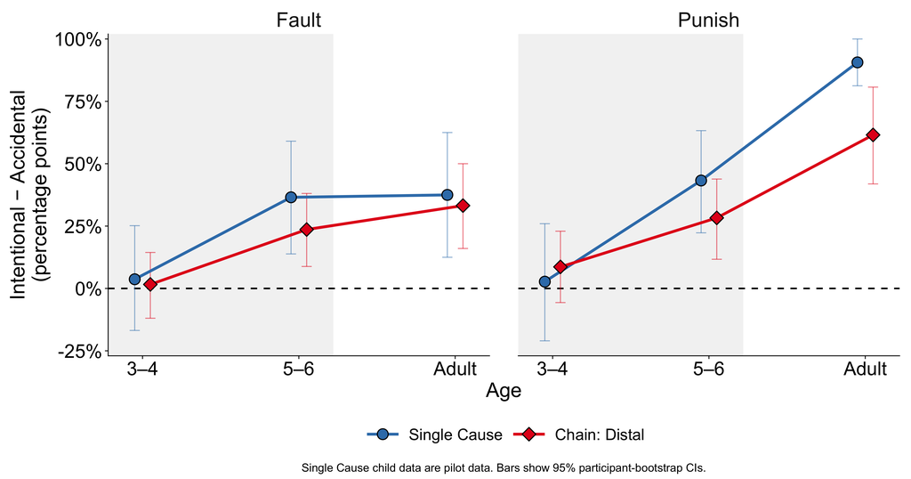

```r
binned_effect_colors = binned_context_colors[binned_effect_context_order]
binned_effect_shapes = setNames(c(21, 23), binned_effect_context_order)
binned_effect_offsets = setNames(c(-.05, .05), binned_effect_context_order)
binned_effect_limits = c(25 * floor(min(0, df.binned.intention.effects$lower_pp) / 25),
                         25 * ceiling(max(0, df.binned.intention.effects$upper_pp) / 25))
df.binned.intention.effect.plot = df.binned.intention.effects %>%
  mutate(x_plot = x + unname(binned_effect_offsets[as.character(context)]))
p.binned.intention.effects = ggplot(df.binned.intention.effect.plot,
                                    aes(x = x_plot, y = mean_pp, group = context)) +
  annotate("rect", xmin = -Inf, xmax = 2.22, ymin = -Inf, ymax = Inf,
           fill = talk_v2$childhood_fill, color = NA) +
  geom_hline(yintercept = 0, linetype = "dashed", linewidth = 1.2, color = "black") +
  geom_errorbar(aes(ymin = lower_pp, ymax = upper_pp, color = context),
                width = .065, linewidth = .7, alpha = .55, show.legend = FALSE) +
  geom_line(aes(color = context), linewidth = 2.1) +
  geom_point(aes(fill = context, shape = context), color = "black", size = 7.2, stroke = 1.2) +
  facet_wrap(~ panel, nrow = 1) + binned_x_scale() +
  scale_y_continuous(limits = binned_effect_limits, breaks = seq(binned_effect_limits[1], binned_effect_limits[2], 25),
                     labels = function(x) paste0(x, "%"), expand = expansion(add = 2)) +
  scale_color_manual(NULL, values = binned_effect_colors, limits = binned_effect_context_order) +
  scale_fill_manual(NULL, values = binned_effect_colors, limits = binned_effect_context_order) +
  scale_shape_manual(NULL, values = binned_effect_shapes, limits = binned_effect_context_order) +
  labs(x = "Age", y = "Intentional − Accidental\n(percentage points)",
       caption = "Single Cause child data are pilot data. Bars show 95% participant-bootstrap CIs.") +
  binned_talk_theme +
  theme(legend.text = element_text(size = 25), legend.key.width = grid::unit(2.2, "cm"),
        plot.caption = element_text(size = 18, hjust = .5, margin = margin(t = 14))) +
  guides(color = guide_legend(nrow = 1), fill = guide_legend(nrow = 1), shape = guide_legend(nrow = 1))
save_presentation_v2(p.binned.intention.effects,
                    file.path(binned_responsibility_output, "single_cause_vs_chain_distal_intention_effect_talk_v1"),
                    width = 20, height = 10.5)
p.binned.intention.effects
```

## Verify transformations, source contrasts and panel structure

```r
# Inverse-transform both means and interval limits to recover the source exactly.
for (pair in list(c("mean_pct", "centered_mean"), c("lower_pct", "centered_lower"), c("upper_pct", "centered_upper"))) {
  original = df.binned.centered[[pair[1]]]
  centered = df.binned.centered[[pair[2]]]
  recovered = if_else(df.binned.centered$context == "Baseline", 2 * centered, centered + 50)
  stopifnot(all(abs(recovered - original) < 1e-12))
}
df.binned.effect.source = df.binned.responsibility %>%
  select(panel, study, context, stage, condition, mean_pct, n) %>%
  pivot_wider(names_from = condition, values_from = c(mean_pct, n)) %>%
  inner_join(df.binned.intention.effects, by = c("panel", "study", "context", "stage"),
             suffix = c("_raw", "_effect"), relationship = "one-to-one")
centered_built = ggplot_build(p.binned.centered)
effect_built = ggplot_build(p.binned.intention.effects)
centered_groups = as_tibble(centered_built$data[[4]]) %>% count(PANEL, group)
effect_groups = as_tibble(effect_built$data[[4]]) %>% count(PANEL, group)
stopifnot(nrow(df.binned.centered) == 30L, nrow(df.binned.intention.effects) == 12L,
          nrow(df.binned.effect.source) == 12L,
          all(abs(df.binned.effect.source$mean_pp - (df.binned.effect.source$mean_pct_Intentional -
                                                    df.binned.effect.source$mean_pct_Accidental)) < 1e-10),
          all(df.binned.effect.source$n_Intentional_raw == df.binned.effect.source$n_Intentional_effect),
          all(df.binned.effect.source$n_Accidental_raw == df.binned.effect.source$n_Accidental_effect),
          all(df.binned.centered$centered_lower >= -50), all(df.binned.centered$centered_upper <= 50),
          nrow(centered_built$data[[5]]) == 30L, nrow(centered_groups) == 10L, all(centered_groups$n == 3L),
          nrow(effect_built$data[[5]]) == 12L, nrow(effect_groups) == 4L, all(effect_groups$n == 3L),
          all(centered_built$data[[2]]$yintercept == 0), all(effect_built$data[[2]]$yintercept == 0),
          all(effect_built$data[[3]]$ymin >= binned_effect_limits[1]),
          all(effect_built$data[[3]]$ymax <= binned_effect_limits[2]))
for (built in list(centered_built, effect_built)) {
  stopifnot(nrow(built$layout$layout) == 2L,
            identical(built$layout$panel_params[[1]]$x.range, built$layout$panel_params[[2]]$x.range),
            identical(built$layout$panel_params[[1]]$y.range, built$layout$panel_params[[2]]$y.range))
}
```

These are descriptive cross-sample comparisons. The larger estimated Single Cause intention effects at ages 5–6 and in adult punishment are visible directly in the backup; at ages 3–4, punishment instead has the larger Chain: Distal estimate. The displayed pointwise CIs do not test whether the two context effects differ. Adult chain points remain from the available Study 2 pilot, the main adult dataset remains missing, and the Single Cause historical N=30 subset remains unidentified. All original scientific handoff gaps remain unresolved.

# Raw-response V1 builds with intentionality-gap shading

This new build series uses the original three-panel `causal_role_and_raw_responsibility_talk_v1`: causal-role differentiation, Fault and Punish. It does not use the centered or two-panel versions. Every estimate, CI, color, axis, label, marker, line width and horizontal offset stays unchanged. The 25 × 11 inch canvas, childhood shading, caption and full legend remain fixed, even in the blank scaffold. Only trajectory visibility and the two requested translucent fills change. Each reveal includes all three ages and its existing confidence intervals; there is no new analysis or resampling.

## Reveal one complete trajectory at a time

Keep all data rows in every plot. Hide unrevealed marks with zero opacity so facets, scale training and the legend never depend on which series is visible. Copy the original drawing layers before changing their opacity; the original plots remain unchanged. The legend always shows the complete original key.

```r
binned_gap_build_output = file.path(binned_responsibility_output, "builds",
                                    "causal_role_and_raw_responsibility_talk_v1_gap_reveal")
dir.create(binned_gap_build_output, recursive = TRUE, showWarnings = FALSE)
binned_gap_reveals = tibble(
  reveal_step = 2:9,
  panel = rep(c("Fault", "Punish"), 4),
  context = rep(c("Single Cause", "Chain: Distal", "Single Cause", "Chain: Distal"), each = 2),
  condition = rep(c("Intentional", "Accidental"), each = 4))
df.binned.gap.reveal = df.binned.responsibility.plot %>%
  left_join(binned_gap_reveals, by = c("panel", "context", "condition"), relationship = "many-to-one")
stopifnot(nrow(df.binned.gap.reveal) == 24L, !anyNA(df.binned.gap.reveal$reveal_step))
binned_gap_build_names = c(
  "build00_blank", "build01_causal_role_differentiation",
  "build02_single_cause_intentional_fault", "build03_single_cause_intentional_punish",
  "build04_chain_distal_intentional_fault", "build05_chain_distal_intentional_punish",
  "build06_single_cause_accidental_fault", "build07_single_cause_accidental_punish",
  "build08_chain_distal_accidental_fault", "build09_chain_distal_accidental_punish",
  "build10_single_cause_gap_fill", "build11_add_chain_distal_gap_fill_full")
df.binned.gap.build.manifest = tibble(
  build = 0:11, filename = binned_gap_build_names,
  added = c("Blank scaffold", "Causal-role differentiation",
    paste(binned_gap_reveals$context, binned_gap_reveals$condition, binned_gap_reveals$panel, sep = " / "),
    "Single Cause gap shading in both responsibility panels",
    "Chain: Distal gap shading in both responsibility panels"),
  visible_trajectories = c(0:9, 9L, 9L), visible_points = 3L * visible_trajectories,
  single_cause_fill_alpha = if_else(build >= 10L, .18, 0),
  chain_distal_fill_alpha = if_else(build >= 11L, .18, 0))
write_csv(df.binned.gap.build.manifest, file.path(binned_gap_build_output, "build_manifest.csv"))

# Follow the actual plotted x offsets, rather than moving the curves to a common x.
# Each polygon traces Intentional forward and Accidental backward, closing at the ends.
df.binned.gap.polygons = df.binned.responsibility.plot %>%
  group_by(panel, context) %>% group_modify(function(rows, keys) {
    bind_rows(filter(rows, condition == "Intentional") %>% arrange(x_plot),
              filter(rows, condition == "Accidental") %>% arrange(desc(x_plot)))
  }) %>% ungroup()
stopifnot(nrow(df.binned.gap.polygons) == 24L)

binned_mark_visibility = function(plot, values, visible) {
  for (layer_number in 3:5) { # Existing CI, line and point layers.
    layer = local({
      source_layer = plot$layers[[layer_number]]
      ggplot2::ggproto(NULL, source_layer)
    })
    original_alpha = layer$aes_params$alpha
    if (is.null(original_alpha)) original_alpha = 1
    layer$data = mutate(values, build_alpha = original_alpha * as.numeric(visible))
    layer$mapping$alpha = aes(alpha = build_alpha)$alpha
    layer$aes_params$alpha = NULL
    plot$layers[[layer_number]] = layer
  }
  plot + scale_alpha_identity(guide = "none")
}

make_binned_raw_gap_build = function(step) {
  stopifnot(step %in% 0:11)
  baseline = binned_mark_visibility(p.binned.baseline, df.binned.baseline, step >= 1L)
  responsibility = binned_mark_visibility(p.binned.raw.responsibility, df.binned.gap.reveal,
                                           df.binned.gap.reveal$reveal_step <= step) +
    guides(color = guide_legend(nrow = 1, override.aes = list(alpha = 1)))
  blue_fill = geom_polygon(data = filter(df.binned.gap.polygons, context == "Single Cause"),
    aes(x = x_plot, y = mean_pct, group = panel), inherit.aes = FALSE,
    fill = binned_context_colors[["Single Cause"]], color = NA,
    alpha = if (step >= 10L) .18 else 0, show.legend = FALSE)
  red_fill = geom_polygon(data = filter(df.binned.gap.polygons, context == "Chain: Distal"),
    aes(x = x_plot, y = mean_pct, group = panel), inherit.aes = FALSE,
    fill = binned_context_colors[["Chain: Distal"]], color = NA,
    alpha = if (step >= 11L) .18 else 0, show.legend = FALSE)
  # Childhood background, blue fill, red fill, then reference line, CIs, lines and points.
  responsibility$layers = append(responsibility$layers, list(blue_fill, red_fill), after = 1L)
  full = patchwork::wrap_plots(baseline, responsibility, widths = c(1, 2), guides = "collect") +
    p.binned.role.responsibility$patches$annotation & theme(legend.position = "bottom")
  list(plot = full, baseline = baseline, responsibility = responsibility)
}
```

The fill uses the mean trajectories, not CI bounds. Its opacity is 0.18. Blue appears in Build 10; red overlays blue transparently in Build 11. Both fills sit behind the reference line, CIs, trajectories and points. The sloping end edges join the original offset markers at the first and last age categories. The areas illustrate the displayed separation; they are not additional estimates or tests.

## Save the fixed-layout sequence and verify identity

```r
binned_gap_source_baseline = ggplot_build(p.binned.baseline)
binned_gap_source_responsibility = ggplot_build(p.binned.raw.responsibility)
p.binned.gap.builds = lapply(0:11, function(step) {
  build = make_binned_raw_gap_build(step)
  baseline_built = ggplot_build(build$baseline)
  raw_built = ggplot_build(build$responsibility)
  # The only changed property of an existing mark is visibility (alpha).
  for (layer_number in 3:5) {
    stopifnot(identical(select(baseline_built$data[[layer_number]], -alpha),
                        select(binned_gap_source_baseline$data[[layer_number]], -alpha)),
              identical(select(raw_built$data[[layer_number + 2L]], -alpha),
                        select(binned_gap_source_responsibility$data[[layer_number]], -alpha)))
  }
  stopifnot(sum(baseline_built$data[[5]]$alpha > 0) == if (step >= 1L) 3L else 0L,
            sum(raw_built$data[[7]]$alpha > 0) == 3L * min(8L, max(0L, step - 1L)),
            all(raw_built$data[[2]]$alpha == if (step >= 10L) .18 else 0),
            all(raw_built$data[[3]]$alpha == if (step >= 11L) .18 else 0))
  for (pair in list(list(baseline_built, binned_gap_source_baseline),
                   list(raw_built, binned_gap_source_responsibility))) {
    for (panel_number in seq_along(pair[[1]]$layout$panel_params)) {
      current = pair[[1]]$layout$panel_params[[panel_number]]
      source = pair[[2]]$layout$panel_params[[panel_number]]
      stopifnot(identical(current$x.range, source$x.range), identical(current$y.range, source$y.range),
                identical(current$x$breaks, source$x$breaks), identical(current$y$breaks, source$y$breaks),
                identical(current$x$get_labels(), source$x$get_labels()),
                identical(current$y$get_labels(), source$y$get_labels()))
    }
  }
  save_presentation_v2(build$plot, file.path(binned_gap_build_output, binned_gap_build_names[step + 1L]),
                       width = 25, height = 11)
  build
})
# The helper must not mutate the source plots or their data.
stopifnot(identical(ggplot_build(p.binned.baseline)$data, binned_gap_source_baseline$data),
          identical(ggplot_build(p.binned.raw.responsibility)$data, binned_gap_source_responsibility$data))
kable(df.binned.gap.build.manifest, caption = "Raw-response V1: cumulative reveals and final gap shading")
```

Raw-response V1: cumulative reveals and final gap shading

| build | filename | added | visible_trajectories | visible_points | single_cause_fill_alpha | chain_distal_fill_alpha |
| --- | --- | --- | --- | --- | --- | --- |
| 0 | build00_blank | Blank scaffold | 0 | 0 | 0.00 | 0.00 |
| 1 | build01_causal_role_differentiation | Causal-role differentiation | 1 | 3 | 0.00 | 0.00 |
| 2 | build02_single_cause_intentional_fault | Single Cause / Intentional / Fault | 2 | 6 | 0.00 | 0.00 |
| 3 | build03_single_cause_intentional_punish | Single Cause / Intentional / Punish | 3 | 9 | 0.00 | 0.00 |
| 4 | build04_chain_distal_intentional_fault | Chain: Distal / Intentional / Fault | 4 | 12 | 0.00 | 0.00 |
| 5 | build05_chain_distal_intentional_punish | Chain: Distal / Intentional / Punish | 5 | 15 | 0.00 | 0.00 |
| 6 | build06_single_cause_accidental_fault | Single Cause / Accidental / Fault | 6 | 18 | 0.00 | 0.00 |
| 7 | build07_single_cause_accidental_punish | Single Cause / Accidental / Punish | 7 | 21 | 0.00 | 0.00 |
| 8 | build08_chain_distal_accidental_fault | Chain: Distal / Accidental / Fault | 8 | 24 | 0.00 | 0.00 |
| 9 | build09_chain_distal_accidental_punish | Chain: Distal / Accidental / Punish | 9 | 27 | 0.00 | 0.00 |
| 10 | build10_single_cause_gap_fill | Single Cause gap shading in both responsibility panels | 9 | 27 | 0.18 | 0.00 |
| 11 | build11_add_chain_distal_gap_fill_full | Chain: Distal gap shading in both responsibility panels | 9 | 27 | 0.18 | 0.18 |

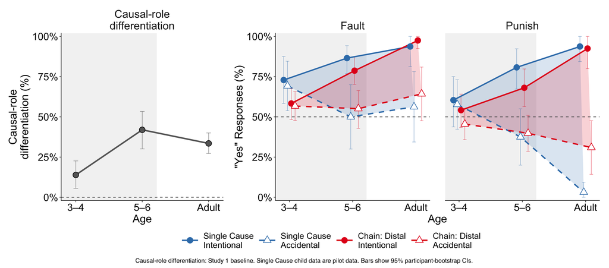

```r
p.binned.gap.builds[[12]]$plot
```

Build 09 contains all original marks with no gap fill and is checked against the original rendered PNG. Every build retains identical scaffold geometry. Existing V1/V2, centered figures, source data and handoff limitations are preserved. The Single Cause child pilot note and Study 1 baseline attribution remain in the original caption throughout the series.

# Centered two-panel builds with intentionality-gap shading

This additional series uses **`causal_role_and_raw_responsibility_centered_talk_v1`** as its exact base. It has only **Fault | Punish**, with the gray Study 1 causal-role differentiation trajectory inside both panels. The preceding three-panel raw-response series is preserved separately and is not used as the base here. No data, scoring, estimates or confidence intervals change.

Reuse `p.binned.centered` directly, including its 20 × 10.5 inch canvas, centered scale, limits, childhood shading, offsets, colors, shapes, typography, panel spacing, caption and bottom legend. Keep every data row in every build, changing only the visibility of marks. Build 09 is an exact copy of the existing centered PDF and PNG. Builds 10 and 11 add the two requested fills behind all marks.

## Centered reveal order and mean-gap boundaries

```r
centered_gap_build_output = file.path(binned_responsibility_output, "builds",
                                      "causal_role_and_raw_responsibility_centered_talk_v1_gap_reveal")
dir.create(centered_gap_build_output, recursive = TRUE, showWarnings = FALSE)
centered_gap_reveals = tibble(
  reveal_step = 2:9,
  panel = rep(c("Fault", "Punish"), 4),
  context = rep(c("Single Cause", "Chain: Distal", "Single Cause", "Chain: Distal"), each = 2),
  condition = rep(c("Intentional", "Accidental"), each = 4))
df.centered.gap.reveal = df.binned.centered %>%
  left_join(centered_gap_reveals, by = c("panel", "context", "condition"), relationship = "many-to-one") %>%
  mutate(reveal_step = if_else(context == "Baseline", 1L, reveal_step))
stopifnot(nrow(df.centered.gap.reveal) == 30L, !anyNA(df.centered.gap.reveal$reveal_step))
centered_gap_build_names = c(
  "build00_blank", "build01_causal_role_differentiation_both_panels",
  "build02_single_cause_intentional_fault", "build03_single_cause_intentional_punish",
  "build04_chain_distal_intentional_fault", "build05_chain_distal_intentional_punish",
  "build06_single_cause_accidental_fault", "build07_single_cause_accidental_punish",
  "build08_chain_distal_accidental_fault", "build09_centered_original_complete",
  "build10_single_cause_gap_fill", "build11_add_chain_distal_gap_fill_full")
df.centered.gap.build.manifest = tibble(
  build = 0:11, filename = centered_gap_build_names,
  added = c("Blank centered two-panel scaffold", "Causal-role differentiation in both panels",
    paste(centered_gap_reveals$context, centered_gap_reveals$condition, centered_gap_reveals$panel, sep = " / "),
    "Single Cause gap shading in both panels", "Chain: Distal gap shading in both panels"),
  visible_trajectories = c(0L, 2:10, 10L, 10L), visible_points = 3L * visible_trajectories,
  single_cause_fill_alpha = if_else(build >= 10L, .18, 0),
  chain_distal_fill_alpha = if_else(build >= 11L, .18, 0))
write_csv(df.centered.gap.build.manifest, file.path(centered_gap_build_output, "build_manifest.csv"))

# Trace the centered plot's actual means and offsets; baseline is never part of a fill.
df.centered.gap.polygons = df.binned.centered %>% filter(context != "Baseline") %>%
  group_by(panel, context) %>% group_modify(function(rows, keys) {
    bind_rows(filter(rows, condition == "Intentional") %>% arrange(x_plot),
              filter(rows, condition == "Accidental") %>% arrange(desc(x_plot)))
  }) %>% ungroup()
stopifnot(nrow(df.centered.gap.polygons) == 24L,
          setequal(as.character(df.centered.gap.polygons$panel), c("Fault", "Punish")))

make_centered_gap_build = function(step) {
  stopifnot(step %in% 0:11)
  # Copy existing layers and change opacity only; reuse the source plot's complete theme.
  plot = binned_mark_visibility(p.binned.centered, df.centered.gap.reveal,
                                df.centered.gap.reveal$reveal_step <= step) +
    guides(color = guide_legend(nrow = 1, override.aes = list(alpha = 1)))
  blue_fill = geom_polygon(data = filter(df.centered.gap.polygons, context == "Single Cause"),
    aes(x = x_plot, y = centered_mean, group = panel), inherit.aes = FALSE,
    fill = binned_context_colors[["Single Cause"]], color = NA,
    alpha = if (step >= 10L) .18 else 0, show.legend = FALSE)
  red_fill = geom_polygon(data = filter(df.centered.gap.polygons, context == "Chain: Distal"),
    aes(x = x_plot, y = centered_mean, group = panel), inherit.aes = FALSE,
    fill = binned_context_colors[["Chain: Distal"]], color = NA,
    alpha = if (step >= 11L) .18 else 0, show.legend = FALSE)
  # Keep the original background first, then blue, red, zero line, CIs, lines and points.
  plot$layers = append(plot$layers, list(blue_fill, red_fill), after = 1L)
  plot
}
```

Both fills have alpha 0.18. Each follows its original centered Intentional and Accidental mean trajectories, including their fixed horizontal offsets. Blue appears first; red then overlays blue transparently. The fills are not CI bands or new estimates, and do not alter either centered transformation. The original pilot-data note and explanation of the common zero remain visible throughout.

## Export all builds and verify the exact centered base

```r
centered_gap_source = ggplot_build(p.binned.centered)
p.centered.gap.builds = lapply(0:11, function(step) {
  plot = make_centered_gap_build(step)
  built = ggplot_build(plot)
  stopifnot(nrow(built$layout$layout) == 2L,
            identical(as.character(built$layout$layout$panel), c("Fault", "Punish")))
  for (layer_number in 3:5) {
    stopifnot(identical(select(built$data[[layer_number + 2L]], -alpha),
                        select(centered_gap_source$data[[layer_number]], -alpha)))
  }
  stopifnot(identical(built$data[[7]]$alpha, as.numeric(df.centered.gap.reveal$reveal_step <= step)),
            sum(built$data[[7]]$alpha > 0) == df.centered.gap.build.manifest$visible_points[step + 1L],
            all(built$data[[2]]$alpha == if (step >= 10L) .18 else 0),
            all(built$data[[3]]$alpha == if (step >= 11L) .18 else 0))
  for (panel_number in 1:2) {
    current = built$layout$panel_params[[panel_number]]
    source = centered_gap_source$layout$panel_params[[panel_number]]
    stopifnot(identical(current$x.range, source$x.range), identical(current$y.range, source$y.range),
              identical(current$x$breaks, source$x$breaks), identical(current$y$breaks, source$y$breaks),
              identical(current$x$get_labels(), source$x$get_labels()),
              identical(current$y$get_labels(), source$y$get_labels()))
  }
  destination = file.path(centered_gap_build_output, centered_gap_build_names[step + 1L])
  if (step == 9L) {
    # Preserve even the original PDF metadata and PNG encoding in this exact-base frame.
    source = file.path(binned_responsibility_output, "causal_role_and_raw_responsibility_centered_talk_v1")
    for (extension in c(".pdf", ".png")) {
      stopifnot(file.copy(paste0(source, extension), paste0(destination, extension), overwrite = TRUE))
    }
  } else save_presentation_v2(plot, destination, width = 20, height = 10.5)
  plot
})
stopifnot(identical(ggplot_build(p.binned.centered)$data, centered_gap_source$data))
kable(df.centered.gap.build.manifest, caption = "Centered Fault/Punish builds: cumulative reveals and gap shading")
```

Centered Fault/Punish builds: cumulative reveals and gap shading

| build | filename | added | visible_trajectories | visible_points | single_cause_fill_alpha | chain_distal_fill_alpha |
| --- | --- | --- | --- | --- | --- | --- |
| 0 | build00_blank | Blank centered two-panel scaffold | 0 | 0 | 0.00 | 0.00 |
| 1 | build01_causal_role_differentiation_both_panels | Causal-role differentiation in both panels | 2 | 6 | 0.00 | 0.00 |
| 2 | build02_single_cause_intentional_fault | Single Cause / Intentional / Fault | 3 | 9 | 0.00 | 0.00 |
| 3 | build03_single_cause_intentional_punish | Single Cause / Intentional / Punish | 4 | 12 | 0.00 | 0.00 |
| 4 | build04_chain_distal_intentional_fault | Chain: Distal / Intentional / Fault | 5 | 15 | 0.00 | 0.00 |
| 5 | build05_chain_distal_intentional_punish | Chain: Distal / Intentional / Punish | 6 | 18 | 0.00 | 0.00 |
| 6 | build06_single_cause_accidental_fault | Single Cause / Accidental / Fault | 7 | 21 | 0.00 | 0.00 |
| 7 | build07_single_cause_accidental_punish | Single Cause / Accidental / Punish | 8 | 24 | 0.00 | 0.00 |
| 8 | build08_chain_distal_accidental_fault | Chain: Distal / Accidental / Fault | 9 | 27 | 0.00 | 0.00 |
| 9 | build09_centered_original_complete | Chain: Distal / Accidental / Punish | 10 | 30 | 0.00 | 0.00 |
| 10 | build10_single_cause_gap_fill | Single Cause gap shading in both panels | 10 | 30 | 0.18 | 0.00 |
| 11 | build11_add_chain_distal_gap_fill_full | Chain: Distal gap shading in both panels | 10 | 30 | 0.18 | 0.18 |

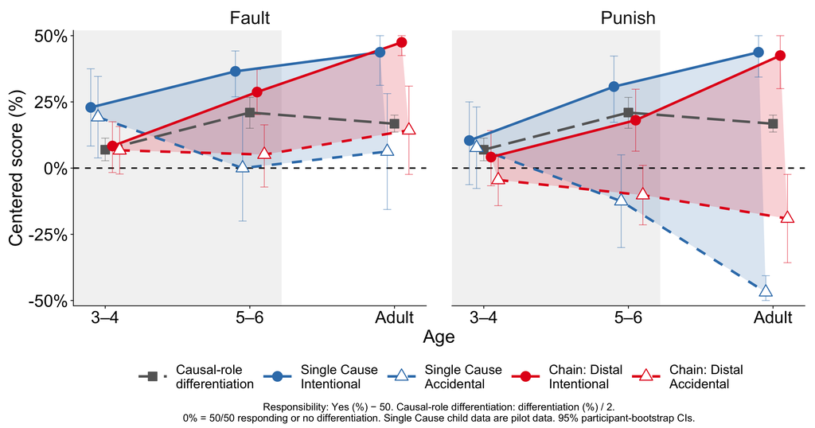

```r
p.centered.gap.builds[[12]]
```

The generated Build 09 is also independently rendered and compared pixel for pixel with the existing centered figure, before using the exact source-file copies for delivery. Across all 12 builds, PDF text positions and the locations of all axes, panels and marks are checked. Earlier figures, build series, source data and unresolved scientific handoff limitations remain unchanged.

# Final talk production folder

The production child document reuses the validated summaries and plot objects above, and writes only to `current/figures/talk_final/`. Original figures and statistical results are retained.

# Final talk production set

This child document is rendered from `causal_verbs.Rmd` after all validated summaries and models exist. It changes presentation only: it reuses the original plot objects, summary rows, fitted predictions and confidence limits. Source exports remain in their original folders. The final folder’s README carries sample, pilot, transformation and interpretation notes removed from the slides.

```r
final_root = "../../figures/talk_final"
final_sections = c("chain_baseline", "baseline_intention", "single_cause")
for (section in final_sections) for (kind in c("main", "builds", "backup"))
  dir.create(file.path(final_root, section, kind), recursive = TRUE, showWarnings = FALSE)
final_make_builds = getOption("causal_verbs.final_builds", TRUE)
final_registry = list()
final_build_registry = list()
final_plots = list()
final_geometry_checks = list()
final_font = "sans"

final_theme = function() {
  theme_classic(base_size = 32, base_family = final_font) +
    theme(axis.text = element_text(size = 32, color = "#242424"),
          axis.title = element_text(size = 36),
          axis.title.x = element_text(margin = margin(t = 16)),
          axis.title.y = element_text(margin = margin(r = 18)),
          axis.line = element_line(color = "#777777", linewidth = .65),
          axis.ticks = element_line(color = "#777777", linewidth = .65),
          panel.spacing = grid::unit(1.8, "cm"),
          strip.background = element_blank(),
          strip.text = element_text(size = 36, face = "bold", margin = margin(b = 18)),
          legend.position = "bottom", legend.justification = "center",
          legend.text = element_text(size = 44), legend.title = element_text(size = 40, face = "bold"),
          legend.key.width = grid::unit(2.6, "cm"), legend.key.height = grid::unit(1.6, "cm"),
          legend.spacing.x = grid::unit(.6, "cm"), legend.box.spacing = grid::unit(.6, "cm"),
          legend.margin = margin(t = 10), plot.margin = margin(20, 32, 18, 24))
}

final_matched_theme = function() {
  final_theme() +
    theme(axis.text = element_text(size = 40), axis.title = element_text(size = 44),
          strip.text = element_text(size = 44, face = "bold", margin = margin(b = 20)))
}

# Clone each drawing layer before editing it, so source plots remain untouched.
# Ribbon predictions are already saved; use every tenth grid row, including ends.
final_polish = function(plot, scatter = FALSE) {
  plot$layers = lapply(plot$layers, function(source_layer) {
    layer = ggproto(NULL, source_layer)
    if (inherits(layer$geom, "GeomErrorbar")) {
      layer$geom = GeomLinerange
      layer$geom_params$width = NULL
      layer$aes_params$width = NULL
    }
    if (inherits(layer$geom, "GeomRibbon")) {
      layer$geom = GeomLinerange
      groups = intersect(c("study", "panel", "intention"), names(layer$data))
      layer$data = layer$data %>% group_by(across(all_of(groups))) %>%
        filter(row_number() %in% unique(c(seq(1L, n(), by = 10L), n()))) %>% ungroup()
      layer$mapping$colour = layer$mapping$fill
      layer$mapping$fill = NULL
    }
    if (inherits(layer$geom, "GeomLinerange")) {
      layer$aes_params$linewidth = .65
      layer$aes_params$linetype = "solid"
      if (is.null(layer$mapping$alpha)) layer$aes_params$alpha = .65 else {
        rows = if (is.data.frame(layer$data)) layer$data else plot$data
        rows$.final_ci_alpha = .65 * as.numeric(rlang::eval_tidy(layer$mapping$alpha, rows) > 0)
        layer$data = rows
        layer$mapping$alpha = rlang::quo(.final_ci_alpha)
        layer$aes_params$alpha = NULL
      }
    }
    if (inherits(layer$geom, c("GeomLine", "GeomSegment", "GeomSmooth")))
      layer$aes_params$linewidth = 2.4
    if (inherits(layer$geom, "GeomPoint") && !scatter) {
      layer$aes_params$size = 8
      layer$aes_params$stroke = 1.4
    }
    if (inherits(layer$geom, "GeomHline") && identical(layer$aes_params$linetype, "dashed"))
      layer$aes_params$linewidth = 1.1
    if (inherits(layer$geom, "GeomRect")) layer$aes_params$fill = "#F3F3F3"
    layer
  })
  # Keep informative relationship-axis labels; age ticks already identify age.
  if (identical(plot$labels$x, "Age")) plot = plot + labs(x = NULL)
  plot + final_theme() + labs(title = NULL, subtitle = NULL, caption = NULL, tag = NULL)
}

# Opacity reveals keep every row, legend, scale and facet in place.
final_reveal = function(plot, visible) {
  plot$layers = lapply(plot$layers, function(source_layer) {
    layer = ggproto(NULL, source_layer)
    if (inherits(layer$geom, c("GeomPoint", "GeomLine", "GeomSegment", "GeomLinerange"))) {
      rows = if (is.data.frame(layer$data)) layer$data else plot$data
      rows$.final_alpha = as.numeric(visible(rows)) * (if (is.null(layer$aes_params$alpha)) 1 else layer$aes_params$alpha)
      layer$data = rows
      layer$mapping$alpha = rlang::quo(.final_alpha)
      layer$aes_params$alpha = NULL
    }
    layer
  })
  plot + scale_alpha_identity(guide = "none") +
    guides(color = guide_legend(override.aes = list(alpha = 1)))
}

final_export = function(plot, destination, width, height) {
  # Scientific figures use vector PDF and 240-dpi PNG from the same ggplot object.
  if (isTRUE(attr(plot, "final_original_relationship"))) {
    # Remove only the subtitle/caption drawing, retaining their layout space.
    # Build on the output device so font metrics match the original exports.
    draw_original_relationship = function() {
      on.exit(grDevices::dev.off())
      grid::grid.newpage()
      drawing = ggplotGrob(plot)
      prose = which(drawing$layout$name %in% c("subtitle", "caption"))
      drawing$grobs[prose] = lapply(prose, function(i) grid::nullGrob())
      grid::grid.draw(drawing)
    }
    grDevices::cairo_pdf(paste0(destination, ".pdf"), width = width, height = height, bg = "white")
    draw_original_relationship()
    ragg::agg_png(paste0(destination, ".png"), width = width, height = height,
                  units = "in", res = 240, background = "white")
    draw_original_relationship()
    return(invisible(NULL))
  }
  ggsave(paste0(destination, ".pdf"), plot, width = width, height = height,
         device = grDevices::cairo_pdf, bg = "white")
  ggsave(paste0(destination, ".png"), plot, width = width, height = height,
         device = ragg::agg_png, dpi = 240, bg = "white")
}
final_family = function(stem, section, source, plot, width, height, values,
                         build_names = NULL, build_function = NULL, order = NA_integer_,
                         note = "", kind = "main") {
  path = file.path(section, kind, stem)
  destination = file.path(final_root, path)
  final_export(plot, destination, width, height)
  write_csv(values, paste0(destination, "_values.csv"))
  final_plots[[stem]] <<- plot
  final_registry[[stem]] <<- tibble(order, stem, section, kind, final = paste0(path, ".pdf"),
    source, builds = if (is.null(build_names)) "" else file.path(section, "builds", stem), note)
  if (!is.null(build_names) && final_make_builds) {
    build_dir = file.path(final_root, section, "builds", stem)
    dir.create(build_dir, recursive = TRUE, showWarnings = FALSE)
    reference = ggplot_build(plot)
    reference_grob = ggplotGrob(plot)
    for (j in seq_along(build_names)) {
      build_plot = build_function(j - 1L)
      built = ggplot_build(build_plot)
      grob = ggplotGrob(build_plot)
      stopifnot(identical(built$layout$layout, reference$layout$layout),
                identical(grob$layout, reference_grob$layout),
                isTRUE(all.equal(grid::convertWidth(grob$widths, "cm", valueOnly = TRUE),
                                 grid::convertWidth(reference_grob$widths, "cm", valueOnly = TRUE))),
                isTRUE(all.equal(grid::convertHeight(grob$heights, "cm", valueOnly = TRUE),
                                 grid::convertHeight(reference_grob$heights, "cm", valueOnly = TRUE))))
      for (panel in seq_along(reference$layout$panel_params))
        stopifnot(identical(built$layout$panel_params[[panel]]$x.range, reference$layout$panel_params[[panel]]$x.range),
                  identical(built$layout$panel_params[[panel]]$y.range, reference$layout$panel_params[[panel]]$y.range))
      build_destination = file.path(build_dir, build_names[j])
      if (j == length(build_names)) {
        stopifnot(isTRUE(all.equal(built$data, reference$data)))
        # The full build is byte-identical to the main PDF and PNG.
        for (extension in c(".pdf", ".png"))
          stopifnot(file.copy(paste0(destination, extension), paste0(build_destination, extension), overwrite = TRUE))
      } else final_export(build_plot, build_destination, width, height)
      final_build_registry[[length(final_build_registry) + 1L]] <<- tibble(
        figure = stem, build = j - 1L, filename = file.path(section, "builds", stem, build_names[j]),
        full = j == length(build_names), fixed_geometry = TRUE)
    }
    final_geometry_checks[[stem]] <<- TRUE
  }
}
```

## Included-participant counts for raw figures

Counts come from final included child records and included adult participant means, deduplicated before counting. Role and measure never inflate the display N. The point values retain their own effective denominator alongside display N.

```r
final_sample_counts = function(children, adults, study) {
  bind_rows(
    children %>% transmute(population = "Children", participant,
                            age_group = as.character(age), condition = as.character(condition)),
    adults %>% transmute(population = "Adults", participant,
                          age_group = "Adult", condition = as.character(condition))) %>%
    distinct(population, participant, age_group, condition) %>%
    count(population, age_group, condition, name = "display_n") %>%
    mutate(study = study, age_group = factor(age_group, levels = age_labels)) %>%
    arrange(age_group, match(condition, c("Baseline", "Intentional", "Accidental")))
}
final_ns = bind_rows(
  final_sample_counts(df.study1.children.included, df.study1.adults.means, "Study 1"),
  final_sample_counts(df.study2.children.included, df.study2.adults.means, "Study 2"),
  final_sample_counts(df.single.included, df.single.adults.means, "Single Cause"))
stopifnot(sum(filter(final_ns, study == "Study 1")$display_n) == nrow(df.study1.role.scores),
          sum(filter(final_ns, study == "Study 2", population == "Children")$display_n) == nrow(df.study2.children.included),
          sum(filter(final_ns, study == "Single Cause", population == "Children")$display_n) == nrow(df.single.included))
write_csv(final_ns, file.path(final_root, "raw_figure_sample_sizes.csv"))
final_raw_values = function(summary, study_name) {
  summary %>% mutate(study = study_name) %>%
    left_join(final_ns, by = c("study", "population", "age_group", "condition"), relationship = "many-to-one") %>%
    mutate(point_missing_n = display_n - n)
}
final_s1_values = final_raw_values(df.study1.summary, "Study 1")
final_s2_values = final_raw_values(df.study2.summary, "Study 2")
final_sc_values = final_raw_values(df.single.summary, "Single Cause")
stopifnot(!anyNA(final_s1_values$display_n), !anyNA(final_s2_values$display_n), !anyNA(final_sc_values$display_n),
          all(bind_rows(final_s1_values, final_s2_values, final_sc_values)$point_missing_n >= 0))

final_raw = function(plot, study, measures = measure_order) {
  is_single = study == "Single Cause"
  split_condition = study != "Study 1"
  adult_x = if (is_single) 7.8 else 10.8
  last_child = if (is_single) 6 else 9
  # Change only presentation positions: all age series get the same adult gap.
  move_adult = function(rows) {
    if (!is.data.frame(rows) || !"population" %in% names(rows)) return(rows)
    old_adult = if (is_single) single_adult_position else 10
    rows %>% mutate(across(any_of(c("x", "plot_x")),
                          ~ .x + if_else(population == "Adults", adult_x - old_adult, 0)))
  }
  plot$data = move_adult(plot$data)
  plot$layers = lapply(plot$layers, function(source_layer) {
    layer = ggproto(NULL, source_layer); layer$data = move_adult(layer$data); layer
  })
  # Child shading replaces the old decorative grid/divider; quantitative marks stay unchanged.
  plot$layers = Filter(function(layer) !inherits(layer$geom, c("GeomHline", "GeomVline")), plot$layers)
  plot$layers = c(list(
    annotate("rect", xmin = -Inf, xmax = last_child + .25, ymin = -Inf, ymax = Inf, fill = "#F3F3F3"),
    geom_hline(yintercept = .5, linetype = "dashed", color = "#777777", linewidth = 1.1)), plot$layers)
  plot = final_polish(plot)
  counts = filter(final_ns, .data$study == .env$study) %>%
    mutate(x = if_else(age_group == "Adult", adult_x, suppressWarnings(as.numeric(as.character(age_group)))),
           y = if (split_condition) if_else(condition == "Intentional", -.15, -.25) else -.16,
           label = paste0("n=", display_n)) %>%
    tidyr::crossing(measure = factor(measures, levels = measures))
  plot = plot +
    scale_x_continuous(breaks = c(3:last_child, adult_x), labels = c(as.character(3:last_child), "Adult"),
                       limits = c(2.6, adult_x + .55), expand = expansion(mult = 0)) +
    scale_y_continuous(breaks = seq(0, 1, .25), labels = function(x) paste0(100 * x, "%"),
                       expand = expansion(add = .035)) +
    coord_cartesian(ylim = c(0, 1), clip = "off") +
    geom_text(data = counts, aes(x = x + if (split_condition) .07 else 0, y = y, label = label),
              inherit.aes = FALSE, family = final_font, size = 8.2, color = "#333333", show.legend = FALSE) +
    # An empty spacer retains room for the sample-size rows below the age ticks.
    labs(x = "") +
    theme(axis.title.x = element_text(margin = margin(t = if (split_condition) 96 else 65)),
          panel.spacing.y = grid::unit(if (split_condition) 4.1 else 3.1, "cm"))
  if (split_condition) plot = plot +
    geom_point(data = filter(counts, condition == "Intentional"), aes(x = x - .32, y = y),
               inherit.aes = FALSE, shape = 21, fill = "#333333", color = "#333333", size = 3.4, stroke = .65) +
    geom_point(data = filter(counts, condition == "Accidental"), aes(x = x - .32, y = y),
               inherit.aes = FALSE, shape = 24, fill = "white", color = "#333333", size = 3.4, stroke = .65)
  plot
}
```

## Main figures and their cumulative builds

```r
final_s1 = function(step) final_raw(plot_study1(df.study1.summary, step), "Study 1")
final_family("01_chain_baseline_yes", "chain_baseline", paste0(study1_output, "/study1_yes_responses_full.pdf"),
  final_s1(8), 24, 18, final_s1_values, study1_build_names, final_s1, order = 1L)

final_development = function(step) final_reveal(final_polish(p.study1.role.development),
  function(rows) match(as.character(rows$series), role_responsibility_order) <= step)
final_family("02_study1_developmental_synthesis", "chain_baseline",
  paste0(role_responsibility_output, "/study1_role_differentiation_development_talk_v1.pdf"),
  final_development(3), 20, 11, df.study1.role.development,
  c("build00_blank", "build01_causal_role_differentiation", "build02_add_fault", "build03_add_punish_full"),
  final_development, order = 2L)

final_s2 = function(step) final_raw(plot_study2(df.study2.summary, step), "Study 2")
final_family("03_chain_intention_yes", "baseline_intention", paste0(study2_output, "/study2_yes_responses_full.pdf"),
  final_s2(16), 24, 19, final_s2_values, study2_build_names, final_s2, order = 3L,
  note = "Adult chain points use the selected available pilot; the main Study 2 adult dataset is missing.")

# Preserve the source sequence: blank; each condition's children; all adults.
final_matched = function(step) {
  plot = final_polish(plot_matched_role_development(step)) + final_matched_theme()
  for (i in seq_along(plot$layers)) if (inherits(plot$layers[[i]]$geom, "GeomSegment"))
    plot$layers[[i]]$aes_params$linewidth = 4
  plot
}
final_family("matched_role_differentiation_development_talk_v1", "baseline_intention",
  paste0(matched_role_output, "/matched_role_differentiation_development_talk_v1.pdf"),
  final_matched(4), 28, 11, df.matched.role.summary,
  c("build00_blank", "build01_baseline", "build02_add_accidental", "build03_add_intentional",
    "build04_add_adults_full"), final_matched, order = 4L,
  note = "Baseline | Accidental | Intentional; unchanged participant-score means and CIs. Adults appear in the final build.")

final_transition_order = c("Causal-role differentiation", "Single Cause", "Chain: Distal")
final_transition = function(step) final_reveal(final_polish(p.role.intention.v2),
  function(rows) match(as.character(rows$series), final_transition_order) <= step)
final_family("04_intention_effect_transition", "baseline_intention",
  paste0(age_adjusted_output, "/role_differentiation_intention_effects_talk_v2.pdf"),
  final_transition(3), 24, 11, df.role.intention.v2,
  c("build00_blank", "build01_causal_role_differentiation", "build02_add_single_cause", "build03_add_chain_distal_full"),
  final_transition, order = 5L, note = "Single Cause child data are pilot data, ages 3–6 only. Adult is separate.")

# These two regressions are an explicit exception to the final-talk CI style.
# Reuse the original plot objects without final_polish(): all ribbon rows,
# point jitter, line styling, axes and theme settings must remain unchanged.
final_relationship = function(study, step) {
  source = if (study == "Study 1") p.study1.age.adjusted else p.study2.age.adjusted
  plot = source
  if (step < 2L) {
    plot$layers = lapply(plot$layers, function(source_layer) {
      layer = ggproto(NULL, source_layer)
      if (inherits(layer$geom, c("GeomPoint", "GeomLine", "GeomRibbon"))) {
        rows = if (is.data.frame(layer$data)) layer$data else plot$data
        reveal_step = if (study == "Study 1") match(as.character(rows$panel), c("Fault", "Punish"))
                      else match(as.character(rows$intention), c("Accidental", "Intentional"))
        original_alpha = if (is.null(layer$aes_params$alpha)) 1 else layer$aes_params$alpha
        rows$.final_alpha = as.numeric(reveal_step <= step) * original_alpha
        layer$data = rows
        layer$mapping$alpha = rlang::quo(.final_alpha)
        layer$aes_params$alpha = NULL
      }
      layer
    })
    plot = plot + scale_alpha_identity(guide = "none")
  }
  # Keep the original line-only Study 2 legend visible even in the blank build.
  if (study == "Study 2") plot = plot +
    guides(color = guide_legend(nrow = 1, override.aes = list(alpha = 1)),
           linetype = guide_legend(nrow = 1))
  if (step == 2L) {
    original = ggplot_build(source); updated = ggplot_build(plot)
    stopifnot(identical(original$data, updated$data),
              identical(original$layout$layout, updated$layout$layout),
              identical(source$theme, plot$theme))
    for (panel in seq_along(original$layout$panel_params))
      stopifnot(identical(original$layout$panel_params[[panel]]$x.range, updated$layout$panel_params[[panel]]$x.range),
                identical(original$layout$panel_params[[panel]]$y.range, updated$layout$panel_params[[panel]]$y.range))
  }
  # The export helper omits prose grobs without moving any retained element.
  attr(plot, "final_original_relationship") = TRUE
  plot
}
final_family("05_study1_age_adjusted_relationship", "chain_baseline",
  paste0(age_adjusted_output, "/study1_role_differentiation_age_adjusted_talk_v1.pdf"),
  final_relationship("Study 1", 2), 20, 11, filter(df.age.adjusted.predictions, study == "Study 1"),
  c("build00_blank", "build01_fault", "build02_add_punish_full"),
  function(step) final_relationship("Study 1", step), order = 6L,
  note = "Original 20 × 11 inch regression styling and 95% CI ribbons; only top/footer prose removed. Unchanged model and predictions.")
final_family("06_study2_age_adjusted_relationship", "baseline_intention",
  paste0(age_adjusted_output, "/study2_role_differentiation_age_adjusted_talk_v1.pdf"),
  final_relationship("Study 2", 2), 20, 11, filter(df.age.adjusted.predictions, study == "Study 2"),
  c("build00_blank", "build01_accidental", "build02_add_intentional_full"),
  function(step) final_relationship("Study 2", step), order = 7L,
  note = "Original 20 × 11 inch regression styling and 95% CI ribbons; only top/footer prose removed. Unchanged differentiation × intention + numeric age model.")

final_sc_measures = c("Lexical", "Fault", "Punish")
final_sc_summary = df.single.summary %>% filter(measure %in% final_sc_measures) %>%
  mutate(measure = factor(measure, levels = final_sc_measures),
         reveal_step = 2L * (match(as.character(measure), final_sc_measures) - 1L) +
           match(as.character(condition), condition_order))
final_sc = function(step) {
  plot = plot_single(final_sc_summary, step) + facet_wrap(~ measure, nrow = 1, drop = FALSE)
  final_raw(plot, "Single Cause", final_sc_measures)
}
final_family("07_single_cause_yes", "single_cause", paste0(single_output, "/single_cause_yes_responses_full.pdf"),
  final_sc(6), 26, 12, filter(final_sc_values, measure %in% final_sc_measures),
  c("build00_blank", "build01_lexical_intentional", "build02_lexical_accidental", "build03_fault_intentional",
    "build04_fault_accidental", "build05_punish_intentional", "build06_punish_accidental_full"),
  final_sc, order = 8L, note = "Single Cause children are pilot data (ages 3–6); all 32 available adult records retained.")

final_centered = function(step) final_polish(make_centered_gap_build(step)) +
  labs(y = "Relative to neutral (%)") +
  guides(color = guide_legend(nrow = 2, byrow = TRUE, override.aes = list(alpha = 1)),
         fill = guide_legend(nrow = 2, byrow = TRUE),
         shape = guide_legend(nrow = 2, byrow = TRUE),
         linetype = guide_legend(nrow = 2, byrow = TRUE))
final_family("08_centered_cross_study_gap_fills", "single_cause",
  paste0(binned_responsibility_output, "/causal_role_and_raw_responsibility_centered_talk_v1.pdf"),
  final_centered(11), 26, 12, df.binned.centered.values, centered_gap_build_names, final_centered, order = 9L,
  note = "Source centered figure plus its build11_add_chain_distal_gap_fill_full. Blue/red gap fills alpha=.18; these are not CIs.")
```

## Selected backups

These preserve the source estimates and the source distinction between a talk version without CIs and an explicit CI backup. The context-sensitivity backup uses its existing CI version.

```r
final_family("study1_role_relationship_backup", "chain_baseline",
  paste0(role_responsibility_output, "/study1_role_differentiation_relationship_backup_v1.pdf"),
  final_polish(p.study1.role.relationship, scatter = TRUE), 24, 12, df.study1.role.joint, kind = "backup",
  note = "Children and adults; original pooled unadjusted fits. Faint participant points retain fixed display-only jitter.")
final_family("matched_role_differentiation_backup", "baseline_intention",
  paste0(matched_role_output, "/matched_role_differentiation_development_talk_v1.pdf"),
  final_polish(p.matched.role$main), 28, 11, df.matched.role.summary, kind = "backup",
  note = "Baseline | Accidental | Intentional; original participant-score summaries and CIs.")
final_family("role_preference_all_measures_backup", "baseline_intention",
  paste0(presentation_v2_output, "/role_preference_all_measures_talk_v2.pdf"),
  final_polish(p.role.preference.all$main), 28, 11, df.role.preference.all.summary, kind = "backup",
  note = "Original no-CI talk version; Baseline, Accidental and Intentional role preferences.")
final_family("intention_sensitivity_across_contexts_backup", "baseline_intention",
  paste0(presentation_v2_output, "/intention_sensitivity_across_contexts_talk_v1_with_ci.pdf"),
  final_polish(p.context.sensitivity$backup), 28, 11, df.context.sensitivity.summary, kind = "backup",
  note = "Existing CI backup; Single Cause / Chain: Proximal / Chain: Distal. Single Cause children are pilot data.")
final_family("single_cause_four_measures_backup", "single_cause",
  paste0(single_output, "/single_cause_yes_responses_full.pdf"),
  final_raw(p.single.full, "Single Cause"), 24, 19, final_sc_values, kind = "backup",
  note = "Full raw-response backup including Caused. Single Cause children are pilot data.")
final_family("single_cause_vs_chain_distal_intention_effect_backup", "single_cause",
  paste0(binned_responsibility_output, "/single_cause_vs_chain_distal_intention_effect_talk_v1.pdf"),
  final_polish(p.binned.intention.effects), 24, 11, df.binned.intention.effects, kind = "backup",
  note = "Intentional minus Accidental; Single Cause children are pilot data; pointwise CIs are not context-difference tests.")
```

## Production validation and navigation

```r
final_index = bind_rows(final_registry) %>% arrange(kind != "main", order, section, stem)
# Registry source links are relative to this final folder, not the R working directory.
final_index$source = sub("^../../figures/", "../", final_index$source)
write_csv(final_index, file.path(final_root, "figure_index.csv"))
if (final_make_builds) write_csv(bind_rows(final_build_registry), file.path(final_root, "build_manifest.csv"))
stopifnot(nrow(final_index) == 15L, identical(filter(final_index, kind == "main")$order, 1:9))
for (plot in final_plots) {
  stopifnot(is.null(plot$labels$title), !identical(plot$labels$x, "Age"))
  original_relationship = isTRUE(attr(plot, "final_original_relationship"))
  if (original_relationship) {
    # Subtitle/caption grobs are removed only at export to preserve geometry.
    stopifnot(sum(vapply(plot$layers, function(layer) inherits(layer$geom, "GeomRibbon"), logical(1))) == 1L)
  } else stopifnot(is.null(plot$labels$subtitle), is.null(plot$labels$caption),
                   plot$theme$legend.text$size == 44)
  for (layer in plot$layers) {
    stopifnot(!inherits(layer$geom, "GeomErrorbar"))
    if (original_relationship) stopifnot(!inherits(layer$geom, "GeomLinerange"))
    else stopifnot(!inherits(layer$geom, "GeomRibbon"))
  }
}
if (final_make_builds) stopifnot(nrow(bind_rows(final_build_registry)) == 64L,
                                length(final_geometry_checks) == 9L)
# No participant identifiers are exported into the presentation folder.
for (entry in final_registry) {
  values = read_csv(file.path(final_root, sub("\\.pdf$", "_values.csv", entry$final)), show_col_types = FALSE)
  stopifnot(!any(names(values) %in% c("participant", "workerid", "response_uuid", "response_id")))
}
final_missing = bind_rows(final_s1_values, final_s2_values, final_sc_values) %>% filter(point_missing_n > 0)
write_csv(final_missing, file.path(final_root, "raw_point_denominator_exceptions.csv"))
# Re-export existing model results as exact-value companions, without refitting.
write_csv(df.age.adjusted.coefficients, file.path(final_root, "age_adjusted_coefficients_unchanged.csv"))
write_csv(df.age.adjusted.contrasts, file.path(final_root, "age_adjusted_contrasts_unchanged.csv"))
write_csv(df.age.adjusted.frequencies, file.path(final_root, "age_adjusted_joint_frequencies_unchanged.csv"))

final_table = function(rows) paste0(
  "| ", ifelse(is.na(rows$order), "—", rows$order), " | [", rows$stem, "](", rows$final, ") | [",
  basename(rows$source), "](", rows$source, ") | ", rows$section, " | ", rows$kind,
  " | ", ifelse(rows$builds == "", "—", paste0("[builds](", rows$builds, "/)")), " | ", gsub("|", " / ", rows$note, fixed = TRUE), " |")
final_count_table = final_ns %>% transmute(
  line = paste0("| ", study, " | ", age_group, " | ", condition, " | ", display_n, " |"))
final_readme = c(
  "# Final talk figures", "",
  "Use the nine main figures in the order below. Every figure and build has both a vector PDF and a 240-dpi PNG. Each main figure's final build is an exact file copy of that main PDF/PNG. All source figures and scientific data are preserved.", "",
  "## Main talk order and source map", "",
  "1. Chain baseline yes responses", "2. Study 1 developmental synthesis", "3. Chain with intentional/accidental information",
  "4. Matched developmental synthesis: Baseline | Accidental | Intentional",
  "5. Study 2 intention-effect transition figure", "6. Study 1 age-adjusted causal-role/responsibility relationship",
  "7. Study 2 age-adjusted causal-role × intention relationship", "8. Single Cause yes responses (Lexical / Fault / Punish)",
  "9. Final cross-study centered synthesis with gap fills", "",
  "| Order | Final PDF (matching PNG alongside) | Original/source filename | Section | Use | Builds | Provenance note |",
  "| --- | --- | --- | --- | --- | --- | --- |", final_table(final_index), "",
  "## Builds", "",
  "- Chain baseline: the original 00–08 sequence, each measure's adults then children.",
  "- Study 1 development: blank → causal-role differentiation → + Fault → + Punish/full (adults included with each trajectory).",
  "- Chain intention: the original 00–16 sequence; within each measure Intentional adults/children, then Accidental adults/children.",
  "- Matched development: blank → Baseline children → + Accidental children → + Intentional children → + all adults/full. The existing backup remains available; the main version has the larger matched-family typography.",
  "- Transition: blank → causal-role differentiation → + Single Cause → + Chain: Distal/full.",
  "- Study 1 age-adjusted: blank → Fault → + Punish/full.",
  "- Study 2 age-adjusted: blank → Accidental → + Intentional/full.",
  "- Single Cause: blank → Lexical Intentional → Lexical Accidental → Fault Intentional → Fault Accidental → Punish Intentional → Punish Accidental/full.",
  "- Centered payoff: blank → differentiation in both panels → Single Cause Intentional Fault/Punish → Chain: Distal Intentional Fault/Punish → Single Cause Accidental Fault/Punish → Chain: Distal Accidental Fault/Punish → blue gap fill → red gap fill/full.",
  "", "The [build manifest](build_manifest.csv) lists all 64 frames. Panels, axes, legend positions and marks retain fixed geometry within every sequence. Full legends and sample-size labels stay visible in blank scaffolds.", "",
  "## Quantities, intervals and sample limitations", "",
  "- Raw Yes=1 / No=0. Average available scenarios within participant before group means; both-Yes and neither-Yes responses are retained. Distal/proximal are repeated measures, not separate participants.",
  "- Causal-role differentiation = [(Caused Distal − Proximal) + (Lexical Proximal − Distal)] / 2. Fault and Punish distal preferences = Distal − Proximal. Percentage ticks on contrasts denote percentage points.",
  "- The centered payoff uses responsibility Yes (%) − 50 and causal-role differentiation (%) / 2. Zero means 50/50 responsibility responding or no causal differentiation. These are different constructs on a shared display scale, not interchangeable measurements.",
  "- Blue/red fills in the payoff are the areas between each context's Intentional and Accidental means (alpha .18), not confidence bands. They sit behind all data marks; red overlays blue.",
  "- All estimates and 95% participant-bootstrap limits are reused unchanged from the source workflow (5,000 draws). Developmental mean/trajectory CIs are thin vertical bars without caps or endpoint marks. The two age-adjusted regressions are the explicit exception: they retain their original translucent 95% CI ribbons and complete prediction grids; all predictions/limits remain in the exact-value CSVs. Age-adjusted fits and predictions are reused directly; the pooled relationship backup retains its unchanged source linear-fit drawing layer.",
  "- Final figures and builds omit the redundant Age axis title. Legends use 44-point text with larger keys, except the two original-style age-adjusted regressions, which retain their original sizing. Informative non-age x-axis labels are retained. The centered synthesis wraps its five-entry legend into two rows; raw figures retain space for participant counts.",
  "- The matched main figure uses a 28 × 11 inch canvas, 40-point tick labels and 44-point axis/panel labels. The two age-adjusted figures and their builds instead match the original 20 × 11 inch PDFs: white panels, 2.1 mm fitted lines, original faint participant points, translucent CI ribbons, axis limits, fonts, spacing and Study 2 line-only legend. Only the top explanatory sentence and footer are removed; their layout space is retained so all other elements stay in the original positions.",
  "- Age-adjusted figures are children-only: Study 1 responsibility ~ differentiation + numeric age; Study 2 responsibility ~ differentiation × intention + numeric age. Faint points are observed participant scores with unchanged display-only jitter; fitted lines use the original age standardization. Unchanged coefficients, contrasts and joint frequencies are supplied in the root CSVs. These exploratory cross-sectional associations do not establish causation or mediation.",
  "- Single Cause child data are pilot data and cover ages 3–6 only. Binned comparisons use participant-weighted 3–4 and 5–6 groups, excluding ages 7–9. Single-year figures show adults separately; binned figures retain their source categorical connections.",
  "- Study 2 adult chain values use the selected available adult pilot; the main adult dataset remains missing. Single Cause uses all 32 available adult records; the historical N=30 exclusion subset remains unidentified. No historical exclusions or preregistration decisions are invented.",
  "- The organized import is complete; Sunny's scientific handoff gaps remain unresolved. This presentation pass does not imply scientific handoff acceptance. Existing missing scripts, custody, path, timing, asset-source/hosting and preregistration/cohort limitations remain as documented elsewhere.", "",
  "## Sample-size displays", "",
  "Only the raw Yes figures show Ns (including the four-measure raw backup). Counts are unique included participants per age, or age × condition; they are computed from the final included records and adult analysis participants. For condition plots the filled-circle N is Intentional (top), and the open-triangle N is Accidental (bottom). The same condition N is shown once per age under each panel, never twice for distal/proximal.", "",
  paste0("Point-specific effective denominators are in each raw `_values.csv` alongside `display_n` and `point_missing_n`. There are ", nrow(final_missing), " point-denominator exceptions in this snapshot; see [exceptions](raw_point_denominator_exceptions.csv)."), "",
  "| Study | Age | Condition | Unique included N |", "| --- | --- | --- | --- |", final_count_table$line, "",
  "## Reproduce and verify", "",
  "Render [causal_verbs.Rmd](../../code/R/causal_verbs.Rmd), which includes [talk_final.Rmd](../../code/R/talk_final.Rmd) after the existing analysis. Paths are relative. This child document is presentation-only and consumes existing plot objects and validated summaries; it does not change participant selection, source data, bootstrap estimates or model specifications.", "",
  "Production checks enforce 9 main figures, 6 backups, 64 builds, fixed build geometry, exact full-build copies, no displayed titles/subtitles/captions, original CI ribbons for the two age-adjusted regressions and uncapped vertical CI lines for developmental trajectories, and no participant identifiers in exported tables. Source-file and data hashes plus decoded PDF comparisons are checked before commit. All main, backup and build PDFs are visually reviewed after rendering."
)
writeLines(final_readme, file.path(final_root, "README.md"))
knitr::kable(select(final_index, order, stem, section, kind))
```

| order | stem | section | kind |
| --- | --- | --- | --- |
| 1 | 01_chain_baseline_yes | chain_baseline | main |
| 2 | 02_study1_developmental_synthesis | chain_baseline | main |
| 3 | 03_chain_intention_yes | baseline_intention | main |
| 4 | matched_role_differentiation_development_talk_v1 | baseline_intention | main |
| 5 | 04_intention_effect_transition | baseline_intention | main |
| 6 | 05_study1_age_adjusted_relationship | chain_baseline | main |
| 7 | 06_study2_age_adjusted_relationship | baseline_intention | main |
| 8 | 07_single_cause_yes | single_cause | main |
| 9 | 08_centered_cross_study_gap_fills | single_cause | main |
| NA | intention_sensitivity_across_contexts_backup | baseline_intention | backup |
| NA | matched_role_differentiation_backup | baseline_intention | backup |
| NA | role_preference_all_measures_backup | baseline_intention | backup |
| NA | study1_role_relationship_backup | chain_baseline | backup |
| NA | single_cause_four_measures_backup | single_cause | backup |
| NA | single_cause_vs_chain_distal_intention_effect_backup | single_cause | backup |

# Compact validation tables and checks

## Inclusion flow and exclusion reasons

Raw counts distinguish sessions from children. The flow below removes ineligible sessions before repeat-attempt selection. A child with an excluded attempt can still contribute through a different eligible attempt.

```r
df.children.flow = bind_rows(
  tibble(study = "Study 1", raw_sessions = nrow(df.study1.children.attempts),
         eligible_sessions = nrow(df.study1.children.eligible),
         retained_children = nrow(df.study1.children.included)),
  tibble(study = "Study 2", raw_sessions = nrow(df.study2.children.attempts),
         eligible_sessions = nrow(df.study2.children.eligible),
         retained_children = nrow(df.study2.children.included))) %>%
  mutate(excluded_sessions = raw_sessions - eligible_sessions,
         repeat_sessions_removed = eligible_sessions - retained_children)
kable(bind_rows(df.study1.children.raw_counts, df.study2.children.raw_counts))
```

| study | rows | sessions | children |
| --- | --- | --- | --- |
| Study 1 | 3870 | 215 | 212 |
| Study 2 | 7523 | 422 | 416 |

```r
kable(df.children.flow)
```

| study | raw_sessions | eligible_sessions | retained_children | excluded_sessions | repeat_sessions_removed |
| --- | --- | --- | --- | --- | --- |
| Study 1 | 215 | 214 | 211 | 1 | 3 |
| Study 2 | 422 | 410 | 406 | 12 | 4 |

```r
kable(bind_rows(mutate(df.study1.children.attempts, study = "Study 1"),
                mutate(df.study2.children.attempts, study = "Study 2")) %>%
        filter(!eligible) %>% count(study, analysis_exclusion_reason, name = "sessions"))
```

| study | analysis_exclusion_reason | sessions |
| --- | --- | --- |
| Study 1 | withdrawn | 1 |
| Study 2 | incomplete_test_questions:0/16 | 4 |
| Study 2 | incomplete_test_questions:10/16 | 1 |
| Study 2 | ineligible | 1 |
| Study 2 | withdrawn | 6 |

## Check plotted means directly against binary response rows

This second calculation starts from individual binary response rows. For each participant and role/measure it divides the number of Yes answers by the number of available questions, then averages those fractions across participants. It does not use the participant-mean helper or the pattern audit. Every plotted mean and contributing N must match. The compact table shows both role-specific means and Ns at each age/condition; adult rows use the category Adult.

```r
df.validation.participants = bind_rows(
  df.study1.adults.responses, df.study1.children.responses,
  df.study2.adults.responses, df.study2.children.responses) %>%
  mutate(age_group = if_else(population == "Adults", "Adult", as.character(age))) %>%
  group_by(study, population, age_group, condition, measure, role, participant) %>%
  summarise(yes_answers = sum(endorsed, na.rm = TRUE),
            available_questions = sum(!is.na(endorsed)), .groups = "drop") %>%
  mutate(participant_yes = if_else(available_questions > 0,
                                  yes_answers / available_questions, NA_real_))
df.validation.means = df.validation.participants %>%
  group_by(study, population, age_group, condition, measure, role) %>%
  summarise(checked_n = sum(!is.na(participant_yes)),
            checked_mean = mean(participant_yes, na.rm = TRUE), .groups = "drop")
df.plotted.checks = bind_rows(df.study1.summary, df.study2.summary) %>%
  left_join(df.validation.means,
            by = c("study", "population", "age_group", "condition", "measure", "role"),
            relationship = "one-to-one")
stopifnot(all(df.plotted.checks$n == df.plotted.checks$checked_n),
          all(abs(df.plotted.checks$mean - df.plotted.checks$checked_mean) < 1e-12),
          nrow(df.plotted.checks) == nrow(df.validation.means))
df.plotted.means = df.plotted.checks %>%
  select(study, age_group, condition, measure, role, n, mean) %>%
  pivot_wider(names_from = role, values_from = c(n, mean)) %>%
  arrange(study, measure, condition, match(age_group, age_labels))
kable(df.plotted.means, digits = 6,
      caption = "Verified plotted proportions: participant-weighted Yes means and Ns by role")
```

Verified plotted proportions: participant-weighted Yes means and Ns by role

| study | age_group | condition | measure | n_Distal | n_Proximal | mean_Distal | mean_Proximal |
| --- | --- | --- | --- | --- | --- | --- | --- |
| Study 1 | 3 | Baseline | Caused | 31 | 31 | 0.612903 | 0.596774 |
| Study 1 | 4 | Baseline | Caused | 32 | 32 | 0.531250 | 0.468750 |
| Study 1 | 5 | Baseline | Caused | 29 | 29 | 0.517241 | 0.448276 |
| Study 1 | 6 | Baseline | Caused | 30 | 30 | 0.750000 | 0.300000 |
| Study 1 | 7 | Baseline | Caused | 30 | 30 | 0.850000 | 0.333333 |
| Study 1 | 8 | Baseline | Caused | 30 | 30 | 0.783333 | 0.350000 |
| Study 1 | 9 | Baseline | Caused | 29 | 29 | 0.862069 | 0.465517 |
| Study 1 | Adult | Baseline | Caused | 100 | 100 | 0.825000 | 0.375000 |
| Study 1 | 3 | Baseline | Fault | 31 | 31 | 0.548387 | 0.532258 |
| Study 1 | 4 | Baseline | Fault | 32 | 32 | 0.640625 | 0.406250 |
| Study 1 | 5 | Baseline | Fault | 29 | 29 | 0.603448 | 0.413793 |
| Study 1 | 6 | Baseline | Fault | 30 | 30 | 0.583333 | 0.283333 |
| Study 1 | 7 | Baseline | Fault | 30 | 30 | 0.850000 | 0.133333 |
| Study 1 | 8 | Baseline | Fault | 30 | 30 | 0.883333 | 0.166667 |
| Study 1 | 9 | Baseline | Fault | 29 | 29 | 0.827586 | 0.241379 |
| Study 1 | Adult | Baseline | Fault | 100 | 100 | 0.855000 | 0.140000 |
| Study 1 | 3 | Baseline | Lexical | 31 | 31 | 0.483871 | 0.725806 |
| Study 1 | 4 | Baseline | Lexical | 32 | 32 | 0.421875 | 0.656250 |
| Study 1 | 5 | Baseline | Lexical | 29 | 29 | 0.258621 | 0.741379 |
| Study 1 | 6 | Baseline | Lexical | 30 | 30 | 0.183333 | 0.850000 |
| Study 1 | 7 | Baseline | Lexical | 30 | 30 | 0.200000 | 0.766667 |
| Study 1 | 8 | Baseline | Lexical | 30 | 30 | 0.166667 | 0.850000 |
| Study 1 | 9 | Baseline | Lexical | 29 | 29 | 0.103448 | 0.948276 |
| Study 1 | Adult | Baseline | Lexical | 100 | 100 | 0.420000 | 0.640000 |
| Study 1 | 3 | Baseline | Punish | 31 | 31 | 0.580645 | 0.532258 |
| Study 1 | 4 | Baseline | Punish | 32 | 32 | 0.531250 | 0.578125 |
| Study 1 | 5 | Baseline | Punish | 29 | 29 | 0.465517 | 0.362069 |
| Study 1 | 6 | Baseline | Punish | 30 | 30 | 0.533333 | 0.216667 |
| Study 1 | 7 | Baseline | Punish | 30 | 30 | 0.700000 | 0.100000 |
| Study 1 | 8 | Baseline | Punish | 30 | 30 | 0.766667 | 0.083333 |

[output cut: 66 more lines]

The comparison is checked against that independent calculation from binary response rows, not just against the plotting summary. Both source means and Ns must match, and every displayed change must equal Study 2 minus Study 1.

```r
df.comparison.checked_baseline = df.validation.means %>%
  filter(study == "Study 1") %>%
  select(population, age_group, measure, role,
         checked_baseline = checked_mean, checked_baseline_n = checked_n)
df.comparison.checked_study2 = df.validation.means %>%
  filter(study == "Study 2") %>%
  select(population, age_group, measure, role, condition,
         checked_study2 = checked_mean, checked_study2_n = checked_n)
df.comparison.checks = df.comparison.plotted_values %>%
  left_join(df.comparison.checked_baseline,
            by = c("population", "age_group", "measure", "role"), relationship = "many-to-one") %>%
  left_join(df.comparison.checked_study2,
            by = c("population", "age_group", "measure", "role", "condition"),
            relationship = "one-to-one")
stopifnot(all(df.comparison.checks$baseline_n == df.comparison.checks$checked_baseline_n),
          all(df.comparison.checks$study2_n == df.comparison.checks$checked_study2_n),
          all(abs(df.comparison.checks$baseline - df.comparison.checks$checked_baseline) < 1e-12),
          all(abs(df.comparison.checks$study2_yes - df.comparison.checks$checked_study2) < 1e-12),
          all(abs(df.comparison.checks$change -
                    (df.comparison.checks$checked_study2 - df.comparison.checks$checked_baseline)) < 1e-12))
```

The age-pooled gap summary is independently checked from binary response rows: average each child’s scenarios, pair their roles within measure, subtract Proximal from Distal, then average the paired differences within condition. All eight plotted gaps and paired Ns must match.

```r
df.gap.checked_binary = df.validation.participants %>%
  filter(study == "Study 2", population == "Children") %>%
  select(participant, age_group, condition, measure, role, participant_yes) %>%
  pivot_wider(names_from = role, values_from = participant_yes) %>%
  mutate(checked_gap_pp = 100 * (Distal - Proximal)) %>%
  group_by(measure, condition) %>%
  summarise(checked_n = sum(!is.na(checked_gap_pp)),
            checked_gap_pp = mean(checked_gap_pp, na.rm = TRUE), .groups = "drop")
df.gap.checks = df.gap.summary %>%
  left_join(df.gap.checked_binary, by = c("measure", "condition"), relationship = "one-to-one")
stopifnot(all(df.gap.checks$n == df.gap.checks$checked_n),
          all(abs(df.gap.checks$gap_pp - df.gap.checks$checked_gap_pp) < 1e-12))
```

Single Cause means and the 12 synthesis effects are also checked directly from binary answers. These checks recalculate each participant’s Yes fraction without the participant-mean tables used by the plots.

```r
df.single.checked_participants = bind_rows(
  df.single.responses %>% mutate(population = "Children", age_group = as.character(age)),
  df.single.adults.responses %>% mutate(population = "Adults", age_group = "Adult", age = NA_integer_)) %>%
  group_by(population, age_group, age, participant, condition, measure) %>%
  summarise(participant_yes = sum(endorsed, na.rm = TRUE) / sum(!is.na(endorsed)), .groups = "drop")
df.single.checked_means = df.single.checked_participants %>%
  group_by(population, age_group, condition, measure) %>%
  summarise(checked_n = sum(!is.na(participant_yes)),
            checked_mean = mean(participant_yes, na.rm = TRUE), .groups = "drop")
df.single.checks = df.single.summary %>%
  left_join(df.single.checked_means, by = c("population", "age_group", "condition", "measure"),
            relationship = "one-to-one")
stopifnot(nrow(df.single.checks) == nrow(df.single.checked_means),
          all(df.single.checks$n == df.single.checks$checked_n),
          all(abs(df.single.checks$mean - df.single.checks$checked_mean) < 1e-12))
df.synthesis.checked = bind_rows(
  df.single.checked_participants %>% filter(population == "Children", age %in% synthesis_ages) %>%
    transmute(structure = "Single Cause", participant, condition, measure, participant_yes),
  df.validation.participants %>% filter(study == "Study 2", population == "Children",
                                         age_group %in% as.character(synthesis_ages)) %>%
    transmute(structure = paste("Study 2", role), participant, condition, measure, participant_yes)) %>%
  group_by(structure, measure, condition) %>%
  summarise(checked_n = sum(!is.na(participant_yes)),
            checked_yes = mean(participant_yes, na.rm = TRUE), .groups = "drop") %>%
  pivot_wider(names_from = condition, values_from = c(checked_n, checked_yes)) %>%
  mutate(checked_effect = 100 * (checked_yes_Intentional - checked_yes_Accidental))
df.synthesis.checks = df.synthesis.summary %>%
  left_join(df.synthesis.checked, by = c("structure", "measure"), relationship = "one-to-one")
stopifnot(nrow(df.synthesis.checks) == nrow(df.synthesis.checked),
          all(df.synthesis.checks$n_Intentional == df.synthesis.checks$checked_n_Intentional),
          all(df.synthesis.checks$n_Accidental == df.synthesis.checks$checked_n_Accidental),
          all(abs(df.synthesis.checks$yes_Intentional - df.synthesis.checks$checked_yes_Intentional) < 1e-12),
          all(abs(df.synthesis.checks$yes_Accidental - df.synthesis.checks$checked_yes_Accidental) < 1e-12),
          all(abs(df.synthesis.checks$effect_pp - df.synthesis.checks$checked_effect) < 1e-12))
```

The developmental-stage tables are checked against the independently counted binary-answer fractions above, including both source condition/role means and all eligible/contributing Ns. This covers every endpoint used in the three new figures and verifies that no ages 7–9 enter the stage summaries.

```r
df.stage.checked = bind_rows(
  df.validation.participants %>%
    transmute(study, population, age = as.integer(replace(age_group, age_group == "Adult", NA_character_)), participant,
              condition, measure, role, participant_yes),
  df.single.checked_participants %>%
    transmute(study = "Single Cause", population, age, participant, condition, measure,
              role = "Direct", participant_yes)) %>%
  mutate(stage = stage_group(population, age)) %>% filter(!is.na(stage)) %>%
  group_by(study, population, stage, condition, measure, role) %>%
  summarise(checked_eligible_n = n(), checked_n = sum(!is.na(participant_yes)),
            checked_mean = mean(participant_yes, na.rm = TRUE), .groups = "drop")
df.stage.checks = df.stage.summary %>%
  left_join(df.stage.checked, by = c("study", "population", "stage", "condition", "measure", "role"),
            relationship = "one-to-one")
stopifnot(nrow(df.stage.checks) == 96L, nrow(df.stage.checked) == 96L,
          all(df.stage.checks$eligible_n == df.stage.checks$checked_eligible_n),
          all(df.stage.checks$n == df.stage.checks$checked_n),
          all(abs(df.stage.checks$mean - df.stage.checks$checked_mean) < 1e-12))
```

The following small **synthetic validation example**, separate from all study data, checks the four binary response patterns and question-specific missingness. The final example has Bike Distal=1, Bike Proximal=missing, Mirror Distal=0, Mirror Proximal=1. Its distal mean must be .5 and proximal mean 1; the missing proximal answer must not discard the bike distal answer.

```r
df.scoring.examples = tibble(
  study = "Validation", population = "Adults",
  participant = rep(c("both", "neither", "distal_only", "proximal_only", "missing"), each = 4),
  age = NA_integer_, condition = "Baseline", measure = "Caused",
  scenario = rep(c("Bike", "Bike", "Mirror", "Mirror"), 5),
  role = rep(role_order, 10),
  endorsed = c(1, 1, 1, 1, 0, 0, 0, 0, 1, 0, 1, 0, 0, 1, 0, 1, 1, NA, 0, 1))
df.scoring.expected = tibble(
  participant = c("both", "neither", "distal_only", "proximal_only", "missing"),
  expected_distal = c(1, 0, 1, 0, .5), expected_proximal = c(1, 0, 0, 1, 1))
df.scoring.checked = participant_means(df.scoring.examples) %>%
  select(participant, role, yes_mean) %>%
  pivot_wider(names_from = role, values_from = yes_mean) %>%
  left_join(df.scoring.expected, by = "participant", relationship = "one-to-one")
stopifnot(all(df.scoring.checked$Distal == df.scoring.checked$expected_distal),
          all(df.scoring.checked$Proximal == df.scoring.checked$expected_proximal))
```

For the new role-preference contrast, a scenario needs both roles. The same missingness example must therefore retain only its complete Mirror contrast (0 − 1 = −1), while preserving other valid judgments. Both/Neither each yield zero. These checks distinguish paired-scenario scoring from subtracting role means based on different available scenarios.

```r
df.preference.expected = tibble(
  participant = c("both", "neither", "distal_only", "proximal_only", "missing"),
  expected = c(0, 0, 1, -1, -1), expected_pairs = c(2L, 2L, 2L, 2L, 1L))
df.preference.checked = role_preference_means(df.scoring.examples) %>%
  left_join(df.preference.expected, by = "participant", relationship = "one-to-one")
stopifnot(all(df.preference.checked$role_difference == df.preference.checked$expected),
          all(df.preference.checked$paired_scenarios == df.preference.checked$expected_pairs))
# A different, complete judgment from this participant must remain usable.
df.preference.missing.example = bind_rows(
  filter(df.scoring.examples, participant == "missing"),
  filter(df.scoring.examples, participant == "distal_only") %>%
    mutate(participant = "missing", measure = "Lexical"))
df.preference.missing.checked = role_preference_means(df.preference.missing.example)
stopifnot(nrow(df.preference.missing.checked) == 2L,
          df.preference.missing.checked$role_difference[df.preference.missing.checked$measure == "Lexical"] == 1,
          df.preference.missing.checked$paired_scenarios[df.preference.missing.checked$measure == "Lexical"] == 2L)
```

## Both/neither response patterns

Each count is a **participant × scenario × measure pair**, not a unique child. Both contributes two yes judgments; neither contributes two no judgments. Distal-only and proximal-only each contribute one yes and one no. Pattern labels do not filter the plots or change their values. Counts are grouped by study, population, age, condition and measure. The scenario table separately shows the number of available questions per participant, measure and role. A missing answer affects only its own role-specific mean.

```r
df.all.patterns = bind_rows(df.study1.patterns, df.study2.patterns)
df.pattern.audit = df.all.patterns %>%
  mutate(age_group = if_else(population == "Adults", "Adult", as.character(age))) %>%
  count(study, population, age_group, condition, measure, pattern, name = "pairs") %>%
  pivot_wider(names_from = pattern, values_from = pairs, values_fill = 0)
cat("<details><summary>Show all response-pattern counts</summary>\n\n")
```

**Show all response-pattern counts**

```r
print(kable(df.pattern.audit))
```

| study | population | age_group | condition | measure | both | distal only | neither | proximal only |
| --- | --- | --- | --- | --- | --- | --- | --- | --- |
| Study 1 | Adults | Adult | Baseline | Caused | 55 | 110 | 15 | 20 |
| Study 1 | Adults | Adult | Baseline | Fault | 20 | 151 | 21 | 8 |
| Study 1 | Adults | Adult | Baseline | Lexical | 30 | 54 | 18 | 98 |
| Study 1 | Adults | Adult | Baseline | Punish | 2 | 137 | 56 | 5 |
| Study 1 | Children | 3 | Baseline | Caused | 21 | 17 | 8 | 16 |
| Study 1 | Children | 3 | Baseline | Fault | 19 | 15 | 14 | 14 |
| Study 1 | Children | 3 | Baseline | Lexical | 20 | 10 | 7 | 25 |
| Study 1 | Children | 3 | Baseline | Punish | 20 | 16 | 13 | 13 |
| Study 1 | Children | 4 | Baseline | Caused | 9 | 25 | 9 | 21 |
| Study 1 | Children | 4 | Baseline | Fault | 13 | 28 | 10 | 13 |
| Study 1 | Children | 4 | Baseline | Lexical | 12 | 15 | 7 | 30 |
| Study 1 | Children | 4 | Baseline | Punish | 19 | 15 | 12 | 18 |
| Study 1 | Children | 5 | Baseline | Caused | 7 | 23 | 9 | 19 |
| Study 1 | Children | 5 | Baseline | Fault | 11 | 24 | 10 | 13 |
| Study 1 | Children | 5 | Baseline | Lexical | 8 | 7 | 8 | 35 |
| Study 1 | Children | 5 | Baseline | Punish | 8 | 19 | 18 | 13 |
| Study 1 | Children | 6 | Baseline | Caused | 6 | 39 | 3 | 12 |
| Study 1 | Children | 6 | Baseline | Fault | 7 | 28 | 15 | 10 |
| Study 1 | Children | 6 | Baseline | Lexical | 7 | 4 | 5 | 44 |
| Study 1 | Children | 6 | Baseline | Punish | 5 | 27 | 20 | 8 |
| Study 1 | Children | 7 | Baseline | Caused | 13 | 38 | 2 | 7 |
| Study 1 | Children | 7 | Baseline | Fault | 5 | 46 | 6 | 3 |
| Study 1 | Children | 7 | Baseline | Lexical | 3 | 9 | 5 | 43 |
| Study 1 | Children | 7 | Baseline | Punish | 4 | 38 | 16 | 2 |
| Study 1 | Children | 8 | Baseline | Caused | 11 | 36 | 3 | 10 |
| Study 1 | Children | 8 | Baseline | Fault | 8 | 45 | 5 | 2 |
| Study 1 | Children | 8 | Baseline | Lexical | 3 | 7 | 2 | 48 |
| Study 1 | Children | 8 | Baseline | Punish | 2 | 44 | 11 | 3 |
| Study 1 | Children | 9 | Baseline | Caused | 20 | 30 | 1 | 7 |
| Study 1 | Children | 9 | Baseline | Fault | 9 | 39 | 5 | 5 |

[output cut: 66 more lines]

```r
cat("\n</details>\n")
```

```r
df.scenario.audit = bind_rows(df.study1.means, df.study2.means) %>%
  count(study, population, condition, measure, role, scenarios_available, name = "participants")
cat("<details><summary>Show available scenarios per participant mean</summary>\n\n")
```

**Show available scenarios per participant mean**

```r
print(kable(df.scenario.audit))
```

| study | population | condition | measure | role | scenarios_available | participants |
| --- | --- | --- | --- | --- | --- | --- |
| Study 1 | Adults | Baseline | Caused | Distal | 2 | 100 |
| Study 1 | Adults | Baseline | Caused | Proximal | 2 | 100 |
| Study 1 | Adults | Baseline | Fault | Distal | 2 | 100 |
| Study 1 | Adults | Baseline | Fault | Proximal | 2 | 100 |
| Study 1 | Adults | Baseline | Lexical | Distal | 2 | 100 |
| Study 1 | Adults | Baseline | Lexical | Proximal | 2 | 100 |
| Study 1 | Adults | Baseline | Punish | Distal | 2 | 100 |
| Study 1 | Adults | Baseline | Punish | Proximal | 2 | 100 |
| Study 1 | Children | Baseline | Caused | Distal | 2 | 211 |
| Study 1 | Children | Baseline | Caused | Proximal | 2 | 211 |
| Study 1 | Children | Baseline | Fault | Distal | 2 | 211 |
| Study 1 | Children | Baseline | Fault | Proximal | 2 | 211 |
| Study 1 | Children | Baseline | Lexical | Distal | 2 | 211 |
| Study 1 | Children | Baseline | Lexical | Proximal | 2 | 211 |
| Study 1 | Children | Baseline | Punish | Distal | 2 | 211 |
| Study 1 | Children | Baseline | Punish | Proximal | 2 | 211 |
| Study 2 | Adults | Accidental | Caused | Distal | 2 | 21 |
| Study 2 | Adults | Accidental | Caused | Proximal | 2 | 21 |
| Study 2 | Adults | Accidental | Fault | Distal | 2 | 21 |
| Study 2 | Adults | Accidental | Fault | Proximal | 2 | 21 |
| Study 2 | Adults | Accidental | Lexical | Distal | 2 | 21 |
| Study 2 | Adults | Accidental | Lexical | Proximal | 2 | 21 |
| Study 2 | Adults | Accidental | Punish | Distal | 2 | 21 |
| Study 2 | Adults | Accidental | Punish | Proximal | 2 | 21 |
| Study 2 | Adults | Intentional | Caused | Distal | 2 | 20 |
| Study 2 | Adults | Intentional | Caused | Proximal | 2 | 20 |
| Study 2 | Adults | Intentional | Fault | Distal | 2 | 20 |
| Study 2 | Adults | Intentional | Fault | Proximal | 2 | 20 |
| Study 2 | Adults | Intentional | Lexical | Distal | 2 | 20 |
| Study 2 | Adults | Intentional | Lexical | Proximal | 2 | 20 |
| Study 2 | Adults | Intentional | Punish | Distal | 2 | 20 |
| Study 2 | Adults | Intentional | Punish | Proximal | 2 | 20 |
| Study 2 | Children | Accidental | Caused | Distal | 2 | 200 |
| Study 2 | Children | Accidental | Caused | Proximal | 2 | 200 |
| Study 2 | Children | Accidental | Fault | Distal | 2 | 200 |
| Study 2 | Children | Accidental | Fault | Proximal | 2 | 200 |
| Study 2 | Children | Accidental | Lexical | Distal | 2 | 200 |
| Study 2 | Children | Accidental | Lexical | Proximal | 2 | 200 |
| Study 2 | Children | Accidental | Punish | Distal | 2 | 200 |
| Study 2 | Children | Accidental | Punish | Proximal | 2 | 200 |
| Study 2 | Children | Intentional | Caused | Distal | 2 | 206 |
| Study 2 | Children | Intentional | Caused | Proximal | 2 | 206 |
| Study 2 | Children | Intentional | Fault | Distal | 2 | 206 |
| Study 2 | Children | Intentional | Fault | Proximal | 2 | 206 |
| Study 2 | Children | Intentional | Lexical | Distal | 2 | 206 |
| Study 2 | Children | Intentional | Lexical | Proximal | 2 | 206 |
| Study 2 | Children | Intentional | Punish | Distal | 2 | 206 |
| Study 2 | Children | Intentional | Punish | Proximal | 2 | 206 |

```r
cat("\n</details>\n")
```